# Chapter_14

Sam Worthy

2024-03-10

## Chapter 14 Iterative Search

Grid search takes a pre-defined set of candidate values, evaluates them, then chooses the best settings. Iterative search predicts which values to test next.

Two search methods:

1. Bayesian optimization which uses a statistical model to predict better parameter settings
2. Simulated annealing

Previous chapter code:

```r
library(tidymodels)
data(cells)
cells <- cells %>% select(-case)

set.seed(1304)
cell_folds <- vfold_cv(cells)

roc_res <- metric_set(roc_auc)
```

### 14.1 A support vector machine model

The two tuning parameters to optimize are the SVM cost value and the radial basis function kernel parameter, sigma. The SVM model uses a dot product and for this reason it is necessary to center and scale the predictors.

```r
library(tidymodels)
tidymodels_prefer()

svm_rec <-
  recipe(class ~ ., data = cells) %>%
  step_YeoJohnson(all_numeric_predictors()) %>%
  step_normalize(all_numeric_predictors())

svm_spec <-
  svm_rbf(cost = tune(), rbf_sigma = tune()) %>%
  set_engine("kernlab") %>%
  set_mode("classification")

svm_wflow <-
  workflow() %>%
  add_model(svm_spec) %>%
  add_recipe(svm_rec)
```

The defaul parameter ranges for the two tuning parameters cost and rbf_sigma are:

```r
cost()
```

```
## Cost (quantitative)
## Transformer: log-2 [1e-100, Inf]
## Range (transformed scale): [-10, 5]
```

```r
rbf_sigma()
```

```
## Radial Basis Function sigma (quantitative)
## Transformer: log-10 [1e-100, Inf]
## Range (transformed scale): [-10, 0]
```

For illustration, let’s slightly change the kernel parameter range, to improve the visualization of the search:

```r
svm_param <-
  svm_wflow %>%
  extract_parameter_set_dials() %>%
  update(rbf_sigma = rbf_sigma(c(-7, -1)))
```

The following search procedures require at least some resampled performance statistics before proceeding. For this purpose, the following code creates a small regular grid that resides in the flat portion of the parameter space. The tune_grid() function resamples this grid:

```r
set.seed(1401)
start_grid <-
  svm_param %>%
  update(
    cost = cost(c(-6, 1)),
    rbf_sigma = rbf_sigma(c(-6, -4))
  ) %>%
  grid_regular(levels = 2)

set.seed(1402)
svm_initial <-
  svm_wflow %>%
  tune_grid(resamples = cell_folds, grid = start_grid, metrics = roc_res)

collect_metrics(svm_initial)
```

```
## # A tibble: 4 × 8
##     cost rbf_sigma .metric .estimator  mean     n std_err .config
##    <dbl>     <dbl> <chr>   <chr>      <dbl> <int>   <dbl> <chr>
## 1 0.0156  0.000001 roc_auc binary     0.864    10 0.00864 Preprocessor1_Model1
## 2 2       0.000001 roc_auc binary     0.863    10 0.00867 Preprocessor1_Model2
## 3 0.0156  0.0001   roc_auc binary     0.863    10 0.00862 Preprocessor1_Model3
## 4 2       0.0001   roc_auc binary     0.866    10 0.00855 Preprocessor1_Model4
```

This initial grid shows fairly equivalent results, with no individual point much better than any of the others.

### 14.2 Bayesian optimization

Bayesian optimization techniques analyze the current resampling results and create a predictive model to suggest tuning parameter values that have yet to be evaluated. The suggested parameter combination is then resampled. These results are then used in another predictive model that recommends more candidate values for testing, and so on. The process proceeds for a set number of iterations or until no further improvements occur.

When using Bayesian optimization, the primary concerns are how to create the model and how to select parameters recommended by that model. First, let’s consider the technique most commonly used for Bayesian optimization, the Gaussian process model.

#### 14.2.1 A Gaussian process model

Gaussian process (GP) models are well known statistical techniques that have a history in spatial statistics (kriging methods). They can be derived in multiple ways, including as a Bayesian model.

Mathematically, a GP is a collection of random variables whose joint probability distribution is multivariate Gaussian. In the context of our application, this is the collection of performance metrics for the tuning parameter candidate values. For the previous initial grid of four samples, the realization of these four random variables were 0.8639, 0.8625, 0.8627, and 0.8659. These are assumed to be distributed as multivariate Gaussian. The inputs that define the independent variables/predictors for the GP model are the corresponding tuning parameter values.

The nature of this covariance function allows the Gaussian process to represent highly nonlinear relationships between model performance and the tuning parameters even when only a small amount of data exists.

An important virtue of this model is that, since a full probability model is specified, the predictions for new inputs can reflect the entire distribution of the outcome. In other words, new performance statistics can be predicted in terms of both mean and variance.

Suppose that two new tuning parameters were under consideration. Candidate A has a slightly better mean ROC value than candidate B. However, its variance is four fold larger than B. Choosing option A is riskier but has potentially higher return. The increase in variance also reflects that this new value is farther from the existing data than B.

#### 14.2.2 Acquisition Functions

Once the GP is fit to the current data, how is it used? Our goal is to choose the next tuning parameter combination that is most likely to have “better results” than the current best. One approach to do this is to create a large candidate set (perhaps using a space-filling design) and then make mean and variance predictions on each. Using this information, we choose the most advantageous tuning parameter value.

A class of object functions, called acquisition functions, facilitate the trade-off between mean and variance. Recall that the predicted variance of the GP models are mostly driven by how far away they are from the existing data. The trade-off between the predicted mean and variance for new candidates is frequently viewed through the lens of exploration and exploitation:

- Exploration biases the selection towards regions where there are fewer (if any) observed candidate models. This tends to give more weight to candidates with higher variance and focuses on finding new results.
- Exploitation principally relies on the mean prediction to find the best (mean) value. It focuses on existing results.

From a pure exploitation standpoint, the best choice would select the parameter value that has the best mean prediction.

As a way to encourage exploration, a simple (but not often used) approach is to find the tuning parameter associated with the largest confidence interval. Increasing the nubmer of standard deviations used in the upper bound would push the selection farther into empty regions.

One of the most commonly used acquisition functions is expected improvement. The notion of improvement requires a value for the current best results (unlike the confidence bound approach). Since the GP can describe a new candidate point using a distribution, we can weight the parts of the distribution that show improvement using the probability of the improvement occurring.

In tidymodels, expected improvement is the default acquisition function.

#### 14.2.3 The tune_bayes() function

To implement interative search via Bayesian optimization, use the tune_bayes() function. Its syntax is very similar to tune_grid() but with several additional arguments.

- iter: is the maximum number of search iterations
- initial: can be either an integer, an object produced using tune_grid(), or one of the racing function. Using an integer specifies the size of a space-filling design that is sampled prior to the first GP model.
- objective: is an argument for which acquisition function should be used. The tune package contains functions to pass here, such as exp_improve() or conf_bound().
- The param info: argument, in this case, specifies the range of the parameters as well as any transformations that are used. These are used to define the search space. In situations where the default parameter objects are insufficient, param_info is used to override the defaults.
- the control: argument now used the results of control_bayes(). Some helpful arguments include:
  - no_improve: is an integer that will stop the search if improved parameters are not discovered within no_improve iterations
  - uncertain: is also an integer (or Inf) that will take an uncertainty sample if there is no improvement within uncertain iterations. This will select the next candidate that has large variation. It has the effect of pure exploration since it does not consider the mean prediction.
    - verbose is a logical that will print logging information as the search proceeds.

Let’s use the first SVM results as the initial substrate for the GP model. Recall that, for this applicaiton, we want to maximize the area under the ROC curve.

```r
ctrl <- control_bayes(verbose = TRUE)

set.seed(1403)
svm_bo <-
  svm_wflow %>%
  tune_bayes(
    resamples = cell_folds,
    metrics = roc_res,
    initial = svm_initial,
    param_info = svm_param,
    iter = 25,
    control = ctrl
  )
```

```
## i Gaussian process model
```

```
## ✓ Gaussian process model
```

```
## i Generating 5000 candidates
```

```
## i Predicted candidates
```

```
## i Estimating performance
```

```
## i Fold01: preprocessor 1/1
```

```
## ✓ Fold01: preprocessor 1/1
```

```
## i Fold01: preprocessor 1/1, model 1/1
```

```
## ✓ Fold01: preprocessor 1/1, model 1/1
```

```
## i Fold01: preprocessor 1/1, model 1/1 (extracts)
```

```
## i Fold01: preprocessor 1/1, model 1/1 (predictions)
```

```
## i Fold02: preprocessor 1/1
```

```
## ✓ Fold02: preprocessor 1/1
```

```
## i Fold02: preprocessor 1/1, model 1/1
```

```
## ✓ Fold02: preprocessor 1/1, model 1/1
```

```
## i Fold02: preprocessor 1/1, model 1/1 (extracts)
```

```
## i Fold02: preprocessor 1/1, model 1/1 (predictions)
```

```
## i Fold03: preprocessor 1/1
```

```
## ✓ Fold03: preprocessor 1/1
```

```
## i Fold03: preprocessor 1/1, model 1/1
```

```
## ✓ Fold03: preprocessor 1/1, model 1/1
```

```
## i Fold03: preprocessor 1/1, model 1/1 (extracts)
```

```
## i Fold03: preprocessor 1/1, model 1/1 (predictions)
```

```
## i Fold04: preprocessor 1/1
```

```
## ✓ Fold04: preprocessor 1/1
```

```
## i Fold04: preprocessor 1/1, model 1/1
```

```
## ✓ Fold04: preprocessor 1/1, model 1/1
```

```
## i Fold04: preprocessor 1/1, model 1/1 (extracts)
```

```
## i Fold04: preprocessor 1/1, model 1/1 (predictions)
```

```
## i Fold05: preprocessor 1/1
```

```
## ✓ Fold05: preprocessor 1/1
```

```
## i Fold05: preprocessor 1/1, model 1/1
```

```
## ✓ Fold05: preprocessor 1/1, model 1/1
```

```
## i Fold05: preprocessor 1/1, model 1/1 (extracts)
```

```
## i Fold05: preprocessor 1/1, model 1/1 (predictions)
```

```
## i Fold06: preprocessor 1/1
```

```
## ✓ Fold06: preprocessor 1/1
```

```
## i Fold06: preprocessor 1/1, model 1/1
```

```
## ✓ Fold06: preprocessor 1/1, model 1/1
```

```
## i Fold06: preprocessor 1/1, model 1/1 (extracts)
```

```
## i Fold06: preprocessor 1/1, model 1/1 (predictions)
```

```
## i Fold07: preprocessor 1/1
```

```
## ✓ Fold07: preprocessor 1/1
```

```
## i Fold07: preprocessor 1/1, model 1/1
```

```
## ✓ Fold07: preprocessor 1/1, model 1/1
```

```
## i Fold07: preprocessor 1/1, model 1/1 (extracts)
```

```
## i Fold07: preprocessor 1/1, model 1/1 (predictions)
```

```
## i Fold08: preprocessor 1/1
```

```
## ✓ Fold08: preprocessor 1/1
```

```
## i Fold08: preprocessor 1/1, model 1/1
```

```
## ✓ Fold08: preprocessor 1/1, model 1/1
```

```
## i Fold08: preprocessor 1/1, model 1/1 (extracts)
```

```
## i Fold08: preprocessor 1/1, model 1/1 (predictions)
```

```
## i Fold09: preprocessor 1/1
```

```
## ✓ Fold09: preprocessor 1/1
```

```
## i Fold09: preprocessor 1/1, model 1/1
```

```
## ✓ Fold09: preprocessor 1/1, model 1/1
```

```
## i Fold09: preprocessor 1/1, model 1/1 (extracts)
```

```
## i Fold09: preprocessor 1/1, model 1/1 (predictions)
```

```
## i Fold10: preprocessor 1/1
```

```
## ✓ Fold10: preprocessor 1/1
```

```
## i Fold10: preprocessor 1/1, model 1/1
```

```
## ✓ Fold10: preprocessor 1/1, model 1/1
```

```
## i Fold10: preprocessor 1/1, model 1/1 (extracts)
```

```
## i Fold10: preprocessor 1/1, model 1/1 (predictions)
```

```
## ✓ Estimating performance
```

```
## i Gaussian process model
```

```
## ✓ Gaussian process model
```

```
## i Generating 5000 candidates
```

```
## i Predicted candidates
```

```
## i Estimating performance
```

```
## i Fold01: preprocessor 1/1
```

```
## ✓ Fold01: preprocessor 1/1
```

```
## i Fold01: preprocessor 1/1, model 1/1
```

```
## ✓ Fold01: preprocessor 1/1, model 1/1
```

```
## i Fold01: preprocessor 1/1, model 1/1 (extracts)
```

```
## i Fold01: preprocessor 1/1, model 1/1 (predictions)
```

```
## i Fold02: preprocessor 1/1
```

```
## ✓ Fold02: preprocessor 1/1
```

```
## i Fold02: preprocessor 1/1, model 1/1
```

```
## ✓ Fold02: preprocessor 1/1, model 1/1
```

```
## i Fold02: preprocessor 1/1, model 1/1 (extracts)
```

```
## i Fold02: preprocessor 1/1, model 1/1 (predictions)
```

```
## i Fold03: preprocessor 1/1
```

```
## ✓ Fold03: preprocessor 1/1
```

```
## i Fold03: preprocessor 1/1, model 1/1
```

```
## ✓ Fold03: preprocessor 1/1, model 1/1
```

```
## i Fold03: preprocessor 1/1, model 1/1 (extracts)
```

```
## i Fold03: preprocessor 1/1, model 1/1 (predictions)
```

```
## i Fold04: preprocessor 1/1
```

```
## ✓ Fold04: preprocessor 1/1
```

```
## i Fold04: preprocessor 1/1, model 1/1
```

```
## ✓ Fold04: preprocessor 1/1, model 1/1
```

```
## i Fold04: preprocessor 1/1, model 1/1 (extracts)
```

```
## i Fold04: preprocessor 1/1, model 1/1 (predictions)
```

```
## i Fold05: preprocessor 1/1
```

```
## ✓ Fold05: preprocessor 1/1
```

```
## i Fold05: preprocessor 1/1, model 1/1
```

```
## ✓ Fold05: preprocessor 1/1, model 1/1
```

```
## i Fold05: preprocessor 1/1, model 1/1 (extracts)
```

```
## i Fold05: preprocessor 1/1, model 1/1 (predictions)
```

```
## i Fold06: preprocessor 1/1
```

```
## ✓ Fold06: preprocessor 1/1
```

```
## i Fold06: preprocessor 1/1, model 1/1
```

```
## ✓ Fold06: preprocessor 1/1, model 1/1
```

```
## i Fold06: preprocessor 1/1, model 1/1 (extracts)
```

```
## i Fold06: preprocessor 1/1, model 1/1 (predictions)
```

```
## i Fold07: preprocessor 1/1
```

```
## ✓ Fold07: preprocessor 1/1
```

```
## i Fold07: preprocessor 1/1, model 1/1
```

```
## ✓ Fold07: preprocessor 1/1, model 1/1
```

```
## i Fold07: preprocessor 1/1, model 1/1 (extracts)
```

```
## i Fold07: preprocessor 1/1, model 1/1 (predictions)
```

```
## i Fold08: preprocessor 1/1
```

```
## ✓ Fold08: preprocessor 1/1
```

```
## i Fold08: preprocessor 1/1, model 1/1
```

```
## ✓ Fold08: preprocessor 1/1, model 1/1
```

```
## i Fold08: preprocessor 1/1, model 1/1 (extracts)
```

```
## i Fold08: preprocessor 1/1, model 1/1 (predictions)
```

```
## i Fold09: preprocessor 1/1
```

```
## ✓ Fold09: preprocessor 1/1
```

```
## i Fold09: preprocessor 1/1, model 1/1
```

```
## ✓ Fold09: preprocessor 1/1, model 1/1
```

```
## i Fold09: preprocessor 1/1, model 1/1 (extracts)
```

```
## i Fold09: preprocessor 1/1, model 1/1 (predictions)
```

```
## i Fold10: preprocessor 1/1
```

```
## ✓ Fold10: preprocessor 1/1
```

```
## i Fold10: preprocessor 1/1, model 1/1
```

```
## ✓ Fold10: preprocessor 1/1, model 1/1
```

```
## i Fold10: preprocessor 1/1, model 1/1 (extracts)
```

```
## i Fold10: preprocessor 1/1, model 1/1 (predictions)
```

```
## ✓ Estimating performance
```

```
## i Gaussian process model
```

```
## ✓ Gaussian process model
```

```
## i Generating 5000 candidates
```

```
## i Predicted candidates
```

```
## i Estimating performance
```

```
## i Fold01: preprocessor 1/1
```

```
## ✓ Fold01: preprocessor 1/1
```

```
## i Fold01: preprocessor 1/1, model 1/1
```

```
## ✓ Fold01: preprocessor 1/1, model 1/1
```

```
## i Fold01: preprocessor 1/1, model 1/1 (extracts)
```

```
## i Fold01: preprocessor 1/1, model 1/1 (predictions)
```

```
## i Fold02: preprocessor 1/1
```

```
## ✓ Fold02: preprocessor 1/1
```

```
## i Fold02: preprocessor 1/1, model 1/1
```

```
## ✓ Fold02: preprocessor 1/1, model 1/1
```

```
## i Fold02: preprocessor 1/1, model 1/1 (extracts)
```

```
## i Fold02: preprocessor 1/1, model 1/1 (predictions)
```

```
## i Fold03: preprocessor 1/1
```

```
## ✓ Fold03: preprocessor 1/1
```

```
## i Fold03: preprocessor 1/1, model 1/1
```

```
## ✓ Fold03: preprocessor 1/1, model 1/1
```

```
## i Fold03: preprocessor 1/1, model 1/1 (extracts)
```

```
## i Fold03: preprocessor 1/1, model 1/1 (predictions)
```

```
## i Fold04: preprocessor 1/1
```

```
## ✓ Fold04: preprocessor 1/1
```

```
## i Fold04: preprocessor 1/1, model 1/1
```

```
## ✓ Fold04: preprocessor 1/1, model 1/1
```

```
## i Fold04: preprocessor 1/1, model 1/1 (extracts)
```

```
## i Fold04: preprocessor 1/1, model 1/1 (predictions)
```

```
## i Fold05: preprocessor 1/1
```

```
## ✓ Fold05: preprocessor 1/1
```

```
## i Fold05: preprocessor 1/1, model 1/1
```

```
## ✓ Fold05: preprocessor 1/1, model 1/1
```

```
## i Fold05: preprocessor 1/1, model 1/1 (extracts)
```

```
## i Fold05: preprocessor 1/1, model 1/1 (predictions)
```

```
## i Fold06: preprocessor 1/1
```

```
## ✓ Fold06: preprocessor 1/1
```

```
## i Fold06: preprocessor 1/1, model 1/1
```

```
## ✓ Fold06: preprocessor 1/1, model 1/1
```

```
## i Fold06: preprocessor 1/1, model 1/1 (extracts)
```

```
## i Fold06: preprocessor 1/1, model 1/1 (predictions)
```

```
## i Fold07: preprocessor 1/1
```

```
## ✓ Fold07: preprocessor 1/1
```

```
## i Fold07: preprocessor 1/1, model 1/1
```

```
## ✓ Fold07: preprocessor 1/1, model 1/1
```

```
## i Fold07: preprocessor 1/1, model 1/1 (extracts)
```

```
## i Fold07: preprocessor 1/1, model 1/1 (predictions)
```

```
## i Fold08: preprocessor 1/1
```

```
## ✓ Fold08: preprocessor 1/1
```

```
## i Fold08: preprocessor 1/1, model 1/1
```

```
## ✓ Fold08: preprocessor 1/1, model 1/1
```

```
## i Fold08: preprocessor 1/1, model 1/1 (extracts)
```

```
## i Fold08: preprocessor 1/1, model 1/1 (predictions)
```

```
## i Fold09: preprocessor 1/1
```

```
## ✓ Fold09: preprocessor 1/1
```

```
## i Fold09: preprocessor 1/1, model 1/1
```

```
## ✓ Fold09: preprocessor 1/1, model 1/1
```

```
## i Fold09: preprocessor 1/1, model 1/1 (extracts)
```

```
## i Fold09: preprocessor 1/1, model 1/1 (predictions)
```

```
## i Fold10: preprocessor 1/1
```

```
## ✓ Fold10: preprocessor 1/1
```

```
## i Fold10: preprocessor 1/1, model 1/1
```

```
## ✓ Fold10: preprocessor 1/1, model 1/1
```

```
## i Fold10: preprocessor 1/1, model 1/1 (extracts)
```

```
## i Fold10: preprocessor 1/1, model 1/1 (predictions)
```

```
## ✓ Estimating performance
```

```
## i Gaussian process model
```

```
## ✓ Gaussian process model
```

```
## i Generating 5000 candidates
```

```
## i Predicted candidates
```

```
## i Estimating performance
```

```
## i Fold01: preprocessor 1/1
```

```
## ✓ Fold01: preprocessor 1/1
```

```
## i Fold01: preprocessor 1/1, model 1/1
```

```
## ✓ Fold01: preprocessor 1/1, model 1/1
```

```
## i Fold01: preprocessor 1/1, model 1/1 (extracts)
```

```
## i Fold01: preprocessor 1/1, model 1/1 (predictions)
```

```
## i Fold02: preprocessor 1/1
```

```
## ✓ Fold02: preprocessor 1/1
```

```
## i Fold02: preprocessor 1/1, model 1/1
```

```
## ✓ Fold02: preprocessor 1/1, model 1/1
```

```
## i Fold02: preprocessor 1/1, model 1/1 (extracts)
```

```
## i Fold02: preprocessor 1/1, model 1/1 (predictions)
```

```
## i Fold03: preprocessor 1/1
```

```
## ✓ Fold03: preprocessor 1/1
```

```
## i Fold03: preprocessor 1/1, model 1/1
```

```
## ✓ Fold03: preprocessor 1/1, model 1/1
```

```
## i Fold03: preprocessor 1/1, model 1/1 (extracts)
```

```
## i Fold03: preprocessor 1/1, model 1/1 (predictions)
```

```
## i Fold04: preprocessor 1/1
```

```
## ✓ Fold04: preprocessor 1/1
```

```
## i Fold04: preprocessor 1/1, model 1/1
```

```
## ✓ Fold04: preprocessor 1/1, model 1/1
```

```
## i Fold04: preprocessor 1/1, model 1/1 (extracts)
```

```
## i Fold04: preprocessor 1/1, model 1/1 (predictions)
```

```
## i Fold05: preprocessor 1/1
```

```
## ✓ Fold05: preprocessor 1/1
```

```
## i Fold05: preprocessor 1/1, model 1/1
```

```
## ✓ Fold05: preprocessor 1/1, model 1/1
```

```
## i Fold05: preprocessor 1/1, model 1/1 (extracts)
```

```
## i Fold05: preprocessor 1/1, model 1/1 (predictions)
```

```
## i Fold06: preprocessor 1/1
```

```
## ✓ Fold06: preprocessor 1/1
```

```
## i Fold06: preprocessor 1/1, model 1/1
```

```
## ✓ Fold06: preprocessor 1/1, model 1/1
```

```
## i Fold06: preprocessor 1/1, model 1/1 (extracts)
```

```
## i Fold06: preprocessor 1/1, model 1/1 (predictions)
```

```
## i Fold07: preprocessor 1/1
```

```
## ✓ Fold07: preprocessor 1/1
```

```
## i Fold07: preprocessor 1/1, model 1/1
```

```
## ✓ Fold07: preprocessor 1/1, model 1/1
```

```
## i Fold07: preprocessor 1/1, model 1/1 (extracts)
```

```
## i Fold07: preprocessor 1/1, model 1/1 (predictions)
```

```
## i Fold08: preprocessor 1/1
```

```
## ✓ Fold08: preprocessor 1/1
```

```
## i Fold08: preprocessor 1/1, model 1/1
```

```
## ✓ Fold08: preprocessor 1/1, model 1/1
```

```
## i Fold08: preprocessor 1/1, model 1/1 (extracts)
```

```
## i Fold08: preprocessor 1/1, model 1/1 (predictions)
```

```
## i Fold09: preprocessor 1/1
```

```
## ✓ Fold09: preprocessor 1/1
```

```
## i Fold09: preprocessor 1/1, model 1/1
```

```
## ✓ Fold09: preprocessor 1/1, model 1/1
```

```
## i Fold09: preprocessor 1/1, model 1/1 (extracts)
```

```
## i Fold09: preprocessor 1/1, model 1/1 (predictions)
```

```
## i Fold10: preprocessor 1/1
```

```
## ✓ Fold10: preprocessor 1/1
```

```
## i Fold10: preprocessor 1/1, model 1/1
```

```
## ✓ Fold10: preprocessor 1/1, model 1/1
```

```
## i Fold10: preprocessor 1/1, model 1/1 (extracts)
```

```
## i Fold10: preprocessor 1/1, model 1/1 (predictions)
```

```
## ✓ Estimating performance
```

```
## i Gaussian process model
```

```
## ✓ Gaussian process model
```

```
## i Generating 5000 candidates
```

```
## i Predicted candidates
```

```
## i Estimating performance
```

```
## i Fold01: preprocessor 1/1
```

```
## ✓ Fold01: preprocessor 1/1
```

```
## i Fold01: preprocessor 1/1, model 1/1
```

```
## ✓ Fold01: preprocessor 1/1, model 1/1
```

```
## i Fold01: preprocessor 1/1, model 1/1 (extracts)
```

```
## i Fold01: preprocessor 1/1, model 1/1 (predictions)
```

```
## i Fold02: preprocessor 1/1
```

```
## ✓ Fold02: preprocessor 1/1
```

```
## i Fold02: preprocessor 1/1, model 1/1
```

```
## ✓ Fold02: preprocessor 1/1, model 1/1
```

```
## i Fold02: preprocessor 1/1, model 1/1 (extracts)
```

```
## i Fold02: preprocessor 1/1, model 1/1 (predictions)
```

```
## i Fold03: preprocessor 1/1
```

```
## ✓ Fold03: preprocessor 1/1
```

```
## i Fold03: preprocessor 1/1, model 1/1
```

```
## ✓ Fold03: preprocessor 1/1, model 1/1
```

```
## i Fold03: preprocessor 1/1, model 1/1 (extracts)
```

```
## i Fold03: preprocessor 1/1, model 1/1 (predictions)
```

```
## i Fold04: preprocessor 1/1
```

```
## ✓ Fold04: preprocessor 1/1
```

```
## i Fold04: preprocessor 1/1, model 1/1
```

```
## ✓ Fold04: preprocessor 1/1, model 1/1
```

```
## i Fold04: preprocessor 1/1, model 1/1 (extracts)
```

```
## i Fold04: preprocessor 1/1, model 1/1 (predictions)
```

```
## i Fold05: preprocessor 1/1
```

```
## ✓ Fold05: preprocessor 1/1
```

```
## i Fold05: preprocessor 1/1, model 1/1
```

```
## ✓ Fold05: preprocessor 1/1, model 1/1
```

```
## i Fold05: preprocessor 1/1, model 1/1 (extracts)
```

```
## i Fold05: preprocessor 1/1, model 1/1 (predictions)
```

```
## i Fold06: preprocessor 1/1
```

```
## ✓ Fold06: preprocessor 1/1
```

```
## i Fold06: preprocessor 1/1, model 1/1
```

```
## ✓ Fold06: preprocessor 1/1, model 1/1
```

```
## i Fold06: preprocessor 1/1, model 1/1 (extracts)
```

```
## i Fold06: preprocessor 1/1, model 1/1 (predictions)
```

```
## i Fold07: preprocessor 1/1
```

```
## ✓ Fold07: preprocessor 1/1
```

```
## i Fold07: preprocessor 1/1, model 1/1
```

```
## ✓ Fold07: preprocessor 1/1, model 1/1
```

```
## i Fold07: preprocessor 1/1, model 1/1 (extracts)
```

```
## i Fold07: preprocessor 1/1, model 1/1 (predictions)
```

```
## i Fold08: preprocessor 1/1
```

```
## ✓ Fold08: preprocessor 1/1
```

```
## i Fold08: preprocessor 1/1, model 1/1
```

```
## ✓ Fold08: preprocessor 1/1, model 1/1
```

```
## i Fold08: preprocessor 1/1, model 1/1 (extracts)
```

```
## i Fold08: preprocessor 1/1, model 1/1 (predictions)
```

```
## i Fold09: preprocessor 1/1
```

```
## ✓ Fold09: preprocessor 1/1
```

```
## i Fold09: preprocessor 1/1, model 1/1
```

```
## ✓ Fold09: preprocessor 1/1, model 1/1
```

```
## i Fold09: preprocessor 1/1, model 1/1 (extracts)
```

```
## i Fold09: preprocessor 1/1, model 1/1 (predictions)
```

```
## i Fold10: preprocessor 1/1
```

```
## ✓ Fold10: preprocessor 1/1
```

```
## i Fold10: preprocessor 1/1, model 1/1
```

```
## ✓ Fold10: preprocessor 1/1, model 1/1
```

```
## i Fold10: preprocessor 1/1, model 1/1 (extracts)
```

```
## i Fold10: preprocessor 1/1, model 1/1 (predictions)
```

```
## ✓ Estimating performance
```

```
## i Gaussian process model
```

```
## ✓ Gaussian process model
```

```
## i Generating 5000 candidates
```

```
## i Predicted candidates
```

```
## i Estimating performance
```

```
## i Fold01: preprocessor 1/1
```

```
## ✓ Fold01: preprocessor 1/1
```

```
## i Fold01: preprocessor 1/1, model 1/1
```

```
## ✓ Fold01: preprocessor 1/1, model 1/1
```

```
## i Fold01: preprocessor 1/1, model 1/1 (extracts)
```

```
## i Fold01: preprocessor 1/1, model 1/1 (predictions)
```

```
## i Fold02: preprocessor 1/1
```

```
## ✓ Fold02: preprocessor 1/1
```

```
## i Fold02: preprocessor 1/1, model 1/1
```

```
## ✓ Fold02: preprocessor 1/1, model 1/1
```

```
## i Fold02: preprocessor 1/1, model 1/1 (extracts)
```

```
## i Fold02: preprocessor 1/1, model 1/1 (predictions)
```

```
## i Fold03: preprocessor 1/1
```

```
## ✓ Fold03: preprocessor 1/1
```

```
## i Fold03: preprocessor 1/1, model 1/1
```

```
## ✓ Fold03: preprocessor 1/1, model 1/1
```

```
## i Fold03: preprocessor 1/1, model 1/1 (extracts)
```

```
## i Fold03: preprocessor 1/1, model 1/1 (predictions)
```

```
## i Fold04: preprocessor 1/1
```

```
## ✓ Fold04: preprocessor 1/1
```

```
## i Fold04: preprocessor 1/1, model 1/1
```

```
## ✓ Fold04: preprocessor 1/1, model 1/1
```

```
## i Fold04: preprocessor 1/1, model 1/1 (extracts)
```

```
## i Fold04: preprocessor 1/1, model 1/1 (predictions)
```

```
## i Fold05: preprocessor 1/1
```

```
## ✓ Fold05: preprocessor 1/1
```

```
## i Fold05: preprocessor 1/1, model 1/1
```

```
## ✓ Fold05: preprocessor 1/1, model 1/1
```

```
## i Fold05: preprocessor 1/1, model 1/1 (extracts)
```

```
## i Fold05: preprocessor 1/1, model 1/1 (predictions)
```

```
## i Fold06: preprocessor 1/1
```

```
## ✓ Fold06: preprocessor 1/1
```

```
## i Fold06: preprocessor 1/1, model 1/1
```

```
## ✓ Fold06: preprocessor 1/1, model 1/1
```

```
## i Fold06: preprocessor 1/1, model 1/1 (extracts)
```

```
## i Fold06: preprocessor 1/1, model 1/1 (predictions)
```

```
## i Fold07: preprocessor 1/1
```

```
## ✓ Fold07: preprocessor 1/1
```

```
## i Fold07: preprocessor 1/1, model 1/1
```

```
## ✓ Fold07: preprocessor 1/1, model 1/1
```

```
## i Fold07: preprocessor 1/1, model 1/1 (extracts)
```

```
## i Fold07: preprocessor 1/1, model 1/1 (predictions)
```

```
## i Fold08: preprocessor 1/1
```

```
## ✓ Fold08: preprocessor 1/1
```

```
## i Fold08: preprocessor 1/1, model 1/1
```

```
## ✓ Fold08: preprocessor 1/1, model 1/1
```

```
## i Fold08: preprocessor 1/1, model 1/1 (extracts)
```

```
## i Fold08: preprocessor 1/1, model 1/1 (predictions)
```

```
## i Fold09: preprocessor 1/1
```

```
## ✓ Fold09: preprocessor 1/1
```

```
## i Fold09: preprocessor 1/1, model 1/1
```

```
## ✓ Fold09: preprocessor 1/1, model 1/1
```

```
## i Fold09: preprocessor 1/1, model 1/1 (extracts)
```

```
## i Fold09: preprocessor 1/1, model 1/1 (predictions)
```

```
## i Fold10: preprocessor 1/1
```

```
## ✓ Fold10: preprocessor 1/1
```

```
## i Fold10: preprocessor 1/1, model 1/1
```

```
## ✓ Fold10: preprocessor 1/1, model 1/1
```

```
## i Fold10: preprocessor 1/1, model 1/1 (extracts)
```

```
## i Fold10: preprocessor 1/1, model 1/1 (predictions)
```

```
## ✓ Estimating performance
```

```
## i Gaussian process model
```

```
## ✓ Gaussian process model
```

```
## i Generating 5000 candidates
```

```
## i Predicted candidates
```

```
## i Estimating performance
```

```
## i Fold01: preprocessor 1/1
```

```
## ✓ Fold01: preprocessor 1/1
```

```
## i Fold01: preprocessor 1/1, model 1/1
```

```
## ✓ Fold01: preprocessor 1/1, model 1/1
```

```
## i Fold01: preprocessor 1/1, model 1/1 (extracts)
```

```
## i Fold01: preprocessor 1/1, model 1/1 (predictions)
```

```
## i Fold02: preprocessor 1/1
```

```
## ✓ Fold02: preprocessor 1/1
```

```
## i Fold02: preprocessor 1/1, model 1/1
```

```
## ✓ Fold02: preprocessor 1/1, model 1/1
```

```
## i Fold02: preprocessor 1/1, model 1/1 (extracts)
```

```
## i Fold02: preprocessor 1/1, model 1/1 (predictions)
```

```
## i Fold03: preprocessor 1/1
```

```
## ✓ Fold03: preprocessor 1/1
```

```
## i Fold03: preprocessor 1/1, model 1/1
```

```
## ✓ Fold03: preprocessor 1/1, model 1/1
```

```
## i Fold03: preprocessor 1/1, model 1/1 (extracts)
```

```
## i Fold03: preprocessor 1/1, model 1/1 (predictions)
```

```
## i Fold04: preprocessor 1/1
```

```
## ✓ Fold04: preprocessor 1/1
```

```
## i Fold04: preprocessor 1/1, model 1/1
```

```
## ✓ Fold04: preprocessor 1/1, model 1/1
```

```
## i Fold04: preprocessor 1/1, model 1/1 (extracts)
```

```
## i Fold04: preprocessor 1/1, model 1/1 (predictions)
```

```
## i Fold05: preprocessor 1/1
```

```
## ✓ Fold05: preprocessor 1/1
```

```
## i Fold05: preprocessor 1/1, model 1/1
```

```
## ✓ Fold05: preprocessor 1/1, model 1/1
```

```
## i Fold05: preprocessor 1/1, model 1/1 (extracts)
```

```
## i Fold05: preprocessor 1/1, model 1/1 (predictions)
```

```
## i Fold06: preprocessor 1/1
```

```
## ✓ Fold06: preprocessor 1/1
```

```
## i Fold06: preprocessor 1/1, model 1/1
```

```
## ✓ Fold06: preprocessor 1/1, model 1/1
```

```
## i Fold06: preprocessor 1/1, model 1/1 (extracts)
```

```
## i Fold06: preprocessor 1/1, model 1/1 (predictions)
```

```
## i Fold07: preprocessor 1/1
```

```
## ✓ Fold07: preprocessor 1/1
```

```
## i Fold07: preprocessor 1/1, model 1/1
```

```
## ✓ Fold07: preprocessor 1/1, model 1/1
```

```
## i Fold07: preprocessor 1/1, model 1/1 (extracts)
```

```
## i Fold07: preprocessor 1/1, model 1/1 (predictions)
```

```
## i Fold08: preprocessor 1/1
```

```
## ✓ Fold08: preprocessor 1/1
```

```
## i Fold08: preprocessor 1/1, model 1/1
```

```
## ✓ Fold08: preprocessor 1/1, model 1/1
```

```
## i Fold08: preprocessor 1/1, model 1/1 (extracts)
```

```
## i Fold08: preprocessor 1/1, model 1/1 (predictions)
```

```
## i Fold09: preprocessor 1/1
```

```
## ✓ Fold09: preprocessor 1/1
```

```
## i Fold09: preprocessor 1/1, model 1/1
```

```
## ✓ Fold09: preprocessor 1/1, model 1/1
```

```
## i Fold09: preprocessor 1/1, model 1/1 (extracts)
```

```
## i Fold09: preprocessor 1/1, model 1/1 (predictions)
```

```
## i Fold10: preprocessor 1/1
```

```
## ✓ Fold10: preprocessor 1/1
```

```
## i Fold10: preprocessor 1/1, model 1/1
```

```
## ✓ Fold10: preprocessor 1/1, model 1/1
```

```
## i Fold10: preprocessor 1/1, model 1/1 (extracts)
```

```
## i Fold10: preprocessor 1/1, model 1/1 (predictions)
```

```
## ✓ Estimating performance
```

```
## i Gaussian process model
```

```
## ✓ Gaussian process model
```

```
## i Generating 5000 candidates
```

```
## i Predicted candidates
```

```
## i Estimating performance
```

```
## i Fold01: preprocessor 1/1
```

```
## ✓ Fold01: preprocessor 1/1
```

```
## i Fold01: preprocessor 1/1, model 1/1
```

```
## ✓ Fold01: preprocessor 1/1, model 1/1
```

```
## i Fold01: preprocessor 1/1, model 1/1 (extracts)
```

```
## i Fold01: preprocessor 1/1, model 1/1 (predictions)
```

```
## i Fold02: preprocessor 1/1
```

```
## ✓ Fold02: preprocessor 1/1
```

```
## i Fold02: preprocessor 1/1, model 1/1
```

```
## ✓ Fold02: preprocessor 1/1, model 1/1
```

```
## i Fold02: preprocessor 1/1, model 1/1 (extracts)
```

```
## i Fold02: preprocessor 1/1, model 1/1 (predictions)
```

```
## i Fold03: preprocessor 1/1
```

```
## ✓ Fold03: preprocessor 1/1
```

```
## i Fold03: preprocessor 1/1, model 1/1
```

```
## ✓ Fold03: preprocessor 1/1, model 1/1
```

```
## i Fold03: preprocessor 1/1, model 1/1 (extracts)
```

```
## i Fold03: preprocessor 1/1, model 1/1 (predictions)
```

```
## i Fold04: preprocessor 1/1
```

```
## ✓ Fold04: preprocessor 1/1
```

```
## i Fold04: preprocessor 1/1, model 1/1
```

```
## ✓ Fold04: preprocessor 1/1, model 1/1
```

```
## i Fold04: preprocessor 1/1, model 1/1 (extracts)
```

```
## i Fold04: preprocessor 1/1, model 1/1 (predictions)
```

```
## i Fold05: preprocessor 1/1
```

```
## ✓ Fold05: preprocessor 1/1
```

```
## i Fold05: preprocessor 1/1, model 1/1
```

```
## ✓ Fold05: preprocessor 1/1, model 1/1
```

```
## i Fold05: preprocessor 1/1, model 1/1 (extracts)
```

```
## i Fold05: preprocessor 1/1, model 1/1 (predictions)
```

```
## i Fold06: preprocessor 1/1
```

```
## ✓ Fold06: preprocessor 1/1
```

```
## i Fold06: preprocessor 1/1, model 1/1
```

```
## ✓ Fold06: preprocessor 1/1, model 1/1
```

```
## i Fold06: preprocessor 1/1, model 1/1 (extracts)
```

```
## i Fold06: preprocessor 1/1, model 1/1 (predictions)
```

```
## i Fold07: preprocessor 1/1
```

```
## ✓ Fold07: preprocessor 1/1
```

```
## i Fold07: preprocessor 1/1, model 1/1
```

```
## ✓ Fold07: preprocessor 1/1, model 1/1
```

```
## i Fold07: preprocessor 1/1, model 1/1 (extracts)
```

```
## i Fold07: preprocessor 1/1, model 1/1 (predictions)
```

```
## i Fold08: preprocessor 1/1
```

```
## ✓ Fold08: preprocessor 1/1
```

```
## i Fold08: preprocessor 1/1, model 1/1
```

```
## ✓ Fold08: preprocessor 1/1, model 1/1
```

```
## i Fold08: preprocessor 1/1, model 1/1 (extracts)
```

```
## i Fold08: preprocessor 1/1, model 1/1 (predictions)
```

```
## i Fold09: preprocessor 1/1
```

```
## ✓ Fold09: preprocessor 1/1
```

```
## i Fold09: preprocessor 1/1, model 1/1
```

```
## ✓ Fold09: preprocessor 1/1, model 1/1
```

```
## i Fold09: preprocessor 1/1, model 1/1 (extracts)
```

```
## i Fold09: preprocessor 1/1, model 1/1 (predictions)
```

```
## i Fold10: preprocessor 1/1
```

```
## ✓ Fold10: preprocessor 1/1
```

```
## i Fold10: preprocessor 1/1, model 1/1
```

```
## ✓ Fold10: preprocessor 1/1, model 1/1
```

```
## i Fold10: preprocessor 1/1, model 1/1 (extracts)
```

```
## i Fold10: preprocessor 1/1, model 1/1 (predictions)
```

```
## ✓ Estimating performance
```

```
## i Gaussian process model
```

```
## ✓ Gaussian process model
```

```
## i Generating 5000 candidates
```

```
## i Predicted candidates
```

```
## i Estimating performance
```

```
## i Fold01: preprocessor 1/1
```

```
## ✓ Fold01: preprocessor 1/1
```

```
## i Fold01: preprocessor 1/1, model 1/1
```

```
## ✓ Fold01: preprocessor 1/1, model 1/1
```

```
## i Fold01: preprocessor 1/1, model 1/1 (extracts)
```

```
## i Fold01: preprocessor 1/1, model 1/1 (predictions)
```

```
## i Fold02: preprocessor 1/1
```

```
## ✓ Fold02: preprocessor 1/1
```

```
## i Fold02: preprocessor 1/1, model 1/1
```

```
## ✓ Fold02: preprocessor 1/1, model 1/1
```

```
## i Fold02: preprocessor 1/1, model 1/1 (extracts)
```

```
## i Fold02: preprocessor 1/1, model 1/1 (predictions)
```

[output not shown]

```
## i Fold03: preprocessor 1/1
```

```
## ✓ Fold03: preprocessor 1/1
```

```
## i Fold03: preprocessor 1/1, model 1/1
```

```
## ✓ Fold03: preprocessor 1/1, model 1/1
```

```
## i Fold03: preprocessor 1/1, model 1/1 (extracts)
```

```
## i Fold03: preprocessor 1/1, model 1/1 (predictions)
```

```
## i Fold04: preprocessor 1/1
```

```
## ✓ Fold04: preprocessor 1/1
```

```
## i Fold04: preprocessor 1/1, model 1/1
```

```
## ✓ Fold04: preprocessor 1/1, model 1/1
```

```
## i Fold04: preprocessor 1/1, model 1/1 (extracts)
```

```
## i Fold04: preprocessor 1/1, model 1/1 (predictions)
```

```
## i Fold05: preprocessor 1/1
```

```
## ✓ Fold05: preprocessor 1/1
```

```
## i Fold05: preprocessor 1/1, model 1/1
```

```
## ✓ Fold05: preprocessor 1/1, model 1/1
```

```
## i Fold05: preprocessor 1/1, model 1/1 (extracts)
```

```
## i Fold05: preprocessor 1/1, model 1/1 (predictions)
```

```
## i Fold06: preprocessor 1/1
```

```
## ✓ Fold06: preprocessor 1/1
```

```
## i Fold06: preprocessor 1/1, model 1/1
```

```
## ✓ Fold06: preprocessor 1/1, model 1/1
```

```
## i Fold06: preprocessor 1/1, model 1/1 (extracts)
```

```
## i Fold06: preprocessor 1/1, model 1/1 (predictions)
```

```
## i Fold07: preprocessor 1/1
```

```
## ✓ Fold07: preprocessor 1/1
```

```
## i Fold07: preprocessor 1/1, model 1/1
```

```
## ✓ Fold07: preprocessor 1/1, model 1/1
```

```
## i Fold07: preprocessor 1/1, model 1/1 (extracts)
```

```
## i Fold07: preprocessor 1/1, model 1/1 (predictions)
```

```
## i Fold08: preprocessor 1/1
```

```
## ✓ Fold08: preprocessor 1/1
```

```
## i Fold08: preprocessor 1/1, model 1/1
```

```
## ✓ Fold08: preprocessor 1/1, model 1/1
```

```
## i Fold08: preprocessor 1/1, model 1/1 (extracts)
```

```
## i Fold08: preprocessor 1/1, model 1/1 (predictions)
```

```
## i Fold09: preprocessor 1/1
```

```
## ✓ Fold09: preprocessor 1/1
```

```
## i Fold09: preprocessor 1/1, model 1/1
```

```
## ✓ Fold09: preprocessor 1/1, model 1/1
```

```
## i Fold09: preprocessor 1/1, model 1/1 (extracts)
```

```
## i Fold09: preprocessor 1/1, model 1/1 (predictions)
```

```
## i Fold10: preprocessor 1/1
```

```
## ✓ Fold10: preprocessor 1/1
```

```
## i Fold10: preprocessor 1/1, model 1/1
```

```
## ✓ Fold10: preprocessor 1/1, model 1/1
```

```
## i Fold10: preprocessor 1/1, model 1/1 (extracts)
```

```
## i Fold10: preprocessor 1/1, model 1/1 (predictions)
```

```
## ✓ Estimating performance
```

```
## i Gaussian process model
```

```
## ✓ Gaussian process model
```

```
## i Generating 5000 candidates
```

```
## i Predicted candidates
```

```
## i Estimating performance
```

```
## i Fold01: preprocessor 1/1
```

```
## ✓ Fold01: preprocessor 1/1
```

```
## i Fold01: preprocessor 1/1, model 1/1
```

```
## ✓ Fold01: preprocessor 1/1, model 1/1
```

```
## i Fold01: preprocessor 1/1, model 1/1 (extracts)
```

```
## i Fold01: preprocessor 1/1, model 1/1 (predictions)
```

```
## i Fold02: preprocessor 1/1
```

```
## ✓ Fold02: preprocessor 1/1
```

```
## i Fold02: preprocessor 1/1, model 1/1
```

```
## ✓ Fold02: preprocessor 1/1, model 1/1
```

```
## i Fold02: preprocessor 1/1, model 1/1 (extracts)
```

```
## i Fold02: preprocessor 1/1, model 1/1 (predictions)
```

```
## i Fold03: preprocessor 1/1
```

```
## ✓ Fold03: preprocessor 1/1
```

```
## i Fold03: preprocessor 1/1, model 1/1
```

```
## ✓ Fold03: preprocessor 1/1, model 1/1
```

```
## i Fold03: preprocessor 1/1, model 1/1 (extracts)
```

```
## i Fold03: preprocessor 1/1, model 1/1 (predictions)
```

```
## i Fold04: preprocessor 1/1
```

```
## ✓ Fold04: preprocessor 1/1
```

```
## i Fold04: preprocessor 1/1, model 1/1
```

```
## ✓ Fold04: preprocessor 1/1, model 1/1
```

```
## i Fold04: preprocessor 1/1, model 1/1 (extracts)
```

```
## i Fold04: preprocessor 1/1, model 1/1 (predictions)
```

```
## i Fold05: preprocessor 1/1
```

```
## ✓ Fold05: preprocessor 1/1
```

```
## i Fold05: preprocessor 1/1, model 1/1
```

```
## ✓ Fold05: preprocessor 1/1, model 1/1
```

```
## i Fold05: preprocessor 1/1, model 1/1 (extracts)
```

```
## i Fold05: preprocessor 1/1, model 1/1 (predictions)
```

```
## i Fold06: preprocessor 1/1
```

```
## ✓ Fold06: preprocessor 1/1
```

```
## i Fold06: preprocessor 1/1, model 1/1
```

```
## ✓ Fold06: preprocessor 1/1, model 1/1
```

```
## i Fold06: preprocessor 1/1, model 1/1 (extracts)
```

```
## i Fold06: preprocessor 1/1, model 1/1 (predictions)
```

```
## i Fold07: preprocessor 1/1
```

```
## ✓ Fold07: preprocessor 1/1
```

```
## i Fold07: preprocessor 1/1, model 1/1
```

```
## ✓ Fold07: preprocessor 1/1, model 1/1
```

```
## i Fold07: preprocessor 1/1, model 1/1 (extracts)
```

```
## i Fold07: preprocessor 1/1, model 1/1 (predictions)
```

```
## i Fold08: preprocessor 1/1
```

```
## ✓ Fold08: preprocessor 1/1
```

```
## i Fold08: preprocessor 1/1, model 1/1
```

```
## ✓ Fold08: preprocessor 1/1, model 1/1
```

```
## i Fold08: preprocessor 1/1, model 1/1 (extracts)
```

```
## i Fold08: preprocessor 1/1, model 1/1 (predictions)
```

```
## i Fold09: preprocessor 1/1
```

```
## ✓ Fold09: preprocessor 1/1
```

```
## i Fold09: preprocessor 1/1, model 1/1
```

```
## ✓ Fold09: preprocessor 1/1, model 1/1
```

```
## i Fold09: preprocessor 1/1, model 1/1 (extracts)
```

```
## i Fold09: preprocessor 1/1, model 1/1 (predictions)
```

```
## i Fold10: preprocessor 1/1
```

```
## ✓ Fold10: preprocessor 1/1
```

```
## i Fold10: preprocessor 1/1, model 1/1
```

```
## ✓ Fold10: preprocessor 1/1, model 1/1
```

```
## i Fold10: preprocessor 1/1, model 1/1 (extracts)
```

```
## i Fold10: preprocessor 1/1, model 1/1 (predictions)
```

```
## ✓ Estimating performance
```

```
## i Gaussian process model
```

```
## ✓ Gaussian process model
```

```
## i Generating 5000 candidates
```

```
## i Predicted candidates
```

```
## i Estimating performance
```

```
## i Fold01: preprocessor 1/1
```

```
## ✓ Fold01: preprocessor 1/1
```

```
## i Fold01: preprocessor 1/1, model 1/1
```

```
## ✓ Fold01: preprocessor 1/1, model 1/1
```

```
## i Fold01: preprocessor 1/1, model 1/1 (extracts)
```

```
## i Fold01: preprocessor 1/1, model 1/1 (predictions)
```

```
## i Fold02: preprocessor 1/1
```

```
## ✓ Fold02: preprocessor 1/1
```

```
## i Fold02: preprocessor 1/1, model 1/1
```

```
## ✓ Fold02: preprocessor 1/1, model 1/1
```

```
## i Fold02: preprocessor 1/1, model 1/1 (extracts)
```

```
## i Fold02: preprocessor 1/1, model 1/1 (predictions)
```

```
## i Fold03: preprocessor 1/1
```

```
## ✓ Fold03: preprocessor 1/1
```

```
## i Fold03: preprocessor 1/1, model 1/1
```

```
## ✓ Fold03: preprocessor 1/1, model 1/1
```

```
## i Fold03: preprocessor 1/1, model 1/1 (extracts)
```

```
## i Fold03: preprocessor 1/1, model 1/1 (predictions)
```

```
## i Fold04: preprocessor 1/1
```

```
## ✓ Fold04: preprocessor 1/1
```

```
## i Fold04: preprocessor 1/1, model 1/1
```

```
## ✓ Fold04: preprocessor 1/1, model 1/1
```

```
## i Fold04: preprocessor 1/1, model 1/1 (extracts)
```

```
## i Fold04: preprocessor 1/1, model 1/1 (predictions)
```

```
## i Fold05: preprocessor 1/1
```

```
## ✓ Fold05: preprocessor 1/1
```

```
## i Fold05: preprocessor 1/1, model 1/1
```

```
## ✓ Fold05: preprocessor 1/1, model 1/1
```

```
## i Fold05: preprocessor 1/1, model 1/1 (extracts)
```

```
## i Fold05: preprocessor 1/1, model 1/1 (predictions)
```

```
## i Fold06: preprocessor 1/1
```

```
## ✓ Fold06: preprocessor 1/1
```

```
## i Fold06: preprocessor 1/1, model 1/1
```

```
## ✓ Fold06: preprocessor 1/1, model 1/1
```

```
## i Fold06: preprocessor 1/1, model 1/1 (extracts)
```

```
## i Fold06: preprocessor 1/1, model 1/1 (predictions)
```

```
## i Fold07: preprocessor 1/1
```

```
## ✓ Fold07: preprocessor 1/1
```

```
## i Fold07: preprocessor 1/1, model 1/1
```

```
## ✓ Fold07: preprocessor 1/1, model 1/1
```

```
## i Fold07: preprocessor 1/1, model 1/1 (extracts)
```

```
## i Fold07: preprocessor 1/1, model 1/1 (predictions)
```

```
## i Fold08: preprocessor 1/1
```

```
## ✓ Fold08: preprocessor 1/1
```

```
## i Fold08: preprocessor 1/1, model 1/1
```

```
## ✓ Fold08: preprocessor 1/1, model 1/1
```

```
## i Fold08: preprocessor 1/1, model 1/1 (extracts)
```

```
## i Fold08: preprocessor 1/1, model 1/1 (predictions)
```

```
## i Fold09: preprocessor 1/1
```

```
## ✓ Fold09: preprocessor 1/1
```

```
## i Fold09: preprocessor 1/1, model 1/1
```

```
## ✓ Fold09: preprocessor 1/1, model 1/1
```

```
## i Fold09: preprocessor 1/1, model 1/1 (extracts)
```

```
## i Fold09: preprocessor 1/1, model 1/1 (predictions)
```

```
## i Fold10: preprocessor 1/1
```

```
## ✓ Fold10: preprocessor 1/1
```

```
## i Fold10: preprocessor 1/1, model 1/1
```

```
## ✓ Fold10: preprocessor 1/1, model 1/1
```

```
## i Fold10: preprocessor 1/1, model 1/1 (extracts)
```

```
## i Fold10: preprocessor 1/1, model 1/1 (predictions)
```

```
## ✓ Estimating performance
```

```
## i Gaussian process model
```

```
## ✓ Gaussian process model
```

```
## i Generating 5000 candidates
```

```
## i Predicted candidates
```

```
## i Estimating performance
```

```
## i Fold01: preprocessor 1/1
```

```
## ✓ Fold01: preprocessor 1/1
```

```
## i Fold01: preprocessor 1/1, model 1/1
```

```
## ✓ Fold01: preprocessor 1/1, model 1/1
```

```
## i Fold01: preprocessor 1/1, model 1/1 (extracts)
```

```
## i Fold01: preprocessor 1/1, model 1/1 (predictions)
```

```
## i Fold02: preprocessor 1/1
```

```
## ✓ Fold02: preprocessor 1/1
```

```
## i Fold02: preprocessor 1/1, model 1/1
```

```
## ✓ Fold02: preprocessor 1/1, model 1/1
```

```
## i Fold02: preprocessor 1/1, model 1/1 (extracts)
```

```
## i Fold02: preprocessor 1/1, model 1/1 (predictions)
```

```
## i Fold03: preprocessor 1/1
```

```
## ✓ Fold03: preprocessor 1/1
```

```
## i Fold03: preprocessor 1/1, model 1/1
```

```
## ✓ Fold03: preprocessor 1/1, model 1/1
```

```
## i Fold03: preprocessor 1/1, model 1/1 (extracts)
```

```
## i Fold03: preprocessor 1/1, model 1/1 (predictions)
```

```
## i Fold04: preprocessor 1/1
```

```
## ✓ Fold04: preprocessor 1/1
```

```
## i Fold04: preprocessor 1/1, model 1/1
```

```
## ✓ Fold04: preprocessor 1/1, model 1/1
```

```
## i Fold04: preprocessor 1/1, model 1/1 (extracts)
```

```
## i Fold04: preprocessor 1/1, model 1/1 (predictions)
```

```
## i Fold05: preprocessor 1/1
```

```
## ✓ Fold05: preprocessor 1/1
```

```
## i Fold05: preprocessor 1/1, model 1/1
```

```
## ✓ Fold05: preprocessor 1/1, model 1/1
```

```
## i Fold05: preprocessor 1/1, model 1/1 (extracts)
```

```
## i Fold05: preprocessor 1/1, model 1/1 (predictions)
```

```
## i Fold06: preprocessor 1/1
```

```
## ✓ Fold06: preprocessor 1/1
```

```
## i Fold06: preprocessor 1/1, model 1/1
```

```
## ✓ Fold06: preprocessor 1/1, model 1/1
```

```
## i Fold06: preprocessor 1/1, model 1/1 (extracts)
```

```
## i Fold06: preprocessor 1/1, model 1/1 (predictions)
```

```
## i Fold07: preprocessor 1/1
```

```
## ✓ Fold07: preprocessor 1/1
```

```
## i Fold07: preprocessor 1/1, model 1/1
```

```
## ✓ Fold07: preprocessor 1/1, model 1/1
```

```
## i Fold07: preprocessor 1/1, model 1/1 (extracts)
```

```
## i Fold07: preprocessor 1/1, model 1/1 (predictions)
```

```
## i Fold08: preprocessor 1/1
```

```
## ✓ Fold08: preprocessor 1/1
```

```
## i Fold08: preprocessor 1/1, model 1/1
```

```
## ✓ Fold08: preprocessor 1/1, model 1/1
```

```
## i Fold08: preprocessor 1/1, model 1/1 (extracts)
```

```
## i Fold08: preprocessor 1/1, model 1/1 (predictions)
```

```
## i Fold09: preprocessor 1/1
```

```
## ✓ Fold09: preprocessor 1/1
```

```
## i Fold09: preprocessor 1/1, model 1/1
```

```
## ✓ Fold09: preprocessor 1/1, model 1/1
```

```
## i Fold09: preprocessor 1/1, model 1/1 (extracts)
```

```
## i Fold09: preprocessor 1/1, model 1/1 (predictions)
```

```
## i Fold10: preprocessor 1/1
```

```
## ✓ Fold10: preprocessor 1/1
```

```
## i Fold10: preprocessor 1/1, model 1/1
```

```
## ✓ Fold10: preprocessor 1/1, model 1/1
```

```
## i Fold10: preprocessor 1/1, model 1/1 (extracts)
```

```
## i Fold10: preprocessor 1/1, model 1/1 (predictions)
```

```
## ✓ Estimating performance
```

```
## i Gaussian process model
```

```
## ✓ Gaussian process model
```

```
## i Generating 5000 candidates
```

```
## i Predicted candidates
```

```
## i Estimating performance
```

```
## i Fold01: preprocessor 1/1
```

```
## ✓ Fold01: preprocessor 1/1
```

```
## i Fold01: preprocessor 1/1, model 1/1
```

```
## ✓ Fold01: preprocessor 1/1, model 1/1
```

```
## i Fold01: preprocessor 1/1, model 1/1 (extracts)
```

```
## i Fold01: preprocessor 1/1, model 1/1 (predictions)
```

```
## i Fold02: preprocessor 1/1
```

```
## ✓ Fold02: preprocessor 1/1
```

```
## i Fold02: preprocessor 1/1, model 1/1
```

```
## ✓ Fold02: preprocessor 1/1, model 1/1
```

```
## i Fold02: preprocessor 1/1, model 1/1 (extracts)
```

```
## i Fold02: preprocessor 1/1, model 1/1 (predictions)
```

```
## i Fold03: preprocessor 1/1
```

```
## ✓ Fold03: preprocessor 1/1
```

```
## i Fold03: preprocessor 1/1, model 1/1
```

```
## ✓ Fold03: preprocessor 1/1, model 1/1
```

```
## i Fold03: preprocessor 1/1, model 1/1 (extracts)
```

```
## i Fold03: preprocessor 1/1, model 1/1 (predictions)
```

```
## i Fold04: preprocessor 1/1
```

```
## ✓ Fold04: preprocessor 1/1
```

```
## i Fold04: preprocessor 1/1, model 1/1
```

```
## ✓ Fold04: preprocessor 1/1, model 1/1
```

```
## i Fold04: preprocessor 1/1, model 1/1 (extracts)
```

```
## i Fold04: preprocessor 1/1, model 1/1 (predictions)
```

```
## i Fold05: preprocessor 1/1
```

```
## ✓ Fold05: preprocessor 1/1
```

```
## i Fold05: preprocessor 1/1, model 1/1
```

```
## ✓ Fold05: preprocessor 1/1, model 1/1
```

```
## i Fold05: preprocessor 1/1, model 1/1 (extracts)
```

```
## i Fold05: preprocessor 1/1, model 1/1 (predictions)
```

```
## i Fold06: preprocessor 1/1
```

```
## ✓ Fold06: preprocessor 1/1
```

```
## i Fold06: preprocessor 1/1, model 1/1
```

```
## ✓ Fold06: preprocessor 1/1, model 1/1
```

```
## i Fold06: preprocessor 1/1, model 1/1 (extracts)
```

```
## i Fold06: preprocessor 1/1, model 1/1 (predictions)
```

```
## i Fold07: preprocessor 1/1
```

```
## ✓ Fold07: preprocessor 1/1
```

```
## i Fold07: preprocessor 1/1, model 1/1
```

```
## ✓ Fold07: preprocessor 1/1, model 1/1
```

```
## i Fold07: preprocessor 1/1, model 1/1 (extracts)
```

```
## i Fold07: preprocessor 1/1, model 1/1 (predictions)
```

```
## i Fold08: preprocessor 1/1
```

```
## ✓ Fold08: preprocessor 1/1
```

```
## i Fold08: preprocessor 1/1, model 1/1
```

```
## ✓ Fold08: preprocessor 1/1, model 1/1
```

```
## i Fold08: preprocessor 1/1, model 1/1 (extracts)
```

```
## i Fold08: preprocessor 1/1, model 1/1 (predictions)
```

```
## i Fold09: preprocessor 1/1
```

```
## ✓ Fold09: preprocessor 1/1
```

```
## i Fold09: preprocessor 1/1, model 1/1
```

```
## ✓ Fold09: preprocessor 1/1, model 1/1
```

```
## i Fold09: preprocessor 1/1, model 1/1 (extracts)
```

```
## i Fold09: preprocessor 1/1, model 1/1 (predictions)
```

```
## i Fold10: preprocessor 1/1
```

```
## ✓ Fold10: preprocessor 1/1
```

```
## i Fold10: preprocessor 1/1, model 1/1
```

```
## ✓ Fold10: preprocessor 1/1, model 1/1
```

```
## i Fold10: preprocessor 1/1, model 1/1 (extracts)
```

```
## i Fold10: preprocessor 1/1, model 1/1 (predictions)
```

```
## ✓ Estimating performance
```

```
## i Gaussian process model
```

```
## ✓ Gaussian process model
```

```
## i Generating 5000 candidates
```

```
## i Predicted candidates
```

```
## i Estimating performance
```

```
## i Fold01: preprocessor 1/1
```

```
## ✓ Fold01: preprocessor 1/1
```

```
## i Fold01: preprocessor 1/1, model 1/1
```

```
## ✓ Fold01: preprocessor 1/1, model 1/1
```

```
## i Fold01: preprocessor 1/1, model 1/1 (extracts)
```

```
## i Fold01: preprocessor 1/1, model 1/1 (predictions)
```

```
## i Fold02: preprocessor 1/1
```

```
## ✓ Fold02: preprocessor 1/1
```

```
## i Fold02: preprocessor 1/1, model 1/1
```

```
## ✓ Fold02: preprocessor 1/1, model 1/1
```

```
## i Fold02: preprocessor 1/1, model 1/1 (extracts)
```

```
## i Fold02: preprocessor 1/1, model 1/1 (predictions)
```

```
## i Fold03: preprocessor 1/1
```

```
## ✓ Fold03: preprocessor 1/1
```

```
## i Fold03: preprocessor 1/1, model 1/1
```

```
## ✓ Fold03: preprocessor 1/1, model 1/1
```

```
## i Fold03: preprocessor 1/1, model 1/1 (extracts)
```

```
## i Fold03: preprocessor 1/1, model 1/1 (predictions)
```

```
## i Fold04: preprocessor 1/1
```

```
## ✓ Fold04: preprocessor 1/1
```

```
## i Fold04: preprocessor 1/1, model 1/1
```

```
## ✓ Fold04: preprocessor 1/1, model 1/1
```

```
## i Fold04: preprocessor 1/1, model 1/1 (extracts)
```

```
## i Fold04: preprocessor 1/1, model 1/1 (predictions)
```

```
## i Fold05: preprocessor 1/1
```

```
## ✓ Fold05: preprocessor 1/1
```

```
## i Fold05: preprocessor 1/1, model 1/1
```

```
## ✓ Fold05: preprocessor 1/1, model 1/1
```

```
## i Fold05: preprocessor 1/1, model 1/1 (extracts)
```

```
## i Fold05: preprocessor 1/1, model 1/1 (predictions)
```

```
## i Fold06: preprocessor 1/1
```

```
## ✓ Fold06: preprocessor 1/1
```

```
## i Fold06: preprocessor 1/1, model 1/1
```

```
## ✓ Fold06: preprocessor 1/1, model 1/1
```

```
## i Fold06: preprocessor 1/1, model 1/1 (extracts)
```

```
## i Fold06: preprocessor 1/1, model 1/1 (predictions)
```

```
## i Fold07: preprocessor 1/1
```

```
## ✓ Fold07: preprocessor 1/1
```

```
## i Fold07: preprocessor 1/1, model 1/1
```

```
## ✓ Fold07: preprocessor 1/1, model 1/1
```

```
## i Fold07: preprocessor 1/1, model 1/1 (extracts)
```

```
## i Fold07: preprocessor 1/1, model 1/1 (predictions)
```

```
## i Fold08: preprocessor 1/1
```

```
## ✓ Fold08: preprocessor 1/1
```

```
## i Fold08: preprocessor 1/1, model 1/1
```

```
## ✓ Fold08: preprocessor 1/1, model 1/1
```

```
## i Fold08: preprocessor 1/1, model 1/1 (extracts)
```

```
## i Fold08: preprocessor 1/1, model 1/1 (predictions)
```

```
## i Fold09: preprocessor 1/1
```

```
## ✓ Fold09: preprocessor 1/1
```

```
## i Fold09: preprocessor 1/1, model 1/1
```

```
## ✓ Fold09: preprocessor 1/1, model 1/1
```

```
## i Fold09: preprocessor 1/1, model 1/1 (extracts)
```

```
## i Fold09: preprocessor 1/1, model 1/1 (predictions)
```

```
## i Fold10: preprocessor 1/1
```

```
## ✓ Fold10: preprocessor 1/1
```

```
## i Fold10: preprocessor 1/1, model 1/1
```

```
## ✓ Fold10: preprocessor 1/1, model 1/1
```

```
## i Fold10: preprocessor 1/1, model 1/1 (extracts)
```

```
## i Fold10: preprocessor 1/1, model 1/1 (predictions)
```

```
## ✓ Estimating performance
```

```
## i Gaussian process model
```

```
## ✓ Gaussian process model
```

```
## i Generating 5000 candidates
```

```
## i Predicted candidates
```

```
## i Estimating performance
```

```
## i Fold01: preprocessor 1/1
```

```
## ✓ Fold01: preprocessor 1/1
```

```
## i Fold01: preprocessor 1/1, model 1/1
```

```
## ✓ Fold01: preprocessor 1/1, model 1/1
```

```
## i Fold01: preprocessor 1/1, model 1/1 (extracts)
```

```
## i Fold01: preprocessor 1/1, model 1/1 (predictions)
```

```
## i Fold02: preprocessor 1/1
```

```
## ✓ Fold02: preprocessor 1/1
```

```
## i Fold02: preprocessor 1/1, model 1/1
```

```
## ✓ Fold02: preprocessor 1/1, model 1/1
```

```
## i Fold02: preprocessor 1/1, model 1/1 (extracts)
```

```
## i Fold02: preprocessor 1/1, model 1/1 (predictions)
```

```
## i Fold03: preprocessor 1/1
```

```
## ✓ Fold03: preprocessor 1/1
```

```
## i Fold03: preprocessor 1/1, model 1/1
```

```
## ✓ Fold03: preprocessor 1/1, model 1/1
```

```
## i Fold03: preprocessor 1/1, model 1/1 (extracts)
```

```
## i Fold03: preprocessor 1/1, model 1/1 (predictions)
```

```
## i Fold04: preprocessor 1/1
```

```
## ✓ Fold04: preprocessor 1/1
```

```
## i Fold04: preprocessor 1/1, model 1/1
```

```
## ✓ Fold04: preprocessor 1/1, model 1/1
```

```
## i Fold04: preprocessor 1/1, model 1/1 (extracts)
```

```
## i Fold04: preprocessor 1/1, model 1/1 (predictions)
```

```
## i Fold05: preprocessor 1/1
```

```
## ✓ Fold05: preprocessor 1/1
```

```
## i Fold05: preprocessor 1/1, model 1/1
```

```
## ✓ Fold05: preprocessor 1/1, model 1/1
```

```
## i Fold05: preprocessor 1/1, model 1/1 (extracts)
```

```
## i Fold05: preprocessor 1/1, model 1/1 (predictions)
```

```
## i Fold06: preprocessor 1/1
```

```
## ✓ Fold06: preprocessor 1/1
```

```
## i Fold06: preprocessor 1/1, model 1/1
```

```
## ✓ Fold06: preprocessor 1/1, model 1/1
```

```
## i Fold06: preprocessor 1/1, model 1/1 (extracts)
```

```
## i Fold06: preprocessor 1/1, model 1/1 (predictions)
```

```
## i Fold07: preprocessor 1/1
```

```
## ✓ Fold07: preprocessor 1/1
```

```
## i Fold07: preprocessor 1/1, model 1/1
```

```
## ✓ Fold07: preprocessor 1/1, model 1/1
```

```
## i Fold07: preprocessor 1/1, model 1/1 (extracts)
```

```
## i Fold07: preprocessor 1/1, model 1/1 (predictions)
```

```
## i Fold08: preprocessor 1/1
```

```
## ✓ Fold08: preprocessor 1/1
```

```
## i Fold08: preprocessor 1/1, model 1/1
```

```
## ✓ Fold08: preprocessor 1/1, model 1/1
```

```
## i Fold08: preprocessor 1/1, model 1/1 (extracts)
```

```
## i Fold08: preprocessor 1/1, model 1/1 (predictions)
```

```
## i Fold09: preprocessor 1/1
```

```
## ✓ Fold09: preprocessor 1/1
```

```
## i Fold09: preprocessor 1/1, model 1/1
```

```
## ✓ Fold09: preprocessor 1/1, model 1/1
```

```
## i Fold09: preprocessor 1/1, model 1/1 (extracts)
```

```
## i Fold09: preprocessor 1/1, model 1/1 (predictions)
```

```
## i Fold10: preprocessor 1/1
```

```
## ✓ Fold10: preprocessor 1/1
```

```
## i Fold10: preprocessor 1/1, model 1/1
```

```
## ✓ Fold10: preprocessor 1/1, model 1/1
```

```
## i Fold10: preprocessor 1/1, model 1/1 (extracts)
```

```
## i Fold10: preprocessor 1/1, model 1/1 (predictions)
```

```
## ✓ Estimating performance
```

```
## i Gaussian process model
```

```
## ✓ Gaussian process model
```

```
## i Generating 5000 candidates
```

```
## i Predicted candidates
```

```
## i Estimating performance
```

```
## i Fold01: preprocessor 1/1
```

```
## ✓ Fold01: preprocessor 1/1
```

```
## i Fold01: preprocessor 1/1, model 1/1
```

```
## ✓ Fold01: preprocessor 1/1, model 1/1
```

```
## i Fold01: preprocessor 1/1, model 1/1 (extracts)
```

```
## i Fold01: preprocessor 1/1, model 1/1 (predictions)
```

```
## i Fold02: preprocessor 1/1
```

```
## ✓ Fold02: preprocessor 1/1
```

```
## i Fold02: preprocessor 1/1, model 1/1
```

```
## ✓ Fold02: preprocessor 1/1, model 1/1
```

```
## i Fold02: preprocessor 1/1, model 1/1 (extracts)
```

```
## i Fold02: preprocessor 1/1, model 1/1 (predictions)
```

```
## i Fold03: preprocessor 1/1
```

```
## ✓ Fold03: preprocessor 1/1
```

```
## i Fold03: preprocessor 1/1, model 1/1
```

```
## ✓ Fold03: preprocessor 1/1, model 1/1
```

```
## i Fold03: preprocessor 1/1, model 1/1 (extracts)
```

```
## i Fold03: preprocessor 1/1, model 1/1 (predictions)
```

```
## i Fold04: preprocessor 1/1
```

```
## ✓ Fold04: preprocessor 1/1
```

```
## i Fold04: preprocessor 1/1, model 1/1
```

```
## ✓ Fold04: preprocessor 1/1, model 1/1
```

```
## i Fold04: preprocessor 1/1, model 1/1 (extracts)
```

```
## i Fold04: preprocessor 1/1, model 1/1 (predictions)
```

```
## i Fold05: preprocessor 1/1
```

```
## ✓ Fold05: preprocessor 1/1
```

```
## i Fold05: preprocessor 1/1, model 1/1
```

```
## ✓ Fold05: preprocessor 1/1, model 1/1
```

```
## i Fold05: preprocessor 1/1, model 1/1 (extracts)
```

```
## i Fold05: preprocessor 1/1, model 1/1 (predictions)
```

```
## i Fold06: preprocessor 1/1
```

```
## ✓ Fold06: preprocessor 1/1
```

```
## i Fold06: preprocessor 1/1, model 1/1
```

```
## ✓ Fold06: preprocessor 1/1, model 1/1
```

```
## i Fold06: preprocessor 1/1, model 1/1 (extracts)
```

```
## i Fold06: preprocessor 1/1, model 1/1 (predictions)
```

```
## i Fold07: preprocessor 1/1
```

```
## ✓ Fold07: preprocessor 1/1
```

```
## i Fold07: preprocessor 1/1, model 1/1
```

```
## ✓ Fold07: preprocessor 1/1, model 1/1
```

```
## i Fold07: preprocessor 1/1, model 1/1 (extracts)
```

```
## i Fold07: preprocessor 1/1, model 1/1 (predictions)
```

```
## i Fold08: preprocessor 1/1
```

```
## ✓ Fold08: preprocessor 1/1
```

```
## i Fold08: preprocessor 1/1, model 1/1
```

```
## ✓ Fold08: preprocessor 1/1, model 1/1
```

```
## i Fold08: preprocessor 1/1, model 1/1 (extracts)
```

```
## i Fold08: preprocessor 1/1, model 1/1 (predictions)
```

```
## i Fold09: preprocessor 1/1
```

```
## ✓ Fold09: preprocessor 1/1
```

```
## i Fold09: preprocessor 1/1, model 1/1
```

```
## ✓ Fold09: preprocessor 1/1, model 1/1
```

```
## i Fold09: preprocessor 1/1, model 1/1 (extracts)
```

```
## i Fold09: preprocessor 1/1, model 1/1 (predictions)
```

```
## i Fold10: preprocessor 1/1
```

```
## ✓ Fold10: preprocessor 1/1
```

```
## i Fold10: preprocessor 1/1, model 1/1
```

```
## ✓ Fold10: preprocessor 1/1, model 1/1
```

```
## i Fold10: preprocessor 1/1, model 1/1 (extracts)
```

```
## i Fold10: preprocessor 1/1, model 1/1 (predictions)
```

```
## ✓ Estimating performance
```

```
## i Gaussian process model
```

```
## ✓ Gaussian process model
```

```
## i Generating 5000 candidates
```

```
## i Predicted candidates
```

```
## i Estimating performance
```

```
## i Fold01: preprocessor 1/1
```

```
## ✓ Fold01: preprocessor 1/1
```

```
## i Fold01: preprocessor 1/1, model 1/1
```

```
## ✓ Fold01: preprocessor 1/1, model 1/1
```

```
## i Fold01: preprocessor 1/1, model 1/1 (extracts)
```

```
## i Fold01: preprocessor 1/1, model 1/1 (predictions)
```

```
## i Fold02: preprocessor 1/1
```

```
## ✓ Fold02: preprocessor 1/1
```

```
## i Fold02: preprocessor 1/1, model 1/1
```

```
## ✓ Fold02: preprocessor 1/1, model 1/1
```

```
## i Fold02: preprocessor 1/1, model 1/1 (extracts)
```

```
## i Fold02: preprocessor 1/1, model 1/1 (predictions)
```

```
## i Fold03: preprocessor 1/1
```

```
## ✓ Fold03: preprocessor 1/1
```

```
## i Fold03: preprocessor 1/1, model 1/1
```

```
## ✓ Fold03: preprocessor 1/1, model 1/1
```

```
## i Fold03: preprocessor 1/1, model 1/1 (extracts)
```

```
## i Fold03: preprocessor 1/1, model 1/1 (predictions)
```

```
## i Fold04: preprocessor 1/1
```

```
## ✓ Fold04: preprocessor 1/1
```

```
## i Fold04: preprocessor 1/1, model 1/1
```

```
## ✓ Fold04: preprocessor 1/1, model 1/1
```

```
## i Fold04: preprocessor 1/1, model 1/1 (extracts)
```

```
## i Fold04: preprocessor 1/1, model 1/1 (predictions)
```

```
## i Fold05: preprocessor 1/1
```

```
## ✓ Fold05: preprocessor 1/1
```

```
## i Fold05: preprocessor 1/1, model 1/1
```

```
## ✓ Fold05: preprocessor 1/1, model 1/1
```

```
## i Fold05: preprocessor 1/1, model 1/1 (extracts)
```

```
## i Fold05: preprocessor 1/1, model 1/1 (predictions)
```

```
## i Fold06: preprocessor 1/1
```

```
## ✓ Fold06: preprocessor 1/1
```

```
## i Fold06: preprocessor 1/1, model 1/1
```

```
## ✓ Fold06: preprocessor 1/1, model 1/1
```

```
## i Fold06: preprocessor 1/1, model 1/1 (extracts)
```

```
## i Fold06: preprocessor 1/1, model 1/1 (predictions)
```

```
## i Fold07: preprocessor 1/1
```

```
## ✓ Fold07: preprocessor 1/1
```

```
## i Fold07: preprocessor 1/1, model 1/1
```

```
## ✓ Fold07: preprocessor 1/1, model 1/1
```

```
## i Fold07: preprocessor 1/1, model 1/1 (extracts)
```

```
## i Fold07: preprocessor 1/1, model 1/1 (predictions)
```

```
## i Fold08: preprocessor 1/1
```

```
## ✓ Fold08: preprocessor 1/1
```

```
## i Fold08: preprocessor 1/1, model 1/1
```

```
## ✓ Fold08: preprocessor 1/1, model 1/1
```

```
## i Fold08: preprocessor 1/1, model 1/1 (extracts)
```

```
## i Fold08: preprocessor 1/1, model 1/1 (predictions)
```

```
## i Fold09: preprocessor 1/1
```

```
## ✓ Fold09: preprocessor 1/1
```

```
## i Fold09: preprocessor 1/1, model 1/1
```

```
## ✓ Fold09: preprocessor 1/1, model 1/1
```

```
## i Fold09: preprocessor 1/1, model 1/1 (extracts)
```

```
## i Fold09: preprocessor 1/1, model 1/1 (predictions)
```

```
## i Fold10: preprocessor 1/1
```

```
## ✓ Fold10: preprocessor 1/1
```

```
## i Fold10: preprocessor 1/1, model 1/1
```

```
## ✓ Fold10: preprocessor 1/1, model 1/1
```

```
## i Fold10: preprocessor 1/1, model 1/1 (extracts)
```

```
## i Fold10: preprocessor 1/1, model 1/1 (predictions)
```

```
## ✓ Estimating performance
```

```
## i Gaussian process model
```

```
## ✓ Gaussian process model
```

```
## i Generating 5000 candidates
```

```
## i Predicted candidates
```

```
## i Estimating performance
```

```
## i Fold01: preprocessor 1/1
```

```
## ✓ Fold01: preprocessor 1/1
```

```
## i Fold01: preprocessor 1/1, model 1/1
```

```
## ✓ Fold01: preprocessor 1/1, model 1/1
```

```
## i Fold01: preprocessor 1/1, model 1/1 (extracts)
```

```
## i Fold01: preprocessor 1/1, model 1/1 (predictions)
```

```
## i Fold02: preprocessor 1/1
```

```
## ✓ Fold02: preprocessor 1/1
```

```
## i Fold02: preprocessor 1/1, model 1/1
```

```
## ✓ Fold02: preprocessor 1/1, model 1/1
```

```
## i Fold02: preprocessor 1/1, model 1/1 (extracts)
```

```
## i Fold02: preprocessor 1/1, model 1/1 (predictions)
```

```
## i Fold03: preprocessor 1/1
```

```
## ✓ Fold03: preprocessor 1/1
```

```
## i Fold03: preprocessor 1/1, model 1/1
```

```
## ✓ Fold03: preprocessor 1/1, model 1/1
```

```
## i Fold03: preprocessor 1/1, model 1/1 (extracts)
```

```
## i Fold03: preprocessor 1/1, model 1/1 (predictions)
```

```
## i Fold04: preprocessor 1/1
```

```
## ✓ Fold04: preprocessor 1/1
```

```
## i Fold04: preprocessor 1/1, model 1/1
```

```
## ✓ Fold04: preprocessor 1/1, model 1/1
```

```
## i Fold04: preprocessor 1/1, model 1/1 (extracts)
```

```
## i Fold04: preprocessor 1/1, model 1/1 (predictions)
```

```
## i Fold05: preprocessor 1/1
```

```
## ✓ Fold05: preprocessor 1/1
```

```
## i Fold05: preprocessor 1/1, model 1/1
```

```
## ✓ Fold05: preprocessor 1/1, model 1/1
```

```
## i Fold05: preprocessor 1/1, model 1/1 (extracts)
```

```
## i Fold05: preprocessor 1/1, model 1/1 (predictions)
```

```
## i Fold06: preprocessor 1/1
```

```
## ✓ Fold06: preprocessor 1/1
```

```
## i Fold06: preprocessor 1/1, model 1/1
```

```
## ✓ Fold06: preprocessor 1/1, model 1/1
```

```
## i Fold06: preprocessor 1/1, model 1/1 (extracts)
```

```
## i Fold06: preprocessor 1/1, model 1/1 (predictions)
```

```
## i Fold07: preprocessor 1/1
```

```
## ✓ Fold07: preprocessor 1/1
```

```
## i Fold07: preprocessor 1/1, model 1/1
```

```
## ✓ Fold07: preprocessor 1/1, model 1/1
```

```
## i Fold07: preprocessor 1/1, model 1/1 (extracts)
```

```
## i Fold07: preprocessor 1/1, model 1/1 (predictions)
```

```
## i Fold08: preprocessor 1/1
```

```
## ✓ Fold08: preprocessor 1/1
```

```
## i Fold08: preprocessor 1/1, model 1/1
```

```
## ✓ Fold08: preprocessor 1/1, model 1/1
```

```
## i Fold08: preprocessor 1/1, model 1/1 (extracts)
```

```
## i Fold08: preprocessor 1/1, model 1/1 (predictions)
```

```
## i Fold09: preprocessor 1/1
```

```
## ✓ Fold09: preprocessor 1/1
```

```
## i Fold09: preprocessor 1/1, model 1/1
```

```
## ✓ Fold09: preprocessor 1/1, model 1/1
```

```
## i Fold09: preprocessor 1/1, model 1/1 (extracts)
```

```
## i Fold09: preprocessor 1/1, model 1/1 (predictions)
```

```
## i Fold10: preprocessor 1/1
```

```
## ✓ Fold10: preprocessor 1/1
```

```
## i Fold10: preprocessor 1/1, model 1/1
```

```
## ✓ Fold10: preprocessor 1/1, model 1/1
```

```
## i Fold10: preprocessor 1/1, model 1/1 (extracts)
```

```
## i Fold10: preprocessor 1/1, model 1/1 (predictions)
```

```
## ✓ Estimating performance
```

```
## i Gaussian process model
```

```
## ✓ Gaussian process model
```

```
## i Generating 5000 candidates
```

```
## i Predicted candidates
```

```
## i Estimating performance
```

```
## i Fold01: preprocessor 1/1
```

```
## ✓ Fold01: preprocessor 1/1
```

```
## i Fold01: preprocessor 1/1, model 1/1
```

```
## ✓ Fold01: preprocessor 1/1, model 1/1
```

```
## i Fold01: preprocessor 1/1, model 1/1 (extracts)
```

```
## i Fold01: preprocessor 1/1, model 1/1 (predictions)
```

```
## i Fold02: preprocessor 1/1
```

```
## ✓ Fold02: preprocessor 1/1
```

```
## i Fold02: preprocessor 1/1, model 1/1
```

```
## ✓ Fold02: preprocessor 1/1, model 1/1
```

```
## i Fold02: preprocessor 1/1, model 1/1 (extracts)
```

```
## i Fold02: preprocessor 1/1, model 1/1 (predictions)
```

```
## i Fold03: preprocessor 1/1
```

```
## ✓ Fold03: preprocessor 1/1
```

```
## i Fold03: preprocessor 1/1, model 1/1
```

```
## ✓ Fold03: preprocessor 1/1, model 1/1
```

```
## i Fold03: preprocessor 1/1, model 1/1 (extracts)
```

```
## i Fold03: preprocessor 1/1, model 1/1 (predictions)
```

```
## i Fold04: preprocessor 1/1
```

```
## ✓ Fold04: preprocessor 1/1
```

```
## i Fold04: preprocessor 1/1, model 1/1
```

```
## ✓ Fold04: preprocessor 1/1, model 1/1
```

```
## i Fold04: preprocessor 1/1, model 1/1 (extracts)
```

```
## i Fold04: preprocessor 1/1, model 1/1 (predictions)
```

```
## i Fold05: preprocessor 1/1
```

```
## ✓ Fold05: preprocessor 1/1
```

```
## i Fold05: preprocessor 1/1, model 1/1
```

```
## ✓ Fold05: preprocessor 1/1, model 1/1
```

```
## i Fold05: preprocessor 1/1, model 1/1 (extracts)
```

```
## i Fold05: preprocessor 1/1, model 1/1 (predictions)
```

```
## i Fold06: preprocessor 1/1
```

```
## ✓ Fold06: preprocessor 1/1
```

```
## i Fold06: preprocessor 1/1, model 1/1
```

```
## ✓ Fold06: preprocessor 1/1, model 1/1
```

```
## i Fold06: preprocessor 1/1, model 1/1 (extracts)
```

```
## i Fold06: preprocessor 1/1, model 1/1 (predictions)
```

```
## i Fold07: preprocessor 1/1
```

```
## ✓ Fold07: preprocessor 1/1
```

```
## i Fold07: preprocessor 1/1, model 1/1
```

```
## ✓ Fold07: preprocessor 1/1, model 1/1
```

```
## i Fold07: preprocessor 1/1, model 1/1 (extracts)
```

```
## i Fold07: preprocessor 1/1, model 1/1 (predictions)
```

```
## i Fold08: preprocessor 1/1
```

```
## ✓ Fold08: preprocessor 1/1
```

```
## i Fold08: preprocessor 1/1, model 1/1
```

```
## ✓ Fold08: preprocessor 1/1, model 1/1
```

```
## i Fold08: preprocessor 1/1, model 1/1 (extracts)
```

```
## i Fold08: preprocessor 1/1, model 1/1 (predictions)
```

```
## i Fold09: preprocessor 1/1
```

```
## ✓ Fold09: preprocessor 1/1
```

```
## i Fold09: preprocessor 1/1, model 1/1
```

```
## ✓ Fold09: preprocessor 1/1, model 1/1
```

```
## i Fold09: preprocessor 1/1, model 1/1 (extracts)
```

```
## i Fold09: preprocessor 1/1, model 1/1 (predictions)
```

```
## i Fold10: preprocessor 1/1
```

```
## ✓ Fold10: preprocessor 1/1
```

```
## i Fold10: preprocessor 1/1, model 1/1
```

```
## ✓ Fold10: preprocessor 1/1, model 1/1
```

```
## i Fold10: preprocessor 1/1, model 1/1 (extracts)
```

```
## i Fold10: preprocessor 1/1, model 1/1 (predictions)
```

```
## ✓ Estimating performance
```

```
## i Gaussian process model
```

```
## ✓ Gaussian process model
```

```
## i Generating 5000 candidates
```

```
## i Predicted candidates
```

```
## i Estimating performance
```

```
## i Fold01: preprocessor 1/1
```

```
## ✓ Fold01: preprocessor 1/1
```

```
## i Fold01: preprocessor 1/1, model 1/1
```

```
## ✓ Fold01: preprocessor 1/1, model 1/1
```

```
## i Fold01: preprocessor 1/1, model 1/1 (extracts)
```

```
## i Fold01: preprocessor 1/1, model 1/1 (predictions)
```

```
## i Fold02: preprocessor 1/1
```

```
## ✓ Fold02: preprocessor 1/1
```

```
## i Fold02: preprocessor 1/1, model 1/1
```

```
## ✓ Fold02: preprocessor 1/1, model 1/1
```

```
## i Fold02: preprocessor 1/1, model 1/1 (extracts)
```

```
## i Fold02: preprocessor 1/1, model 1/1 (predictions)
```

```
## i Fold03: preprocessor 1/1
```

```
## ✓ Fold03: preprocessor 1/1
```

```
## i Fold03: preprocessor 1/1, model 1/1
```

```
## ✓ Fold03: preprocessor 1/1, model 1/1
```

```
## i Fold03: preprocessor 1/1, model 1/1 (extracts)
```

```
## i Fold03: preprocessor 1/1, model 1/1 (predictions)
```

```
## i Fold04: preprocessor 1/1
```

```
## ✓ Fold04: preprocessor 1/1
```

```
## i Fold04: preprocessor 1/1, model 1/1
```

```
## ✓ Fold04: preprocessor 1/1, model 1/1
```

```
## i Fold04: preprocessor 1/1, model 1/1 (extracts)
```

```
## i Fold04: preprocessor 1/1, model 1/1 (predictions)
```

```
## i Fold05: preprocessor 1/1
```

```
## ✓ Fold05: preprocessor 1/1
```

```
## i Fold05: preprocessor 1/1, model 1/1
```

```
## ✓ Fold05: preprocessor 1/1, model 1/1
```

```
## i Fold05: preprocessor 1/1, model 1/1 (extracts)
```

```
## i Fold05: preprocessor 1/1, model 1/1 (predictions)
```

```
## i Fold06: preprocessor 1/1
```

```
## ✓ Fold06: preprocessor 1/1
```

```
## i Fold06: preprocessor 1/1, model 1/1
```

```
## ✓ Fold06: preprocessor 1/1, model 1/1
```

```
## i Fold06: preprocessor 1/1, model 1/1 (extracts)
```

```
## i Fold06: preprocessor 1/1, model 1/1 (predictions)
```

```
## i Fold07: preprocessor 1/1
```

```
## ✓ Fold07: preprocessor 1/1
```

```
## i Fold07: preprocessor 1/1, model 1/1
```

```
## ✓ Fold07: preprocessor 1/1, model 1/1
```

```
## i Fold07: preprocessor 1/1, model 1/1 (extracts)
```

```
## i Fold07: preprocessor 1/1, model 1/1 (predictions)
```

```
## i Fold08: preprocessor 1/1
```

```
## ✓ Fold08: preprocessor 1/1
```

```
## i Fold08: preprocessor 1/1, model 1/1
```

```
## ✓ Fold08: preprocessor 1/1, model 1/1
```

```
## i Fold08: preprocessor 1/1, model 1/1 (extracts)
```

```
## i Fold08: preprocessor 1/1, model 1/1 (predictions)
```

```
## i Fold09: preprocessor 1/1
```

```
## ✓ Fold09: preprocessor 1/1
```

```
## i Fold09: preprocessor 1/1, model 1/1
```

```
## ✓ Fold09: preprocessor 1/1, model 1/1
```

```
## i Fold09: preprocessor 1/1, model 1/1 (extracts)
```

```
## i Fold09: preprocessor 1/1, model 1/1 (predictions)
```

```
## i Fold10: preprocessor 1/1
```

```
## ✓ Fold10: preprocessor 1/1
```

```
## i Fold10: preprocessor 1/1, model 1/1
```

```
## ✓ Fold10: preprocessor 1/1, model 1/1
```

```
## i Fold10: preprocessor 1/1, model 1/1 (extracts)
```

```
## i Fold10: preprocessor 1/1, model 1/1 (predictions)
```

```
## ✓ Estimating performance
```

```
## i Gaussian process model
```

```
## ✓ Gaussian process model
```

```
## i Generating 5000 candidates
```

```
## i Predicted candidates
```

```
## i Estimating performance
```

```
## i Fold01: preprocessor 1/1
```

```
## ✓ Fold01: preprocessor 1/1
```

```
## i Fold01: preprocessor 1/1, model 1/1
```

```
## ✓ Fold01: preprocessor 1/1, model 1/1
```

```
## i Fold01: preprocessor 1/1, model 1/1 (extracts)
```

```
## i Fold01: preprocessor 1/1, model 1/1 (predictions)
```

```
## i Fold02: preprocessor 1/1
```

```
## ✓ Fold02: preprocessor 1/1
```

```
## i Fold02: preprocessor 1/1, model 1/1
```

```
## ✓ Fold02: preprocessor 1/1, model 1/1
```

```
## i Fold02: preprocessor 1/1, model 1/1 (extracts)
```

```
## i Fold02: preprocessor 1/1, model 1/1 (predictions)
```

```
## i Fold03: preprocessor 1/1
```

```
## ✓ Fold03: preprocessor 1/1
```

```
## i Fold03: preprocessor 1/1, model 1/1
```

```
## ✓ Fold03: preprocessor 1/1, model 1/1
```

```
## i Fold03: preprocessor 1/1, model 1/1 (extracts)
```

```
## i Fold03: preprocessor 1/1, model 1/1 (predictions)
```

```
## i Fold04: preprocessor 1/1
```

```
## ✓ Fold04: preprocessor 1/1
```

```
## i Fold04: preprocessor 1/1, model 1/1
```

```
## ✓ Fold04: preprocessor 1/1, model 1/1
```

```
## i Fold04: preprocessor 1/1, model 1/1 (extracts)
```

```
## i Fold04: preprocessor 1/1, model 1/1 (predictions)
```

```
## i Fold05: preprocessor 1/1
```

```
## ✓ Fold05: preprocessor 1/1
```

```
## i Fold05: preprocessor 1/1, model 1/1
```

```
## ✓ Fold05: preprocessor 1/1, model 1/1
```

```
## i Fold05: preprocessor 1/1, model 1/1 (extracts)
```

```
## i Fold05: preprocessor 1/1, model 1/1 (predictions)
```

```
## i Fold06: preprocessor 1/1
```

```
## ✓ Fold06: preprocessor 1/1
```

```
## i Fold06: preprocessor 1/1, model 1/1
```

```
## ✓ Fold06: preprocessor 1/1, model 1/1
```

```
## i Fold06: preprocessor 1/1, model 1/1 (extracts)
```

```
## i Fold06: preprocessor 1/1, model 1/1 (predictions)
```

```
## i Fold07: preprocessor 1/1
```

```
## ✓ Fold07: preprocessor 1/1
```

```
## i Fold07: preprocessor 1/1, model 1/1
```

```
## ✓ Fold07: preprocessor 1/1, model 1/1
```

```
## i Fold07: preprocessor 1/1, model 1/1 (extracts)
```

```
## i Fold07: preprocessor 1/1, model 1/1 (predictions)
```

```
## i Fold08: preprocessor 1/1
```

```
## ✓ Fold08: preprocessor 1/1
```

```
## i Fold08: preprocessor 1/1, model 1/1
```

```
## ✓ Fold08: preprocessor 1/1, model 1/1
```

```
## i Fold08: preprocessor 1/1, model 1/1 (extracts)
```

```
## i Fold08: preprocessor 1/1, model 1/1 (predictions)
```

```
## i Fold09: preprocessor 1/1
```

```
## ✓ Fold09: preprocessor 1/1
```

```
## i Fold09: preprocessor 1/1, model 1/1
```

```
## ✓ Fold09: preprocessor 1/1, model 1/1
```

```
## i Fold09: preprocessor 1/1, model 1/1 (extracts)
```

```
## i Fold09: preprocessor 1/1, model 1/1 (predictions)
```

```
## i Fold10: preprocessor 1/1
```

```
## ✓ Fold10: preprocessor 1/1
```

```
## i Fold10: preprocessor 1/1, model 1/1
```

```
## ✓ Fold10: preprocessor 1/1, model 1/1
```

```
## i Fold10: preprocessor 1/1, model 1/1 (extracts)
```

```
## i Fold10: preprocessor 1/1, model 1/1 (predictions)
```

```
## ✓ Estimating performance
```

```
## i Gaussian process model
```

```
## ✓ Gaussian process model
```

```
## i Generating 5000 candidates
```

```
## i Predicted candidates
```

```
## i Estimating performance
```

```
## i Fold01: preprocessor 1/1
```

```
## ✓ Fold01: preprocessor 1/1
```

```
## i Fold01: preprocessor 1/1, model 1/1
```

```
## ✓ Fold01: preprocessor 1/1, model 1/1
```

```
## i Fold01: preprocessor 1/1, model 1/1 (extracts)
```

```
## i Fold01: preprocessor 1/1, model 1/1 (predictions)
```

```
## i Fold02: preprocessor 1/1
```

```
## ✓ Fold02: preprocessor 1/1
```

```
## i Fold02: preprocessor 1/1, model 1/1
```

```
## ✓ Fold02: preprocessor 1/1, model 1/1
```

```
## i Fold02: preprocessor 1/1, model 1/1 (extracts)
```

```
## i Fold02: preprocessor 1/1, model 1/1 (predictions)
```

```
## i Fold03: preprocessor 1/1
```

```
## ✓ Fold03: preprocessor 1/1
```

```
## i Fold03: preprocessor 1/1, model 1/1
```

```
## ✓ Fold03: preprocessor 1/1, model 1/1
```

```
## i Fold03: preprocessor 1/1, model 1/1 (extracts)
```

```
## i Fold03: preprocessor 1/1, model 1/1 (predictions)
```

```
## i Fold04: preprocessor 1/1
```

```
## ✓ Fold04: preprocessor 1/1
```

```
## i Fold04: preprocessor 1/1, model 1/1
```

```
## ✓ Fold04: preprocessor 1/1, model 1/1
```

```
## i Fold04: preprocessor 1/1, model 1/1 (extracts)
```

```
## i Fold04: preprocessor 1/1, model 1/1 (predictions)
```

```
## i Fold05: preprocessor 1/1
```

```
## ✓ Fold05: preprocessor 1/1
```

```
## i Fold05: preprocessor 1/1, model 1/1
```

```
## ✓ Fold05: preprocessor 1/1, model 1/1
```

```
## i Fold05: preprocessor 1/1, model 1/1 (extracts)
```

```
## i Fold05: preprocessor 1/1, model 1/1 (predictions)
```

```
## i Fold06: preprocessor 1/1
```

```
## ✓ Fold06: preprocessor 1/1
```

```
## i Fold06: preprocessor 1/1, model 1/1
```

```
## ✓ Fold06: preprocessor 1/1, model 1/1
```

```
## i Fold06: preprocessor 1/1, model 1/1 (extracts)
```

```
## i Fold06: preprocessor 1/1, model 1/1 (predictions)
```

```
## i Fold07: preprocessor 1/1
```

```
## ✓ Fold07: preprocessor 1/1
```

```
## i Fold07: preprocessor 1/1, model 1/1
```

```
## ✓ Fold07: preprocessor 1/1, model 1/1
```

```
## i Fold07: preprocessor 1/1, model 1/1 (extracts)
```

```
## i Fold07: preprocessor 1/1, model 1/1 (predictions)
```

```
## i Fold08: preprocessor 1/1
```

```
## ✓ Fold08: preprocessor 1/1
```

```
## i Fold08: preprocessor 1/1, model 1/1
```

```
## ✓ Fold08: preprocessor 1/1, model 1/1
```

```
## i Fold08: preprocessor 1/1, model 1/1 (extracts)
```

```
## i Fold08: preprocessor 1/1, model 1/1 (predictions)
```

```
## i Fold09: preprocessor 1/1
```

```
## ✓ Fold09: preprocessor 1/1
```

```
## i Fold09: preprocessor 1/1, model 1/1
```

```
## ✓ Fold09: preprocessor 1/1, model 1/1
```

```
## i Fold09: preprocessor 1/1, model 1/1 (extracts)
```

```
## i Fold09: preprocessor 1/1, model 1/1 (predictions)
```

```
## i Fold10: preprocessor 1/1
```

```
## ✓ Fold10: preprocessor 1/1
```

```
## i Fold10: preprocessor 1/1, model 1/1
```

```
## ✓ Fold10: preprocessor 1/1, model 1/1
```

```
## i Fold10: preprocessor 1/1, model 1/1 (extracts)
```

```
## i Fold10: preprocessor 1/1, model 1/1 (predictions)
```

```
## ✓ Estimating performance
```

```
## i Gaussian process model
```

```
## ✓ Gaussian process model
```

```
## i Generating 5000 candidates
```

```
## i Predicted candidates
```

```
## i Estimating performance
```

```
## i Fold01: preprocessor 1/1
```

```
## ✓ Fold01: preprocessor 1/1
```

```
## i Fold01: preprocessor 1/1, model 1/1
```

```
## ✓ Fold01: preprocessor 1/1, model 1/1
```

```
## i Fold01: preprocessor 1/1, model 1/1 (extracts)
```

```
## i Fold01: preprocessor 1/1, model 1/1 (predictions)
```

```
## i Fold02: preprocessor 1/1
```

```
## ✓ Fold02: preprocessor 1/1
```

```
## i Fold02: preprocessor 1/1, model 1/1
```

```
## ✓ Fold02: preprocessor 1/1, model 1/1
```

```
## i Fold02: preprocessor 1/1, model 1/1 (extracts)
```

```
## i Fold02: preprocessor 1/1, model 1/1 (predictions)
```

```
## i Fold03: preprocessor 1/1
```

```
## ✓ Fold03: preprocessor 1/1
```

```
## i Fold03: preprocessor 1/1, model 1/1
```

```
## ✓ Fold03: preprocessor 1/1, model 1/1
```

```
## i Fold03: preprocessor 1/1, model 1/1 (extracts)
```

```
## i Fold03: preprocessor 1/1, model 1/1 (predictions)
```

```
## i Fold04: preprocessor 1/1
```

```
## ✓ Fold04: preprocessor 1/1
```

```
## i Fold04: preprocessor 1/1, model 1/1
```

```
## ✓ Fold04: preprocessor 1/1, model 1/1
```

```
## i Fold04: preprocessor 1/1, model 1/1 (extracts)
```

```
## i Fold04: preprocessor 1/1, model 1/1 (predictions)
```

```
## i Fold05: preprocessor 1/1
```

```
## ✓ Fold05: preprocessor 1/1
```

```
## i Fold05: preprocessor 1/1, model 1/1
```

```
## ✓ Fold05: preprocessor 1/1, model 1/1
```

```
## i Fold05: preprocessor 1/1, model 1/1 (extracts)
```

```
## i Fold05: preprocessor 1/1, model 1/1 (predictions)
```

```
## i Fold06: preprocessor 1/1
```

```
## ✓ Fold06: preprocessor 1/1
```

```
## i Fold06: preprocessor 1/1, model 1/1
```

```
## ✓ Fold06: preprocessor 1/1, model 1/1
```

```
## i Fold06: preprocessor 1/1, model 1/1 (extracts)
```

```
## i Fold06: preprocessor 1/1, model 1/1 (predictions)
```

```
## i Fold07: preprocessor 1/1
```

```
## ✓ Fold07: preprocessor 1/1
```

```
## i Fold07: preprocessor 1/1, model 1/1
```

```
## ✓ Fold07: preprocessor 1/1, model 1/1
```

```
## i Fold07: preprocessor 1/1, model 1/1 (extracts)
```

```
## i Fold07: preprocessor 1/1, model 1/1 (predictions)
```

```
## i Fold08: preprocessor 1/1
```

```
## ✓ Fold08: preprocessor 1/1
```

```
## i Fold08: preprocessor 1/1, model 1/1
```

```
## ✓ Fold08: preprocessor 1/1, model 1/1
```

```
## i Fold08: preprocessor 1/1, model 1/1 (extracts)
```

```
## i Fold08: preprocessor 1/1, model 1/1 (predictions)
```

```
## i Fold09: preprocessor 1/1
```

```
## ✓ Fold09: preprocessor 1/1
```

```
## i Fold09: preprocessor 1/1, model 1/1
```

```
## ✓ Fold09: preprocessor 1/1, model 1/1
```

```
## i Fold09: preprocessor 1/1, model 1/1 (extracts)
```

```
## i Fold09: preprocessor 1/1, model 1/1 (predictions)
```

```
## i Fold10: preprocessor 1/1
```

```
## ✓ Fold10: preprocessor 1/1
```

```
## i Fold10: preprocessor 1/1, model 1/1
```

```
## ✓ Fold10: preprocessor 1/1, model 1/1
```

```
## i Fold10: preprocessor 1/1, model 1/1 (extracts)
```

```
## i Fold10: preprocessor 1/1, model 1/1 (predictions)
```

```
## ✓ Estimating performance
```

```
## i Gaussian process model
```

```
## ✓ Gaussian process model
```

```
## i Generating 5000 candidates
```

```
## i Predicted candidates
```

```
## i Estimating performance
```

```
## i Fold01: preprocessor 1/1
```

```
## ✓ Fold01: preprocessor 1/1
```

```
## i Fold01: preprocessor 1/1, model 1/1
```

```
## ✓ Fold01: preprocessor 1/1, model 1/1
```

```
## i Fold01: preprocessor 1/1, model 1/1 (extracts)
```

```
## i Fold01: preprocessor 1/1, model 1/1 (predictions)
```

```
## i Fold02: preprocessor 1/1
```

```
## ✓ Fold02: preprocessor 1/1
```

```
## i Fold02: preprocessor 1/1, model 1/1
```

```
## ✓ Fold02: preprocessor 1/1, model 1/1
```

```
## i Fold02: preprocessor 1/1, model 1/1 (extracts)
```

```
## i Fold02: preprocessor 1/1, model 1/1 (predictions)
```

```
## i Fold03: preprocessor 1/1
```

```
## ✓ Fold03: preprocessor 1/1
```

```
## i Fold03: preprocessor 1/1, model 1/1
```

```
## ✓ Fold03: preprocessor 1/1, model 1/1
```

```
## i Fold03: preprocessor 1/1, model 1/1 (extracts)
```

```
## i Fold03: preprocessor 1/1, model 1/1 (predictions)
```

```
## i Fold04: preprocessor 1/1
```

```
## ✓ Fold04: preprocessor 1/1
```

```
## i Fold04: preprocessor 1/1, model 1/1
```

```
## ✓ Fold04: preprocessor 1/1, model 1/1
```

```
## i Fold04: preprocessor 1/1, model 1/1 (extracts)
```

```
## i Fold04: preprocessor 1/1, model 1/1 (predictions)
```

```
## i Fold05: preprocessor 1/1
```

```
## ✓ Fold05: preprocessor 1/1
```

```
## i Fold05: preprocessor 1/1, model 1/1
```

```
## ✓ Fold05: preprocessor 1/1, model 1/1
```

```
## i Fold05: preprocessor 1/1, model 1/1 (extracts)
```

```
## i Fold05: preprocessor 1/1, model 1/1 (predictions)
```

```
## i Fold06: preprocessor 1/1
```

```
## ✓ Fold06: preprocessor 1/1
```

```
## i Fold06: preprocessor 1/1, model 1/1
```

```
## ✓ Fold06: preprocessor 1/1, model 1/1
```

```
## i Fold06: preprocessor 1/1, model 1/1 (extracts)
```

```
## i Fold06: preprocessor 1/1, model 1/1 (predictions)
```

```
## i Fold07: preprocessor 1/1
```

```
## ✓ Fold07: preprocessor 1/1
```

```
## i Fold07: preprocessor 1/1, model 1/1
```

```
## ✓ Fold07: preprocessor 1/1, model 1/1
```

```
## i Fold07: preprocessor 1/1, model 1/1 (extracts)
```

```
## i Fold07: preprocessor 1/1, model 1/1 (predictions)
```

```
## i Fold08: preprocessor 1/1
```

```
## ✓ Fold08: preprocessor 1/1
```

```
## i Fold08: preprocessor 1/1, model 1/1
```

```
## ✓ Fold08: preprocessor 1/1, model 1/1
```

```
## i Fold08: preprocessor 1/1, model 1/1 (extracts)
```

```
## i Fold08: preprocessor 1/1, model 1/1 (predictions)
```

```
## i Fold09: preprocessor 1/1
```

```
## ✓ Fold09: preprocessor 1/1
```

```
## i Fold09: preprocessor 1/1, model 1/1
```

```
## ✓ Fold09: preprocessor 1/1, model 1/1
```

```
## i Fold09: preprocessor 1/1, model 1/1 (extracts)
```

```
## i Fold09: preprocessor 1/1, model 1/1 (predictions)
```

```
## i Fold10: preprocessor 1/1
```

```
## ✓ Fold10: preprocessor 1/1
```

```
## i Fold10: preprocessor 1/1, model 1/1
```

```
## ✓ Fold10: preprocessor 1/1, model 1/1
```

```
## i Fold10: preprocessor 1/1, model 1/1 (extracts)
```

```
## i Fold10: preprocessor 1/1, model 1/1 (predictions)
```

```
## ✓ Estimating performance
```

```
## i Gaussian process model
```

```
## ✓ Gaussian process model
```

```
## i Generating 5000 candidates
```

```
## i Predicted candidates
```

```
## i Estimating performance
```

```
## i Fold01: preprocessor 1/1
```

```
## ✓ Fold01: preprocessor 1/1
```

```
## i Fold01: preprocessor 1/1, model 1/1
```

```
## ✓ Fold01: preprocessor 1/1, model 1/1
```

```
## i Fold01: preprocessor 1/1, model 1/1 (extracts)
```

```
## i Fold01: preprocessor 1/1, model 1/1 (predictions)
```

```
## i Fold02: preprocessor 1/1
```

```
## ✓ Fold02: preprocessor 1/1
```

```
## i Fold02: preprocessor 1/1, model 1/1
```

```
## ✓ Fold02: preprocessor 1/1, model 1/1
```

```
## i Fold02: preprocessor 1/1, model 1/1 (extracts)
```

```
## i Fold02: preprocessor 1/1, model 1/1 (predictions)
```

```
## i Fold03: preprocessor 1/1
```

```
## ✓ Fold03: preprocessor 1/1
```

```
## i Fold03: preprocessor 1/1, model 1/1
```

```
## ✓ Fold03: preprocessor 1/1, model 1/1
```

```
## i Fold03: preprocessor 1/1, model 1/1 (extracts)
```

```
## i Fold03: preprocessor 1/1, model 1/1 (predictions)
```

```
## i Fold04: preprocessor 1/1
```

```
## ✓ Fold04: preprocessor 1/1
```

```
## i Fold04: preprocessor 1/1, model 1/1
```

```
## ✓ Fold04: preprocessor 1/1, model 1/1
```

```
## i Fold04: preprocessor 1/1, model 1/1 (extracts)
```

```
## i Fold04: preprocessor 1/1, model 1/1 (predictions)
```

```
## i Fold05: preprocessor 1/1
```

```
## ✓ Fold05: preprocessor 1/1
```

```
## i Fold05: preprocessor 1/1, model 1/1
```

```
## ✓ Fold05: preprocessor 1/1, model 1/1
```

```
## i Fold05: preprocessor 1/1, model 1/1 (extracts)
```

```
## i Fold05: preprocessor 1/1, model 1/1 (predictions)
```

```
## i Fold06: preprocessor 1/1
```

```
## ✓ Fold06: preprocessor 1/1
```

```
## i Fold06: preprocessor 1/1, model 1/1
```

```
## ✓ Fold06: preprocessor 1/1, model 1/1
```

```
## i Fold06: preprocessor 1/1, model 1/1 (extracts)
```

```
## i Fold06: preprocessor 1/1, model 1/1 (predictions)
```

```
## i Fold07: preprocessor 1/1
```

```
## ✓ Fold07: preprocessor 1/1
```

```
## i Fold07: preprocessor 1/1, model 1/1
```

```
## ✓ Fold07: preprocessor 1/1, model 1/1
```

```
## i Fold07: preprocessor 1/1, model 1/1 (extracts)
```

```
## i Fold07: preprocessor 1/1, model 1/1 (predictions)
```

```
## i Fold08: preprocessor 1/1
```

```
## ✓ Fold08: preprocessor 1/1
```

```
## i Fold08: preprocessor 1/1, model 1/1
```

```
## ✓ Fold08: preprocessor 1/1, model 1/1
```

```
## i Fold08: preprocessor 1/1, model 1/1 (extracts)
```

```
## i Fold08: preprocessor 1/1, model 1/1 (predictions)
```

```
## i Fold09: preprocessor 1/1
```

```
## ✓ Fold09: preprocessor 1/1
```

```
## i Fold09: preprocessor 1/1, model 1/1
```

```
## ✓ Fold09: preprocessor 1/1, model 1/1
```

```
## i Fold09: preprocessor 1/1, model 1/1 (extracts)
```

```
## i Fold09: preprocessor 1/1, model 1/1 (predictions)
```

```
## i Fold10: preprocessor 1/1
```

```
## ✓ Fold10: preprocessor 1/1
```

```
## i Fold10: preprocessor 1/1, model 1/1
```

```
## ✓ Fold10: preprocessor 1/1, model 1/1
```

```
## i Fold10: preprocessor 1/1, model 1/1 (extracts)
```

```
## i Fold10: preprocessor 1/1, model 1/1 (predictions)
```

```
## ✓ Estimating performance
```

```
## ! No improvement for 10 iterations; returning current results.
```

The search process starts with an initial best value of 0.8659 for the area under the ROC curve. A GP model uses these 4 statistics to create a model. The large candidate set is automatically generated and scored using the expected improvement acquisition function.

Results were supposed to be: The search continues. There were a total of 9 improvements in the outcome along the way at iterations 3,4,5,6,8,13,22,23, and 24. The best results occurred at iteration 24 with an area under the ROC curve of 0.8986.

The functions that are used to interrogate the results are the same as those used for grid_search (e.g. collect_metrics, etc.)

```r
show_best(svm_bo)
```

```
## # A tibble: 5 × 9
##    cost rbf_sigma .metric .estimator  mean     n std_err .config .iter
##   <dbl>     <dbl> <chr>   <chr>      <dbl> <int>   <dbl> <chr>   <int>
## 1  22.3   0.00200 roc_auc binary     0.899    10 0.00782 Iter15     15
## 2  31.5   0.00176 roc_auc binary     0.899    10 0.00781 Iter19     19
## 3  15.8   0.00239 roc_auc binary     0.899    10 0.00781 Iter12     12
## 4  29.7   0.00225 roc_auc binary     0.898    10 0.00778 Iter10     10
## 5  11.0   0.00345 roc_auc binary     0.898    10 0.00822 Iter8       8
```

The autoplot() function has several options for iterative search methods. This graph shows how the outcome changed over the search:

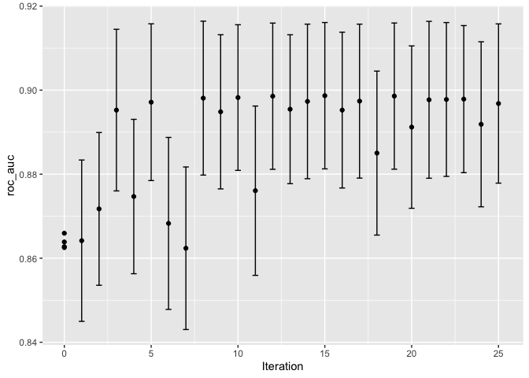

```r
autoplot(svm_bo, type = "performance")
```

Plot of parameter values over iterations

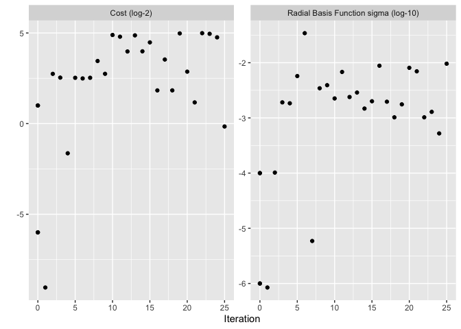

```r
autoplot(svm_bo, type="parameters")
```

While the best tuning parameter combination is on the boundary of the parameter space, Bayesian optimization will often choose new points on other sides of the boundary. While we can adjust the ratio of exploration and exploitation, the search tends to sample boundary points early on.

If the user interrupts the tune_bayes() computations, the function returns the current results (instead of resulting in an error).

### 14.3 simulated annealing

Simulated annealing is a general nonlinear search routine inspired by the process of which metal cools. It is a global search method that can effectively navigate many different types of search landscapes, including discontinuous functions. Unlike most gradient-based optimization routines, simulated annealing can reassess previous solutions.

#### 14.3.1 Simulated annealing search process

The process of using simulated annealing starts with an initial value and embarks on a controlled random walk through the parameter space. Each new candidate parameter value is a small perturbation of the previous value that keeps the new point within a local neighborhood.

The candidate point is resampled to obtain its corresponding performance value. If this achieves better results than the previous parameters, it is accepted as the new best and the process continues. If the results are worse than the previous value the search procedure may still use this parameter to define further steps. This depends on two factors. First, the likelihood of accepting a bad result decreases as performance becomes worse. In other words, a slighly worse result has a better chance of acceptance than one with a large drop in performance. The other factor is the number of search iterations. Simulated annealing wants to accept fewer suboptimal values as the search proceeds. From these two factors, the acceptance probability for a bad result can be formalized.

For a bad result, we determine the acceptance probability and compare it to a random uniform number. If the random number is greater than the probability value, the search discards the current parameters and the next iteration creates its candidate value in the neighborhood of the previous value. Otherwise, the next iteration forms the next set of parameters based on the current suboptimal values.

The acceptance probabilities of simulated annealing allow the search to proceed in the wrong direction, at least for the short term, with the potential to find a much better region of the paramter space in the long run.

The user can adjust the coefficients to find a probability profile that suits their needs. In finetune::control_sim_anneal(), the default for this cooling_coef argument is 0.002. Decreasing this coefficient will encourage the search to be more forgiving of poor results.

This process continues for a set amount of iterations but can halt if no globally best results occur within a pre-determined number of iterations. However, it can be very helpful to set a restart threshold. If there are a string of failures, this feature revisits the last globally best parameter settings and starts anew.

The main important detail is to define how to perturb the tuning parameters from iteration to iteration. There are a variety of methods in the literature for this. We follow the method generalized simulated annealing. For continuous tuning parameters, we define a small radius to specify the local “neighborhood”. The size of the radius controls how quickly the search explores the parameter space. For non-numeric parameters, we assign a probability for how often the parameter value changes.

#### 14.3.2 The tune_sim_anneal() function

To implement iterative search via simulated annealing, use the tune_sim_anneal() function. The syntax for this function is nearly identical to tune_bayes(). There are no options for acquisition functions or uncertainty sampling. The control_sim_anneal() function has some details that define the local neighborhood and the cooling schedule:

- no_improve: for simulated annealing, is an integer that will stop the search if no global best or improved results are discovered within no_improve iterations. Accepted suboptimal or discarded parameters count as “no improvement”
- restart: is the number of iterations with no new best results before starting from the previous best results.
- radius: is a numeric vector on (0,1) that defines the minimym and maximum radius of the local neighborhood around the intitial point.
- flip: is a probability value that defines the chances of altering the value of categorical or integer parameters.
- cooling_coef: is the c coefficient in exp(c x Di x i) that modulates how quickly the acceptance probability decreases over iterations. Larger values of cooling_coef decrease the probability of accpeting a suboptimal parameter setting.

For the cell segmentation data, the syntax is very consistent with the previously used functions:

```r
library(finetune)
ctrl_sa <- control_sim_anneal(verbose = TRUE, no_improve = 10L)

set.seed(1404)
svm_sa <-
  svm_wflow %>%
  tune_sim_anneal(
    resamples = cell_folds,
    metrics = roc_res,
    initial = svm_initial,
    param_info = svm_param,
    iter = 50,
    control = ctrl_sa
  )
```

```
## Optimizing roc_auc
```

```
## Initial best: 0.86594
```

[output not shown]

[output not shown]

[output not shown]

[output not shown]

[output not shown]

[output not shown]

[output not shown]

[output not shown]

[output not shown]

[output not shown]

[output not shown]

[output not shown]

[output not shown]

[output not shown]

[output not shown]

[output not shown]

[output not shown]

[output not shown]

[output not shown]

[output not shown]

[output not shown]

[output not shown]

[output not shown]

[output not shown]

[output not shown]

[output not shown]

[output not shown]

[output not shown]

[output not shown]

[output not shown]

[output not shown]

[output not shown]

[output not shown]

[output not shown]

[output not shown]

[output not shown]

[output not shown]

[output not shown]

[output not shown]

[output not shown]

[output not shown]

[output not shown]

[output not shown]

[output not shown]

[output not shown]

[output not shown]

[output not shown]

[output not shown]

[output not shown]

[output not shown]

[output not shown]

[output not shown]

[output not shown]

[output not shown]

[output not shown]

[output not shown]

[output not shown]

[output not shown]

[output not shown]

[output not shown]

```
## 1 ◯ accept suboptimal  roc_auc=0.86351 (+/-0.008642)
```

```
## i Fold01: preprocessor 1/1
```

```
## ✓ Fold01: preprocessor 1/1
```

```
## i Fold01: preprocessor 1/1, model 1/1
```

```
## ✓ Fold01: preprocessor 1/1, model 1/1
```

```
## i Fold01: preprocessor 1/1, model 1/1 (extracts)
```

```
## i Fold01: preprocessor 1/1, model 1/1 (predictions)
```

```
## i Fold02: preprocessor 1/1
```

```
## ✓ Fold02: preprocessor 1/1
```

```
## i Fold02: preprocessor 1/1, model 1/1
```

```
## ✓ Fold02: preprocessor 1/1, model 1/1
```

```
## i Fold02: preprocessor 1/1, model 1/1 (extracts)
```

```
## i Fold02: preprocessor 1/1, model 1/1 (predictions)
```

```
## i Fold03: preprocessor 1/1
```

```
## ✓ Fold03: preprocessor 1/1
```

```
## i Fold03: preprocessor 1/1, model 1/1
```

```
## ✓ Fold03: preprocessor 1/1, model 1/1
```

```
## i Fold03: preprocessor 1/1, model 1/1 (extracts)
```

```
## i Fold03: preprocessor 1/1, model 1/1 (predictions)
```

```
## i Fold04: preprocessor 1/1
```

```
## ✓ Fold04: preprocessor 1/1
```

```
## i Fold04: preprocessor 1/1, model 1/1
```

```
## ✓ Fold04: preprocessor 1/1, model 1/1
```

```
## i Fold04: preprocessor 1/1, model 1/1 (extracts)
```

```
## i Fold04: preprocessor 1/1, model 1/1 (predictions)
```

```
## i Fold05: preprocessor 1/1
```

```
## ✓ Fold05: preprocessor 1/1
```

```
## i Fold05: preprocessor 1/1, model 1/1
```

```
## ✓ Fold05: preprocessor 1/1, model 1/1
```

```
## i Fold05: preprocessor 1/1, model 1/1 (extracts)
```

```
## i Fold05: preprocessor 1/1, model 1/1 (predictions)
```

```
## i Fold06: preprocessor 1/1
```

```
## ✓ Fold06: preprocessor 1/1
```

```
## i Fold06: preprocessor 1/1, model 1/1
```

```
## ✓ Fold06: preprocessor 1/1, model 1/1
```

```
## i Fold06: preprocessor 1/1, model 1/1 (extracts)
```

```
## i Fold06: preprocessor 1/1, model 1/1 (predictions)
```

```
## i Fold07: preprocessor 1/1
```

```
## ✓ Fold07: preprocessor 1/1
```

```
## i Fold07: preprocessor 1/1, model 1/1
```

```
## ✓ Fold07: preprocessor 1/1, model 1/1
```

```
## i Fold07: preprocessor 1/1, model 1/1 (extracts)
```

```
## i Fold07: preprocessor 1/1, model 1/1 (predictions)
```

```
## i Fold08: preprocessor 1/1
```

```
## ✓ Fold08: preprocessor 1/1
```

```
## i Fold08: preprocessor 1/1, model 1/1
```

```
## ✓ Fold08: preprocessor 1/1, model 1/1
```

```
## i Fold08: preprocessor 1/1, model 1/1 (extracts)
```

```
## i Fold08: preprocessor 1/1, model 1/1 (predictions)
```

```
## i Fold09: preprocessor 1/1
```

```
## ✓ Fold09: preprocessor 1/1
```

```
## i Fold09: preprocessor 1/1, model 1/1
```

```
## ✓ Fold09: preprocessor 1/1, model 1/1
```

```
## i Fold09: preprocessor 1/1, model 1/1 (extracts)
```

```
## i Fold09: preprocessor 1/1, model 1/1 (predictions)
```

```
## i Fold10: preprocessor 1/1
```

```
## ✓ Fold10: preprocessor 1/1
```

```
## i Fold10: preprocessor 1/1, model 1/1
```

```
## ✓ Fold10: preprocessor 1/1, model 1/1
```

```
## i Fold10: preprocessor 1/1, model 1/1 (extracts)
```

```
## i Fold10: preprocessor 1/1, model 1/1 (predictions)
```

```
## 2 ♥ new best           roc_auc=0.87334 (+/-0.008402)
```

```
## i Fold01: preprocessor 1/1
```

```
## ✓ Fold01: preprocessor 1/1
```

```
## i Fold01: preprocessor 1/1, model 1/1
```

```
## ✓ Fold01: preprocessor 1/1, model 1/1
```

```
## i Fold01: preprocessor 1/1, model 1/1 (extracts)
```

```
## i Fold01: preprocessor 1/1, model 1/1 (predictions)
```

```
## i Fold02: preprocessor 1/1
```

```
## ✓ Fold02: preprocessor 1/1
```

```
## i Fold02: preprocessor 1/1, model 1/1
```

```
## ✓ Fold02: preprocessor 1/1, model 1/1
```

```
## i Fold02: preprocessor 1/1, model 1/1 (extracts)
```

```
## i Fold02: preprocessor 1/1, model 1/1 (predictions)
```

```
## i Fold03: preprocessor 1/1
```

```
## ✓ Fold03: preprocessor 1/1
```

```
## i Fold03: preprocessor 1/1, model 1/1
```

```
## ✓ Fold03: preprocessor 1/1, model 1/1
```

```
## i Fold03: preprocessor 1/1, model 1/1 (extracts)
```

```
## i Fold03: preprocessor 1/1, model 1/1 (predictions)
```

```
## i Fold04: preprocessor 1/1
```

```
## ✓ Fold04: preprocessor 1/1
```

```
## i Fold04: preprocessor 1/1, model 1/1
```

```
## ✓ Fold04: preprocessor 1/1, model 1/1
```

```
## i Fold04: preprocessor 1/1, model 1/1 (extracts)
```

```
## i Fold04: preprocessor 1/1, model 1/1 (predictions)
```

```
## i Fold05: preprocessor 1/1
```

```
## ✓ Fold05: preprocessor 1/1
```

```
## i Fold05: preprocessor 1/1, model 1/1
```

```
## ✓ Fold05: preprocessor 1/1, model 1/1
```

```
## i Fold05: preprocessor 1/1, model 1/1 (extracts)
```

```
## i Fold05: preprocessor 1/1, model 1/1 (predictions)
```

```
## i Fold06: preprocessor 1/1
```

```
## ✓ Fold06: preprocessor 1/1
```

```
## i Fold06: preprocessor 1/1, model 1/1
```

```
## ✓ Fold06: preprocessor 1/1, model 1/1
```

```
## i Fold06: preprocessor 1/1, model 1/1 (extracts)
```

```
## i Fold06: preprocessor 1/1, model 1/1 (predictions)
```

```
## i Fold07: preprocessor 1/1
```

```
## ✓ Fold07: preprocessor 1/1
```

```
## i Fold07: preprocessor 1/1, model 1/1
```

```
## ✓ Fold07: preprocessor 1/1, model 1/1
```

```
## i Fold07: preprocessor 1/1, model 1/1 (extracts)
```

```
## i Fold07: preprocessor 1/1, model 1/1 (predictions)
```

```
## i Fold08: preprocessor 1/1
```

```
## ✓ Fold08: preprocessor 1/1
```

```
## i Fold08: preprocessor 1/1, model 1/1
```

```
## ✓ Fold08: preprocessor 1/1, model 1/1
```

```
## i Fold08: preprocessor 1/1, model 1/1 (extracts)
```

```
## i Fold08: preprocessor 1/1, model 1/1 (predictions)
```

```
## i Fold09: preprocessor 1/1
```

```
## ✓ Fold09: preprocessor 1/1
```

```
## i Fold09: preprocessor 1/1, model 1/1
```

```
## ✓ Fold09: preprocessor 1/1, model 1/1
```

```
## i Fold09: preprocessor 1/1, model 1/1 (extracts)
```

```
## i Fold09: preprocessor 1/1, model 1/1 (predictions)
```

```
## i Fold10: preprocessor 1/1
```

```
## ✓ Fold10: preprocessor 1/1
```

```
## i Fold10: preprocessor 1/1, model 1/1
```

```
## ✓ Fold10: preprocessor 1/1, model 1/1
```

```
## i Fold10: preprocessor 1/1, model 1/1 (extracts)
```

```
## i Fold10: preprocessor 1/1, model 1/1 (predictions)
```

```
## 3 ◯ accept suboptimal  roc_auc=0.86724 (+/-0.00838)
```

```
## i Fold01: preprocessor 1/1
```

```
## ✓ Fold01: preprocessor 1/1
```

```
## i Fold01: preprocessor 1/1, model 1/1
```

```
## ✓ Fold01: preprocessor 1/1, model 1/1
```

```
## i Fold01: preprocessor 1/1, model 1/1 (extracts)
```

```
## i Fold01: preprocessor 1/1, model 1/1 (predictions)
```

```
## i Fold02: preprocessor 1/1
```

```
## ✓ Fold02: preprocessor 1/1
```

```
## i Fold02: preprocessor 1/1, model 1/1
```

```
## ✓ Fold02: preprocessor 1/1, model 1/1
```

```
## i Fold02: preprocessor 1/1, model 1/1 (extracts)
```

```
## i Fold02: preprocessor 1/1, model 1/1 (predictions)
```

```
## i Fold03: preprocessor 1/1
```

```
## ✓ Fold03: preprocessor 1/1
```

```
## i Fold03: preprocessor 1/1, model 1/1
```

```
## ✓ Fold03: preprocessor 1/1, model 1/1
```

```
## i Fold03: preprocessor 1/1, model 1/1 (extracts)
```

```
## i Fold03: preprocessor 1/1, model 1/1 (predictions)
```

```
## i Fold04: preprocessor 1/1
```

```
## ✓ Fold04: preprocessor 1/1
```

```
## i Fold04: preprocessor 1/1, model 1/1
```

```
## ✓ Fold04: preprocessor 1/1, model 1/1
```

```
## i Fold04: preprocessor 1/1, model 1/1 (extracts)
```

```
## i Fold04: preprocessor 1/1, model 1/1 (predictions)
```

```
## i Fold05: preprocessor 1/1
```

```
## ✓ Fold05: preprocessor 1/1
```

```
## i Fold05: preprocessor 1/1, model 1/1
```

```
## ✓ Fold05: preprocessor 1/1, model 1/1
```

```
## i Fold05: preprocessor 1/1, model 1/1 (extracts)
```

```
## i Fold05: preprocessor 1/1, model 1/1 (predictions)
```

```
## i Fold06: preprocessor 1/1
```

```
## ✓ Fold06: preprocessor 1/1
```

```
## i Fold06: preprocessor 1/1, model 1/1
```

```
## ✓ Fold06: preprocessor 1/1, model 1/1
```

```
## i Fold06: preprocessor 1/1, model 1/1 (extracts)
```

```
## i Fold06: preprocessor 1/1, model 1/1 (predictions)
```

```
## i Fold07: preprocessor 1/1
```

```
## ✓ Fold07: preprocessor 1/1
```

```
## i Fold07: preprocessor 1/1, model 1/1
```

```
## ✓ Fold07: preprocessor 1/1, model 1/1
```

```
## i Fold07: preprocessor 1/1, model 1/1 (extracts)
```

```
## i Fold07: preprocessor 1/1, model 1/1 (predictions)
```

```
## i Fold08: preprocessor 1/1
```

```
## ✓ Fold08: preprocessor 1/1
```

```
## i Fold08: preprocessor 1/1, model 1/1
```

```
## ✓ Fold08: preprocessor 1/1, model 1/1
```

```
## i Fold08: preprocessor 1/1, model 1/1 (extracts)
```

```
## i Fold08: preprocessor 1/1, model 1/1 (predictions)
```

```
## i Fold09: preprocessor 1/1
```

```
## ✓ Fold09: preprocessor 1/1
```

```
## i Fold09: preprocessor 1/1, model 1/1
```

```
## ✓ Fold09: preprocessor 1/1, model 1/1
```

```
## i Fold09: preprocessor 1/1, model 1/1 (extracts)
```

```
## i Fold09: preprocessor 1/1, model 1/1 (predictions)
```

```
## i Fold10: preprocessor 1/1
```

```
## ✓ Fold10: preprocessor 1/1
```

```
## i Fold10: preprocessor 1/1, model 1/1
```

```
## ✓ Fold10: preprocessor 1/1, model 1/1
```

```
## i Fold10: preprocessor 1/1, model 1/1 (extracts)
```

```
## i Fold10: preprocessor 1/1, model 1/1 (predictions)
```

```
## 4 + better suboptimal  roc_auc=0.87042 (+/-0.008147)
```

```
## i Fold01: preprocessor 1/1
```

```
## ✓ Fold01: preprocessor 1/1
```

```
## i Fold01: preprocessor 1/1, model 1/1
```

```
## ✓ Fold01: preprocessor 1/1, model 1/1
```

```
## i Fold01: preprocessor 1/1, model 1/1 (extracts)
```

```
## i Fold01: preprocessor 1/1, model 1/1 (predictions)
```

```
## i Fold02: preprocessor 1/1
```

```
## ✓ Fold02: preprocessor 1/1
```

```
## i Fold02: preprocessor 1/1, model 1/1
```

```
## ✓ Fold02: preprocessor 1/1, model 1/1
```

```
## i Fold02: preprocessor 1/1, model 1/1 (extracts)
```

```
## i Fold02: preprocessor 1/1, model 1/1 (predictions)
```

```
## i Fold03: preprocessor 1/1
```

```
## ✓ Fold03: preprocessor 1/1
```

```
## i Fold03: preprocessor 1/1, model 1/1
```

```
## ✓ Fold03: preprocessor 1/1, model 1/1
```

```
## i Fold03: preprocessor 1/1, model 1/1 (extracts)
```

```
## i Fold03: preprocessor 1/1, model 1/1 (predictions)
```

```
## i Fold04: preprocessor 1/1
```

```
## ✓ Fold04: preprocessor 1/1
```

```
## i Fold04: preprocessor 1/1, model 1/1
```

```
## ✓ Fold04: preprocessor 1/1, model 1/1
```

```
## i Fold04: preprocessor 1/1, model 1/1 (extracts)
```

```
## i Fold04: preprocessor 1/1, model 1/1 (predictions)
```

```
## i Fold05: preprocessor 1/1
```

```
## ✓ Fold05: preprocessor 1/1
```

```
## i Fold05: preprocessor 1/1, model 1/1
```

```
## ✓ Fold05: preprocessor 1/1, model 1/1
```

```
## i Fold05: preprocessor 1/1, model 1/1 (extracts)
```

```
## i Fold05: preprocessor 1/1, model 1/1 (predictions)
```

```
## i Fold06: preprocessor 1/1
```

```
## ✓ Fold06: preprocessor 1/1
```

```
## i Fold06: preprocessor 1/1, model 1/1
```

```
## ✓ Fold06: preprocessor 1/1, model 1/1
```

```
## i Fold06: preprocessor 1/1, model 1/1 (extracts)
```

```
## i Fold06: preprocessor 1/1, model 1/1 (predictions)
```

```
## i Fold07: preprocessor 1/1
```

```
## ✓ Fold07: preprocessor 1/1
```

```
## i Fold07: preprocessor 1/1, model 1/1
```

```
## ✓ Fold07: preprocessor 1/1, model 1/1
```

```
## i Fold07: preprocessor 1/1, model 1/1 (extracts)
```

```
## i Fold07: preprocessor 1/1, model 1/1 (predictions)
```

```
## i Fold08: preprocessor 1/1
```

```
## ✓ Fold08: preprocessor 1/1
```

```
## i Fold08: preprocessor 1/1, model 1/1
```

```
## ✓ Fold08: preprocessor 1/1, model 1/1
```

```
## i Fold08: preprocessor 1/1, model 1/1 (extracts)
```

```
## i Fold08: preprocessor 1/1, model 1/1 (predictions)
```

```
## i Fold09: preprocessor 1/1
```

```
## ✓ Fold09: preprocessor 1/1
```

```
## i Fold09: preprocessor 1/1, model 1/1
```

```
## ✓ Fold09: preprocessor 1/1, model 1/1
```

```
## i Fold09: preprocessor 1/1, model 1/1 (extracts)
```

```
## i Fold09: preprocessor 1/1, model 1/1 (predictions)
```

```
## i Fold10: preprocessor 1/1
```

```
## ✓ Fold10: preprocessor 1/1
```

```
## i Fold10: preprocessor 1/1, model 1/1
```

```
## ✓ Fold10: preprocessor 1/1, model 1/1
```

```
## i Fold10: preprocessor 1/1, model 1/1 (extracts)
```

```
## i Fold10: preprocessor 1/1, model 1/1 (predictions)
```

```
## 5 ♥ new best           roc_auc=0.87444 (+/-0.008459)
```

```
## i Fold01: preprocessor 1/1
```

```
## ✓ Fold01: preprocessor 1/1
```

```
## i Fold01: preprocessor 1/1, model 1/1
```

```
## ✓ Fold01: preprocessor 1/1, model 1/1
```

```
## i Fold01: preprocessor 1/1, model 1/1 (extracts)
```

```
## i Fold01: preprocessor 1/1, model 1/1 (predictions)
```

```
## i Fold02: preprocessor 1/1
```

```
## ✓ Fold02: preprocessor 1/1
```

```
## i Fold02: preprocessor 1/1, model 1/1
```

```
## ✓ Fold02: preprocessor 1/1, model 1/1
```

```
## i Fold02: preprocessor 1/1, model 1/1 (extracts)
```

```
## i Fold02: preprocessor 1/1, model 1/1 (predictions)
```

```
## i Fold03: preprocessor 1/1
```

```
## ✓ Fold03: preprocessor 1/1
```

```
## i Fold03: preprocessor 1/1, model 1/1
```

```
## ✓ Fold03: preprocessor 1/1, model 1/1
```

```
## i Fold03: preprocessor 1/1, model 1/1 (extracts)
```

```
## i Fold03: preprocessor 1/1, model 1/1 (predictions)
```

```
## i Fold04: preprocessor 1/1
```

```
## ✓ Fold04: preprocessor 1/1
```

```
## i Fold04: preprocessor 1/1, model 1/1
```

```
## ✓ Fold04: preprocessor 1/1, model 1/1
```

```
## i Fold04: preprocessor 1/1, model 1/1 (extracts)
```

```
## i Fold04: preprocessor 1/1, model 1/1 (predictions)
```

```
## i Fold05: preprocessor 1/1
```

```
## ✓ Fold05: preprocessor 1/1
```

```
## i Fold05: preprocessor 1/1, model 1/1
```

```
## ✓ Fold05: preprocessor 1/1, model 1/1
```

```
## i Fold05: preprocessor 1/1, model 1/1 (extracts)
```

```
## i Fold05: preprocessor 1/1, model 1/1 (predictions)
```

```
## i Fold06: preprocessor 1/1
```

```
## ✓ Fold06: preprocessor 1/1
```

```
## i Fold06: preprocessor 1/1, model 1/1
```

```
## ✓ Fold06: preprocessor 1/1, model 1/1
```

```
## i Fold06: preprocessor 1/1, model 1/1 (extracts)
```

```
## i Fold06: preprocessor 1/1, model 1/1 (predictions)
```

```
## i Fold07: preprocessor 1/1
```

```
## ✓ Fold07: preprocessor 1/1
```

```
## i Fold07: preprocessor 1/1, model 1/1
```

```
## ✓ Fold07: preprocessor 1/1, model 1/1
```

```
## i Fold07: preprocessor 1/1, model 1/1 (extracts)
```

```
## i Fold07: preprocessor 1/1, model 1/1 (predictions)
```

```
## i Fold08: preprocessor 1/1
```

```
## ✓ Fold08: preprocessor 1/1
```

```
## i Fold08: preprocessor 1/1, model 1/1
```

```
## ✓ Fold08: preprocessor 1/1, model 1/1
```

```
## i Fold08: preprocessor 1/1, model 1/1 (extracts)
```

```
## i Fold08: preprocessor 1/1, model 1/1 (predictions)
```

```
## i Fold09: preprocessor 1/1
```

```
## ✓ Fold09: preprocessor 1/1
```

```
## i Fold09: preprocessor 1/1, model 1/1
```

```
## ✓ Fold09: preprocessor 1/1, model 1/1
```

```
## i Fold09: preprocessor 1/1, model 1/1 (extracts)
```

```
## i Fold09: preprocessor 1/1, model 1/1 (predictions)
```

```
## i Fold10: preprocessor 1/1
```

```
## ✓ Fold10: preprocessor 1/1
```

```
## i Fold10: preprocessor 1/1, model 1/1
```

```
## ✓ Fold10: preprocessor 1/1, model 1/1
```

```
## i Fold10: preprocessor 1/1, model 1/1 (extracts)
```

```
## i Fold10: preprocessor 1/1, model 1/1 (predictions)
```

```
## 6 ◯ accept suboptimal  roc_auc=0.86966 (+/-0.00811)
```

```
## i Fold01: preprocessor 1/1
```

```
## ✓ Fold01: preprocessor 1/1
```

```
## i Fold01: preprocessor 1/1, model 1/1
```

```
## ✓ Fold01: preprocessor 1/1, model 1/1
```

```
## i Fold01: preprocessor 1/1, model 1/1 (extracts)
```

```
## i Fold01: preprocessor 1/1, model 1/1 (predictions)
```

```
## i Fold02: preprocessor 1/1
```

```
## ✓ Fold02: preprocessor 1/1
```

```
## i Fold02: preprocessor 1/1, model 1/1
```

```
## ✓ Fold02: preprocessor 1/1, model 1/1
```

```
## i Fold02: preprocessor 1/1, model 1/1 (extracts)
```

```
## i Fold02: preprocessor 1/1, model 1/1 (predictions)
```

```
## i Fold03: preprocessor 1/1
```

```
## ✓ Fold03: preprocessor 1/1
```

```
## i Fold03: preprocessor 1/1, model 1/1
```

```
## ✓ Fold03: preprocessor 1/1, model 1/1
```

```
## i Fold03: preprocessor 1/1, model 1/1 (extracts)
```

```
## i Fold03: preprocessor 1/1, model 1/1 (predictions)
```

```
## i Fold04: preprocessor 1/1
```

```
## ✓ Fold04: preprocessor 1/1
```

```
## i Fold04: preprocessor 1/1, model 1/1
```

```
## ✓ Fold04: preprocessor 1/1, model 1/1
```

```
## i Fold04: preprocessor 1/1, model 1/1 (extracts)
```

```
## i Fold04: preprocessor 1/1, model 1/1 (predictions)
```

```
## i Fold05: preprocessor 1/1
```

```
## ✓ Fold05: preprocessor 1/1
```

```
## i Fold05: preprocessor 1/1, model 1/1
```

```
## ✓ Fold05: preprocessor 1/1, model 1/1
```

```
## i Fold05: preprocessor 1/1, model 1/1 (extracts)
```

```
## i Fold05: preprocessor 1/1, model 1/1 (predictions)
```

```
## i Fold06: preprocessor 1/1
```

```
## ✓ Fold06: preprocessor 1/1
```

```
## i Fold06: preprocessor 1/1, model 1/1
```

```
## ✓ Fold06: preprocessor 1/1, model 1/1
```

```
## i Fold06: preprocessor 1/1, model 1/1 (extracts)
```

```
## i Fold06: preprocessor 1/1, model 1/1 (predictions)
```

```
## i Fold07: preprocessor 1/1
```

```
## ✓ Fold07: preprocessor 1/1
```

```
## i Fold07: preprocessor 1/1, model 1/1
```

```
## ✓ Fold07: preprocessor 1/1, model 1/1
```

```
## i Fold07: preprocessor 1/1, model 1/1 (extracts)
```

```
## i Fold07: preprocessor 1/1, model 1/1 (predictions)
```

```
## i Fold08: preprocessor 1/1
```

```
## ✓ Fold08: preprocessor 1/1
```

```
## i Fold08: preprocessor 1/1, model 1/1
```

```
## ✓ Fold08: preprocessor 1/1, model 1/1
```

```
## i Fold08: preprocessor 1/1, model 1/1 (extracts)
```

```
## i Fold08: preprocessor 1/1, model 1/1 (predictions)
```

```
## i Fold09: preprocessor 1/1
```

```
## ✓ Fold09: preprocessor 1/1
```

```
## i Fold09: preprocessor 1/1, model 1/1
```

```
## ✓ Fold09: preprocessor 1/1, model 1/1
```

```
## i Fold09: preprocessor 1/1, model 1/1 (extracts)
```

```
## i Fold09: preprocessor 1/1, model 1/1 (predictions)
```

```
## i Fold10: preprocessor 1/1
```

```
## ✓ Fold10: preprocessor 1/1
```

```
## i Fold10: preprocessor 1/1, model 1/1
```

```
## ✓ Fold10: preprocessor 1/1, model 1/1
```

```
## i Fold10: preprocessor 1/1, model 1/1 (extracts)
```

```
## i Fold10: preprocessor 1/1, model 1/1 (predictions)
```

```
## 7 ◯ accept suboptimal  roc_auc=0.86589 (+/-0.008448)
```

```
## i Fold01: preprocessor 1/1
```

```
## ✓ Fold01: preprocessor 1/1
```

```
## i Fold01: preprocessor 1/1, model 1/1
```

```
## ✓ Fold01: preprocessor 1/1, model 1/1
```

```
## i Fold01: preprocessor 1/1, model 1/1 (extracts)
```

```
## i Fold01: preprocessor 1/1, model 1/1 (predictions)
```

```
## i Fold02: preprocessor 1/1
```

```
## ✓ Fold02: preprocessor 1/1
```

```
## i Fold02: preprocessor 1/1, model 1/1
```

```
## ✓ Fold02: preprocessor 1/1, model 1/1
```

```
## i Fold02: preprocessor 1/1, model 1/1 (extracts)
```

```
## i Fold02: preprocessor 1/1, model 1/1 (predictions)
```

```
## i Fold03: preprocessor 1/1
```

```
## ✓ Fold03: preprocessor 1/1
```

```
## i Fold03: preprocessor 1/1, model 1/1
```

```
## ✓ Fold03: preprocessor 1/1, model 1/1
```

```
## i Fold03: preprocessor 1/1, model 1/1 (extracts)
```

```
## i Fold03: preprocessor 1/1, model 1/1 (predictions)
```

```
## i Fold04: preprocessor 1/1
```

```
## ✓ Fold04: preprocessor 1/1
```

```
## i Fold04: preprocessor 1/1, model 1/1
```

```
## ✓ Fold04: preprocessor 1/1, model 1/1
```

```
## i Fold04: preprocessor 1/1, model 1/1 (extracts)
```

```
## i Fold04: preprocessor 1/1, model 1/1 (predictions)
```

```
## i Fold05: preprocessor 1/1
```

```
## ✓ Fold05: preprocessor 1/1
```

```
## i Fold05: preprocessor 1/1, model 1/1
```

```
## ✓ Fold05: preprocessor 1/1, model 1/1
```

```
## i Fold05: preprocessor 1/1, model 1/1 (extracts)
```

```
## i Fold05: preprocessor 1/1, model 1/1 (predictions)
```

```
## i Fold06: preprocessor 1/1
```

```
## ✓ Fold06: preprocessor 1/1
```

```
## i Fold06: preprocessor 1/1, model 1/1
```

```
## ✓ Fold06: preprocessor 1/1, model 1/1
```

```
## i Fold06: preprocessor 1/1, model 1/1 (extracts)
```

```
## i Fold06: preprocessor 1/1, model 1/1 (predictions)
```

```
## i Fold07: preprocessor 1/1
```

```
## ✓ Fold07: preprocessor 1/1
```

```
## i Fold07: preprocessor 1/1, model 1/1
```

```
## ✓ Fold07: preprocessor 1/1, model 1/1
```

```
## i Fold07: preprocessor 1/1, model 1/1 (extracts)
```

```
## i Fold07: preprocessor 1/1, model 1/1 (predictions)
```

```
## i Fold08: preprocessor 1/1
```

```
## ✓ Fold08: preprocessor 1/1
```

```
## i Fold08: preprocessor 1/1, model 1/1
```

```
## ✓ Fold08: preprocessor 1/1, model 1/1
```

```
## i Fold08: preprocessor 1/1, model 1/1 (extracts)
```

```
## i Fold08: preprocessor 1/1, model 1/1 (predictions)
```

```
## i Fold09: preprocessor 1/1
```

```
## ✓ Fold09: preprocessor 1/1
```

```
## i Fold09: preprocessor 1/1, model 1/1
```

```
## ✓ Fold09: preprocessor 1/1, model 1/1
```

```
## i Fold09: preprocessor 1/1, model 1/1 (extracts)
```

```
## i Fold09: preprocessor 1/1, model 1/1 (predictions)
```

```
## i Fold10: preprocessor 1/1
```

```
## ✓ Fold10: preprocessor 1/1
```

```
## i Fold10: preprocessor 1/1, model 1/1
```

```
## ✓ Fold10: preprocessor 1/1, model 1/1
```

```
## i Fold10: preprocessor 1/1, model 1/1 (extracts)
```

```
## i Fold10: preprocessor 1/1, model 1/1 (predictions)
```

```
## 8 ◯ accept suboptimal  roc_auc=0.86233 (+/-0.008657)
```

```
## i Fold01: preprocessor 1/1
```

```
## ✓ Fold01: preprocessor 1/1
```

```
## i Fold01: preprocessor 1/1, model 1/1
```

```
## ✓ Fold01: preprocessor 1/1, model 1/1
```

```
## i Fold01: preprocessor 1/1, model 1/1 (extracts)
```

```
## i Fold01: preprocessor 1/1, model 1/1 (predictions)
```

```
## i Fold02: preprocessor 1/1
```

```
## ✓ Fold02: preprocessor 1/1
```

```
## i Fold02: preprocessor 1/1, model 1/1
```

```
## ✓ Fold02: preprocessor 1/1, model 1/1
```

```
## i Fold02: preprocessor 1/1, model 1/1 (extracts)
```

```
## i Fold02: preprocessor 1/1, model 1/1 (predictions)
```

```
## i Fold03: preprocessor 1/1
```

```
## ✓ Fold03: preprocessor 1/1
```

```
## i Fold03: preprocessor 1/1, model 1/1
```

```
## ✓ Fold03: preprocessor 1/1, model 1/1
```

```
## i Fold03: preprocessor 1/1, model 1/1 (extracts)
```

```
## i Fold03: preprocessor 1/1, model 1/1 (predictions)
```

```
## i Fold04: preprocessor 1/1
```

```
## ✓ Fold04: preprocessor 1/1
```

```
## i Fold04: preprocessor 1/1, model 1/1
```

```
## ✓ Fold04: preprocessor 1/1, model 1/1
```

```
## i Fold04: preprocessor 1/1, model 1/1 (extracts)
```

```
## i Fold04: preprocessor 1/1, model 1/1 (predictions)
```

```
## i Fold05: preprocessor 1/1
```

```
## ✓ Fold05: preprocessor 1/1
```

```
## i Fold05: preprocessor 1/1, model 1/1
```

```
## ✓ Fold05: preprocessor 1/1, model 1/1
```

```
## i Fold05: preprocessor 1/1, model 1/1 (extracts)
```

```
## i Fold05: preprocessor 1/1, model 1/1 (predictions)
```

```
## i Fold06: preprocessor 1/1
```

```
## ✓ Fold06: preprocessor 1/1
```

```
## i Fold06: preprocessor 1/1, model 1/1
```

```
## ✓ Fold06: preprocessor 1/1, model 1/1
```

```
## i Fold06: preprocessor 1/1, model 1/1 (extracts)
```

```
## i Fold06: preprocessor 1/1, model 1/1 (predictions)
```

```
## i Fold07: preprocessor 1/1
```

```
## ✓ Fold07: preprocessor 1/1
```

```
## i Fold07: preprocessor 1/1, model 1/1
```

```
## ✓ Fold07: preprocessor 1/1, model 1/1
```

```
## i Fold07: preprocessor 1/1, model 1/1 (extracts)
```

```
## i Fold07: preprocessor 1/1, model 1/1 (predictions)
```

```
## i Fold08: preprocessor 1/1
```

```
## ✓ Fold08: preprocessor 1/1
```

```
## i Fold08: preprocessor 1/1, model 1/1
```

```
## ✓ Fold08: preprocessor 1/1, model 1/1
```

```
## i Fold08: preprocessor 1/1, model 1/1 (extracts)
```

```
## i Fold08: preprocessor 1/1, model 1/1 (predictions)
```

```
## i Fold09: preprocessor 1/1
```

```
## ✓ Fold09: preprocessor 1/1
```

```
## i Fold09: preprocessor 1/1, model 1/1
```

```
## ✓ Fold09: preprocessor 1/1, model 1/1
```

```
## i Fold09: preprocessor 1/1, model 1/1 (extracts)
```

```
## i Fold09: preprocessor 1/1, model 1/1 (predictions)
```

```
## i Fold10: preprocessor 1/1
```

```
## ✓ Fold10: preprocessor 1/1
```

```
## i Fold10: preprocessor 1/1, model 1/1
```

```
## ✓ Fold10: preprocessor 1/1, model 1/1
```

```
## i Fold10: preprocessor 1/1, model 1/1 (extracts)
```

```
## i Fold10: preprocessor 1/1, model 1/1 (predictions)
```

```
## 9 ◯ accept suboptimal  roc_auc=0.8623 (+/-0.008648)
```

```
## i Fold01: preprocessor 1/1
```

```
## ✓ Fold01: preprocessor 1/1
```

```
## i Fold01: preprocessor 1/1, model 1/1
```

```
## ✓ Fold01: preprocessor 1/1, model 1/1
```

```
## i Fold01: preprocessor 1/1, model 1/1 (extracts)
```

```
## i Fold01: preprocessor 1/1, model 1/1 (predictions)
```

```
## i Fold02: preprocessor 1/1
```

```
## ✓ Fold02: preprocessor 1/1
```

```
## i Fold02: preprocessor 1/1, model 1/1
```

```
## ✓ Fold02: preprocessor 1/1, model 1/1
```

```
## i Fold02: preprocessor 1/1, model 1/1 (extracts)
```

```
## i Fold02: preprocessor 1/1, model 1/1 (predictions)
```

```
## i Fold03: preprocessor 1/1
```

```
## ✓ Fold03: preprocessor 1/1
```

```
## i Fold03: preprocessor 1/1, model 1/1
```

```
## ✓ Fold03: preprocessor 1/1, model 1/1
```

```
## i Fold03: preprocessor 1/1, model 1/1 (extracts)
```

```
## i Fold03: preprocessor 1/1, model 1/1 (predictions)
```

```
## i Fold04: preprocessor 1/1
```

```
## ✓ Fold04: preprocessor 1/1
```

```
## i Fold04: preprocessor 1/1, model 1/1
```

```
## ✓ Fold04: preprocessor 1/1, model 1/1
```

```
## i Fold04: preprocessor 1/1, model 1/1 (extracts)
```

```
## i Fold04: preprocessor 1/1, model 1/1 (predictions)
```

```
## i Fold05: preprocessor 1/1
```

```
## ✓ Fold05: preprocessor 1/1
```

```
## i Fold05: preprocessor 1/1, model 1/1
```

```
## ✓ Fold05: preprocessor 1/1, model 1/1
```

```
## i Fold05: preprocessor 1/1, model 1/1 (extracts)
```

```
## i Fold05: preprocessor 1/1, model 1/1 (predictions)
```

```
## i Fold06: preprocessor 1/1
```

```
## ✓ Fold06: preprocessor 1/1
```

```
## i Fold06: preprocessor 1/1, model 1/1
```

```
## ✓ Fold06: preprocessor 1/1, model 1/1
```

```
## i Fold06: preprocessor 1/1, model 1/1 (extracts)
```

```
## i Fold06: preprocessor 1/1, model 1/1 (predictions)
```

```
## i Fold07: preprocessor 1/1
```

```
## ✓ Fold07: preprocessor 1/1
```

```
## i Fold07: preprocessor 1/1, model 1/1
```

```
## ✓ Fold07: preprocessor 1/1, model 1/1
```

```
## i Fold07: preprocessor 1/1, model 1/1 (extracts)
```

```
## i Fold07: preprocessor 1/1, model 1/1 (predictions)
```

```
## i Fold08: preprocessor 1/1
```

```
## ✓ Fold08: preprocessor 1/1
```

```
## i Fold08: preprocessor 1/1, model 1/1
```

```
## ✓ Fold08: preprocessor 1/1, model 1/1
```

```
## i Fold08: preprocessor 1/1, model 1/1 (extracts)
```

```
## i Fold08: preprocessor 1/1, model 1/1 (predictions)
```

```
## i Fold09: preprocessor 1/1
```

```
## ✓ Fold09: preprocessor 1/1
```

```
## i Fold09: preprocessor 1/1, model 1/1
```

```
## ✓ Fold09: preprocessor 1/1, model 1/1
```

```
## i Fold09: preprocessor 1/1, model 1/1 (extracts)
```

```
## i Fold09: preprocessor 1/1, model 1/1 (predictions)
```

```
## i Fold10: preprocessor 1/1
```

```
## ✓ Fold10: preprocessor 1/1
```

```
## i Fold10: preprocessor 1/1, model 1/1
```

```
## ✓ Fold10: preprocessor 1/1, model 1/1
```

```
## i Fold10: preprocessor 1/1, model 1/1 (extracts)
```

```
## i Fold10: preprocessor 1/1, model 1/1 (predictions)
```

```
## 10 + better suboptimal  roc_auc=0.86232 (+/-0.008658)
```

```
## i Fold01: preprocessor 1/1
```

```
## ✓ Fold01: preprocessor 1/1
```

```
## i Fold01: preprocessor 1/1, model 1/1
```

```
## ✓ Fold01: preprocessor 1/1, model 1/1
```

```
## i Fold01: preprocessor 1/1, model 1/1 (extracts)
```

```
## i Fold01: preprocessor 1/1, model 1/1 (predictions)
```

```
## i Fold02: preprocessor 1/1
```

```
## ✓ Fold02: preprocessor 1/1
```

```
## i Fold02: preprocessor 1/1, model 1/1
```

```
## ✓ Fold02: preprocessor 1/1, model 1/1
```

```
## i Fold02: preprocessor 1/1, model 1/1 (extracts)
```

```
## i Fold02: preprocessor 1/1, model 1/1 (predictions)
```

```
## i Fold03: preprocessor 1/1
```

```
## ✓ Fold03: preprocessor 1/1
```

```
## i Fold03: preprocessor 1/1, model 1/1
```

```
## ✓ Fold03: preprocessor 1/1, model 1/1
```

```
## i Fold03: preprocessor 1/1, model 1/1 (extracts)
```

```
## i Fold03: preprocessor 1/1, model 1/1 (predictions)
```

```
## i Fold04: preprocessor 1/1
```

```
## ✓ Fold04: preprocessor 1/1
```

```
## i Fold04: preprocessor 1/1, model 1/1
```

```
## ✓ Fold04: preprocessor 1/1, model 1/1
```

```
## i Fold04: preprocessor 1/1, model 1/1 (extracts)
```

```
## i Fold04: preprocessor 1/1, model 1/1 (predictions)
```

```
## i Fold05: preprocessor 1/1
```

```
## ✓ Fold05: preprocessor 1/1
```

```
## i Fold05: preprocessor 1/1, model 1/1
```

```
## ✓ Fold05: preprocessor 1/1, model 1/1
```

```
## i Fold05: preprocessor 1/1, model 1/1 (extracts)
```

```
## i Fold05: preprocessor 1/1, model 1/1 (predictions)
```

```
## i Fold06: preprocessor 1/1
```

```
## ✓ Fold06: preprocessor 1/1
```

```
## i Fold06: preprocessor 1/1, model 1/1
```

```
## ✓ Fold06: preprocessor 1/1, model 1/1
```

```
## i Fold06: preprocessor 1/1, model 1/1 (extracts)
```

```
## i Fold06: preprocessor 1/1, model 1/1 (predictions)
```

```
## i Fold07: preprocessor 1/1
```

```
## ✓ Fold07: preprocessor 1/1
```

```
## i Fold07: preprocessor 1/1, model 1/1
```

```
## ✓ Fold07: preprocessor 1/1, model 1/1
```

```
## i Fold07: preprocessor 1/1, model 1/1 (extracts)
```

```
## i Fold07: preprocessor 1/1, model 1/1 (predictions)
```

```
## i Fold08: preprocessor 1/1
```

```
## ✓ Fold08: preprocessor 1/1
```

```
## i Fold08: preprocessor 1/1, model 1/1
```

```
## ✓ Fold08: preprocessor 1/1, model 1/1
```

```
## i Fold08: preprocessor 1/1, model 1/1 (extracts)
```

```
## i Fold08: preprocessor 1/1, model 1/1 (predictions)
```

```
## i Fold09: preprocessor 1/1
```

```
## ✓ Fold09: preprocessor 1/1
```

```
## i Fold09: preprocessor 1/1, model 1/1
```

```
## ✓ Fold09: preprocessor 1/1, model 1/1
```

```
## i Fold09: preprocessor 1/1, model 1/1 (extracts)
```

```
## i Fold09: preprocessor 1/1, model 1/1 (predictions)
```

```
## i Fold10: preprocessor 1/1
```

```
## ✓ Fold10: preprocessor 1/1
```

```
## i Fold10: preprocessor 1/1, model 1/1
```

```
## ✓ Fold10: preprocessor 1/1, model 1/1
```

```
## i Fold10: preprocessor 1/1, model 1/1 (extracts)
```

```
## i Fold10: preprocessor 1/1, model 1/1 (predictions)
```

```
## 11 + better suboptimal  roc_auc=0.86238 (+/-0.008671)
```

```
## i Fold01: preprocessor 1/1
```

```
## ✓ Fold01: preprocessor 1/1
```

```
## i Fold01: preprocessor 1/1, model 1/1
```

```
## ✓ Fold01: preprocessor 1/1, model 1/1
```

```
## i Fold01: preprocessor 1/1, model 1/1 (extracts)
```

```
## i Fold01: preprocessor 1/1, model 1/1 (predictions)
```

```
## i Fold02: preprocessor 1/1
```

```
## ✓ Fold02: preprocessor 1/1
```

```
## i Fold02: preprocessor 1/1, model 1/1
```

```
## ✓ Fold02: preprocessor 1/1, model 1/1
```

```
## i Fold02: preprocessor 1/1, model 1/1 (extracts)
```

```
## i Fold02: preprocessor 1/1, model 1/1 (predictions)
```

```
## i Fold03: preprocessor 1/1
```

```
## ✓ Fold03: preprocessor 1/1
```

```
## i Fold03: preprocessor 1/1, model 1/1
```

```
## ✓ Fold03: preprocessor 1/1, model 1/1
```

```
## i Fold03: preprocessor 1/1, model 1/1 (extracts)
```

```
## i Fold03: preprocessor 1/1, model 1/1 (predictions)
```

```
## i Fold04: preprocessor 1/1
```

```
## ✓ Fold04: preprocessor 1/1
```

```
## i Fold04: preprocessor 1/1, model 1/1
```

```
## ✓ Fold04: preprocessor 1/1, model 1/1
```

```
## i Fold04: preprocessor 1/1, model 1/1 (extracts)
```

```
## i Fold04: preprocessor 1/1, model 1/1 (predictions)
```

```
## i Fold05: preprocessor 1/1
```

```
## ✓ Fold05: preprocessor 1/1
```

```
## i Fold05: preprocessor 1/1, model 1/1
```

```
## ✓ Fold05: preprocessor 1/1, model 1/1
```

```
## i Fold05: preprocessor 1/1, model 1/1 (extracts)
```

```
## i Fold05: preprocessor 1/1, model 1/1 (predictions)
```

```
## i Fold06: preprocessor 1/1
```

```
## ✓ Fold06: preprocessor 1/1
```

```
## i Fold06: preprocessor 1/1, model 1/1
```

```
## ✓ Fold06: preprocessor 1/1, model 1/1
```

```
## i Fold06: preprocessor 1/1, model 1/1 (extracts)
```

```
## i Fold06: preprocessor 1/1, model 1/1 (predictions)
```

```
## i Fold07: preprocessor 1/1
```

```
## ✓ Fold07: preprocessor 1/1
```

```
## i Fold07: preprocessor 1/1, model 1/1
```

```
## ✓ Fold07: preprocessor 1/1, model 1/1
```

```
## i Fold07: preprocessor 1/1, model 1/1 (extracts)
```

```
## i Fold07: preprocessor 1/1, model 1/1 (predictions)
```

```
## i Fold08: preprocessor 1/1
```

```
## ✓ Fold08: preprocessor 1/1
```

```
## i Fold08: preprocessor 1/1, model 1/1
```

```
## ✓ Fold08: preprocessor 1/1, model 1/1
```

```
## i Fold08: preprocessor 1/1, model 1/1 (extracts)
```

```
## i Fold08: preprocessor 1/1, model 1/1 (predictions)
```

```
## i Fold09: preprocessor 1/1
```

```
## ✓ Fold09: preprocessor 1/1
```

```
## i Fold09: preprocessor 1/1, model 1/1
```

```
## ✓ Fold09: preprocessor 1/1, model 1/1
```

```
## i Fold09: preprocessor 1/1, model 1/1 (extracts)
```

```
## i Fold09: preprocessor 1/1, model 1/1 (predictions)
```

```
## i Fold10: preprocessor 1/1
```

```
## ✓ Fold10: preprocessor 1/1
```

```
## i Fold10: preprocessor 1/1, model 1/1
```

```
## ✓ Fold10: preprocessor 1/1, model 1/1
```

```
## i Fold10: preprocessor 1/1, model 1/1 (extracts)
```

```
## i Fold10: preprocessor 1/1, model 1/1 (predictions)
```

```
## 12 + better suboptimal  roc_auc=0.86246 (+/-0.008646)
```

```
## i Fold01: preprocessor 1/1
```

```
## ✓ Fold01: preprocessor 1/1
```

```
## i Fold01: preprocessor 1/1, model 1/1
```

```
## ✓ Fold01: preprocessor 1/1, model 1/1
```

```
## i Fold01: preprocessor 1/1, model 1/1 (extracts)
```

```
## i Fold01: preprocessor 1/1, model 1/1 (predictions)
```

```
## i Fold02: preprocessor 1/1
```

```
## ✓ Fold02: preprocessor 1/1
```

```
## i Fold02: preprocessor 1/1, model 1/1
```

```
## ✓ Fold02: preprocessor 1/1, model 1/1
```

```
## i Fold02: preprocessor 1/1, model 1/1 (extracts)
```

```
## i Fold02: preprocessor 1/1, model 1/1 (predictions)
```

```
## i Fold03: preprocessor 1/1
```

```
## ✓ Fold03: preprocessor 1/1
```

```
## i Fold03: preprocessor 1/1, model 1/1
```

```
## ✓ Fold03: preprocessor 1/1, model 1/1
```

```
## i Fold03: preprocessor 1/1, model 1/1 (extracts)
```

```
## i Fold03: preprocessor 1/1, model 1/1 (predictions)
```

```
## i Fold04: preprocessor 1/1
```

```
## ✓ Fold04: preprocessor 1/1
```

```
## i Fold04: preprocessor 1/1, model 1/1
```

```
## ✓ Fold04: preprocessor 1/1, model 1/1
```

```
## i Fold04: preprocessor 1/1, model 1/1 (extracts)
```

```
## i Fold04: preprocessor 1/1, model 1/1 (predictions)
```

```
## i Fold05: preprocessor 1/1
```

```
## ✓ Fold05: preprocessor 1/1
```

```
## i Fold05: preprocessor 1/1, model 1/1
```

```
## ✓ Fold05: preprocessor 1/1, model 1/1
```

```
## i Fold05: preprocessor 1/1, model 1/1 (extracts)
```

```
## i Fold05: preprocessor 1/1, model 1/1 (predictions)
```

```
## i Fold06: preprocessor 1/1
```

```
## ✓ Fold06: preprocessor 1/1
```

```
## i Fold06: preprocessor 1/1, model 1/1
```

```
## ✓ Fold06: preprocessor 1/1, model 1/1
```

```
## i Fold06: preprocessor 1/1, model 1/1 (extracts)
```

```
## i Fold06: preprocessor 1/1, model 1/1 (predictions)
```

```
## i Fold07: preprocessor 1/1
```

```
## ✓ Fold07: preprocessor 1/1
```

```
## i Fold07: preprocessor 1/1, model 1/1
```

```
## ✓ Fold07: preprocessor 1/1, model 1/1
```

```
## i Fold07: preprocessor 1/1, model 1/1 (extracts)
```

```
## i Fold07: preprocessor 1/1, model 1/1 (predictions)
```

```
## i Fold08: preprocessor 1/1
```

```
## ✓ Fold08: preprocessor 1/1
```

```
## i Fold08: preprocessor 1/1, model 1/1
```

```
## ✓ Fold08: preprocessor 1/1, model 1/1
```

```
## i Fold08: preprocessor 1/1, model 1/1 (extracts)
```

```
## i Fold08: preprocessor 1/1, model 1/1 (predictions)
```

```
## i Fold09: preprocessor 1/1
```

```
## ✓ Fold09: preprocessor 1/1
```

```
## i Fold09: preprocessor 1/1, model 1/1
```

```
## ✓ Fold09: preprocessor 1/1, model 1/1
```

```
## i Fold09: preprocessor 1/1, model 1/1 (extracts)
```

```
## i Fold09: preprocessor 1/1, model 1/1 (predictions)
```

```
## i Fold10: preprocessor 1/1
```

```
## ✓ Fold10: preprocessor 1/1
```

```
## i Fold10: preprocessor 1/1, model 1/1
```

```
## ✓ Fold10: preprocessor 1/1, model 1/1
```

```
## i Fold10: preprocessor 1/1, model 1/1 (extracts)
```

```
## i Fold10: preprocessor 1/1, model 1/1 (predictions)
```

```
## 13 ✖ restart from best  roc_auc=0.86254 (+/-0.008613)
```

```
## i Fold01: preprocessor 1/1
```

```
## ✓ Fold01: preprocessor 1/1
```

```
## i Fold01: preprocessor 1/1, model 1/1
```

```
## ✓ Fold01: preprocessor 1/1, model 1/1
```

```
## i Fold01: preprocessor 1/1, model 1/1 (extracts)
```

```
## i Fold01: preprocessor 1/1, model 1/1 (predictions)
```

```
## i Fold02: preprocessor 1/1
```

```
## ✓ Fold02: preprocessor 1/1
```

```
## i Fold02: preprocessor 1/1, model 1/1
```

```
## ✓ Fold02: preprocessor 1/1, model 1/1
```

```
## i Fold02: preprocessor 1/1, model 1/1 (extracts)
```

```
## i Fold02: preprocessor 1/1, model 1/1 (predictions)
```

```
## i Fold03: preprocessor 1/1
```

```
## ✓ Fold03: preprocessor 1/1
```

```
## i Fold03: preprocessor 1/1, model 1/1
```

```
## ✓ Fold03: preprocessor 1/1, model 1/1
```

```
## i Fold03: preprocessor 1/1, model 1/1 (extracts)
```

```
## i Fold03: preprocessor 1/1, model 1/1 (predictions)
```

```
## i Fold04: preprocessor 1/1
```

```
## ✓ Fold04: preprocessor 1/1
```

```
## i Fold04: preprocessor 1/1, model 1/1
```

```
## ✓ Fold04: preprocessor 1/1, model 1/1
```

```
## i Fold04: preprocessor 1/1, model 1/1 (extracts)
```

```
## i Fold04: preprocessor 1/1, model 1/1 (predictions)
```

```
## i Fold05: preprocessor 1/1
```

```
## ✓ Fold05: preprocessor 1/1
```

```
## i Fold05: preprocessor 1/1, model 1/1
```

```
## ✓ Fold05: preprocessor 1/1, model 1/1
```

```
## i Fold05: preprocessor 1/1, model 1/1 (extracts)
```

```
## i Fold05: preprocessor 1/1, model 1/1 (predictions)
```

```
## i Fold06: preprocessor 1/1
```

```
## ✓ Fold06: preprocessor 1/1
```

```
## i Fold06: preprocessor 1/1, model 1/1
```

```
## ✓ Fold06: preprocessor 1/1, model 1/1
```

```
## i Fold06: preprocessor 1/1, model 1/1 (extracts)
```

```
## i Fold06: preprocessor 1/1, model 1/1 (predictions)
```

```
## i Fold07: preprocessor 1/1
```

```
## ✓ Fold07: preprocessor 1/1
```

```
## i Fold07: preprocessor 1/1, model 1/1
```

```
## ✓ Fold07: preprocessor 1/1, model 1/1
```

```
## i Fold07: preprocessor 1/1, model 1/1 (extracts)
```

```
## i Fold07: preprocessor 1/1, model 1/1 (predictions)
```

```
## i Fold08: preprocessor 1/1
```

```
## ✓ Fold08: preprocessor 1/1
```

```
## i Fold08: preprocessor 1/1, model 1/1
```

```
## ✓ Fold08: preprocessor 1/1, model 1/1
```

```
## i Fold08: preprocessor 1/1, model 1/1 (extracts)
```

```
## i Fold08: preprocessor 1/1, model 1/1 (predictions)
```

```
## i Fold09: preprocessor 1/1
```

```
## ✓ Fold09: preprocessor 1/1
```

```
## i Fold09: preprocessor 1/1, model 1/1
```

```
## ✓ Fold09: preprocessor 1/1, model 1/1
```

```
## i Fold09: preprocessor 1/1, model 1/1 (extracts)
```

```
## i Fold09: preprocessor 1/1, model 1/1 (predictions)
```

```
## i Fold10: preprocessor 1/1
```

```
## ✓ Fold10: preprocessor 1/1
```

```
## i Fold10: preprocessor 1/1, model 1/1
```

```
## ✓ Fold10: preprocessor 1/1, model 1/1
```

```
## i Fold10: preprocessor 1/1, model 1/1 (extracts)
```

```
## i Fold10: preprocessor 1/1, model 1/1 (predictions)
```

```
## 14 ◯ accept suboptimal  roc_auc=0.87261 (+/-0.008351)
```

```
## i Fold01: preprocessor 1/1
```

```
## ✓ Fold01: preprocessor 1/1
```

```
## i Fold01: preprocessor 1/1, model 1/1
```

```
## ✓ Fold01: preprocessor 1/1, model 1/1
```

```
## i Fold01: preprocessor 1/1, model 1/1 (extracts)
```

```
## i Fold01: preprocessor 1/1, model 1/1 (predictions)
```

```
## i Fold02: preprocessor 1/1
```

```
## ✓ Fold02: preprocessor 1/1
```

```
## i Fold02: preprocessor 1/1, model 1/1
```

```
## ✓ Fold02: preprocessor 1/1, model 1/1
```

```
## i Fold02: preprocessor 1/1, model 1/1 (extracts)
```

```
## i Fold02: preprocessor 1/1, model 1/1 (predictions)
```

```
## i Fold03: preprocessor 1/1
```

```
## ✓ Fold03: preprocessor 1/1
```

```
## i Fold03: preprocessor 1/1, model 1/1
```

```
## ✓ Fold03: preprocessor 1/1, model 1/1
```

```
## i Fold03: preprocessor 1/1, model 1/1 (extracts)
```

```
## i Fold03: preprocessor 1/1, model 1/1 (predictions)
```

```
## i Fold04: preprocessor 1/1
```

```
## ✓ Fold04: preprocessor 1/1
```

```
## i Fold04: preprocessor 1/1, model 1/1
```

```
## ✓ Fold04: preprocessor 1/1, model 1/1
```

```
## i Fold04: preprocessor 1/1, model 1/1 (extracts)
```

```
## i Fold04: preprocessor 1/1, model 1/1 (predictions)
```

```
## i Fold05: preprocessor 1/1
```

```
## ✓ Fold05: preprocessor 1/1
```

```
## i Fold05: preprocessor 1/1, model 1/1
```

```
## ✓ Fold05: preprocessor 1/1, model 1/1
```

```
## i Fold05: preprocessor 1/1, model 1/1 (extracts)
```

```
## i Fold05: preprocessor 1/1, model 1/1 (predictions)
```

```
## i Fold06: preprocessor 1/1
```

```
## ✓ Fold06: preprocessor 1/1
```

```
## i Fold06: preprocessor 1/1, model 1/1
```

```
## ✓ Fold06: preprocessor 1/1, model 1/1
```

```
## i Fold06: preprocessor 1/1, model 1/1 (extracts)
```

```
## i Fold06: preprocessor 1/1, model 1/1 (predictions)
```

```
## i Fold07: preprocessor 1/1
```

```
## ✓ Fold07: preprocessor 1/1
```

```
## i Fold07: preprocessor 1/1, model 1/1
```

```
## ✓ Fold07: preprocessor 1/1, model 1/1
```

```
## i Fold07: preprocessor 1/1, model 1/1 (extracts)
```

```
## i Fold07: preprocessor 1/1, model 1/1 (predictions)
```

```
## i Fold08: preprocessor 1/1
```

```
## ✓ Fold08: preprocessor 1/1
```

```
## i Fold08: preprocessor 1/1, model 1/1
```

```
## ✓ Fold08: preprocessor 1/1, model 1/1
```

```
## i Fold08: preprocessor 1/1, model 1/1 (extracts)
```

```
## i Fold08: preprocessor 1/1, model 1/1 (predictions)
```

```
## i Fold09: preprocessor 1/1
```

```
## ✓ Fold09: preprocessor 1/1
```

```
## i Fold09: preprocessor 1/1, model 1/1
```

```
## ✓ Fold09: preprocessor 1/1, model 1/1
```

```
## i Fold09: preprocessor 1/1, model 1/1 (extracts)
```

```
## i Fold09: preprocessor 1/1, model 1/1 (predictions)
```

```
## i Fold10: preprocessor 1/1
```

```
## ✓ Fold10: preprocessor 1/1
```

```
## i Fold10: preprocessor 1/1, model 1/1
```

```
## ✓ Fold10: preprocessor 1/1, model 1/1
```

```
## i Fold10: preprocessor 1/1, model 1/1 (extracts)
```

```
## i Fold10: preprocessor 1/1, model 1/1 (predictions)
```

```
## 15 + better suboptimal  roc_auc=0.8728 (+/-0.008301)
```

```
## i Fold01: preprocessor 1/1
```

```
## ✓ Fold01: preprocessor 1/1
```

```
## i Fold01: preprocessor 1/1, model 1/1
```

```
## ✓ Fold01: preprocessor 1/1, model 1/1
```

```
## i Fold01: preprocessor 1/1, model 1/1 (extracts)
```

```
## i Fold01: preprocessor 1/1, model 1/1 (predictions)
```

```
## i Fold02: preprocessor 1/1
```

```
## ✓ Fold02: preprocessor 1/1
```

```
## i Fold02: preprocessor 1/1, model 1/1
```

```
## ✓ Fold02: preprocessor 1/1, model 1/1
```

```
## i Fold02: preprocessor 1/1, model 1/1 (extracts)
```

```
## i Fold02: preprocessor 1/1, model 1/1 (predictions)
```

```
## i Fold03: preprocessor 1/1
```

```
## ✓ Fold03: preprocessor 1/1
```

```
## i Fold03: preprocessor 1/1, model 1/1
```

```
## ✓ Fold03: preprocessor 1/1, model 1/1
```

```
## i Fold03: preprocessor 1/1, model 1/1 (extracts)
```

```
## i Fold03: preprocessor 1/1, model 1/1 (predictions)
```

```
## i Fold04: preprocessor 1/1
```

```
## ✓ Fold04: preprocessor 1/1
```

```
## i Fold04: preprocessor 1/1, model 1/1
```

```
## ✓ Fold04: preprocessor 1/1, model 1/1
```

```
## i Fold04: preprocessor 1/1, model 1/1 (extracts)
```

```
## i Fold04: preprocessor 1/1, model 1/1 (predictions)
```

```
## i Fold05: preprocessor 1/1
```

```
## ✓ Fold05: preprocessor 1/1
```

```
## i Fold05: preprocessor 1/1, model 1/1
```

```
## ✓ Fold05: preprocessor 1/1, model 1/1
```

```
## i Fold05: preprocessor 1/1, model 1/1 (extracts)
```

```
## i Fold05: preprocessor 1/1, model 1/1 (predictions)
```

```
## i Fold06: preprocessor 1/1
```

```
## ✓ Fold06: preprocessor 1/1
```

```
## i Fold06: preprocessor 1/1, model 1/1
```

```
## ✓ Fold06: preprocessor 1/1, model 1/1
```

```
## i Fold06: preprocessor 1/1, model 1/1 (extracts)
```

```
## i Fold06: preprocessor 1/1, model 1/1 (predictions)
```

```
## i Fold07: preprocessor 1/1
```

```
## ✓ Fold07: preprocessor 1/1
```

```
## i Fold07: preprocessor 1/1, model 1/1
```

```
## ✓ Fold07: preprocessor 1/1, model 1/1
```

```
## i Fold07: preprocessor 1/1, model 1/1 (extracts)
```

```
## i Fold07: preprocessor 1/1, model 1/1 (predictions)
```

```
## i Fold08: preprocessor 1/1
```

```
## ✓ Fold08: preprocessor 1/1
```

```
## i Fold08: preprocessor 1/1, model 1/1
```

```
## ✓ Fold08: preprocessor 1/1, model 1/1
```

```
## i Fold08: preprocessor 1/1, model 1/1 (extracts)
```

```
## i Fold08: preprocessor 1/1, model 1/1 (predictions)
```

```
## i Fold09: preprocessor 1/1
```

```
## ✓ Fold09: preprocessor 1/1
```

```
## i Fold09: preprocessor 1/1, model 1/1
```

```
## ✓ Fold09: preprocessor 1/1, model 1/1
```

```
## i Fold09: preprocessor 1/1, model 1/1 (extracts)
```

```
## i Fold09: preprocessor 1/1, model 1/1 (predictions)
```

```
## i Fold10: preprocessor 1/1
```

```
## ✓ Fold10: preprocessor 1/1
```

```
## i Fold10: preprocessor 1/1, model 1/1
```

```
## ✓ Fold10: preprocessor 1/1, model 1/1
```

```
## i Fold10: preprocessor 1/1, model 1/1 (extracts)
```

```
## i Fold10: preprocessor 1/1, model 1/1 (predictions)
```

```
## 16 ♥ new best           roc_auc=0.88979 (+/-0.00886)
```

```
## i Fold01: preprocessor 1/1
```

```
## ✓ Fold01: preprocessor 1/1
```

```
## i Fold01: preprocessor 1/1, model 1/1
```

```
## ✓ Fold01: preprocessor 1/1, model 1/1
```

```
## i Fold01: preprocessor 1/1, model 1/1 (extracts)
```

```
## i Fold01: preprocessor 1/1, model 1/1 (predictions)
```

```
## i Fold02: preprocessor 1/1
```

```
## ✓ Fold02: preprocessor 1/1
```

```
## i Fold02: preprocessor 1/1, model 1/1
```

```
## ✓ Fold02: preprocessor 1/1, model 1/1
```

```
## i Fold02: preprocessor 1/1, model 1/1 (extracts)
```

```
## i Fold02: preprocessor 1/1, model 1/1 (predictions)
```

```
## i Fold03: preprocessor 1/1
```

```
## ✓ Fold03: preprocessor 1/1
```

```
## i Fold03: preprocessor 1/1, model 1/1
```

```
## ✓ Fold03: preprocessor 1/1, model 1/1
```

```
## i Fold03: preprocessor 1/1, model 1/1 (extracts)
```

```
## i Fold03: preprocessor 1/1, model 1/1 (predictions)
```

```
## i Fold04: preprocessor 1/1
```

```
## ✓ Fold04: preprocessor 1/1
```

```
## i Fold04: preprocessor 1/1, model 1/1
```

```
## ✓ Fold04: preprocessor 1/1, model 1/1
```

```
## i Fold04: preprocessor 1/1, model 1/1 (extracts)
```

```
## i Fold04: preprocessor 1/1, model 1/1 (predictions)
```

```
## i Fold05: preprocessor 1/1
```

```
## ✓ Fold05: preprocessor 1/1
```

```
## i Fold05: preprocessor 1/1, model 1/1
```

```
## ✓ Fold05: preprocessor 1/1, model 1/1
```

```
## i Fold05: preprocessor 1/1, model 1/1 (extracts)
```

```
## i Fold05: preprocessor 1/1, model 1/1 (predictions)
```

```
## i Fold06: preprocessor 1/1
```

```
## ✓ Fold06: preprocessor 1/1
```

```
## i Fold06: preprocessor 1/1, model 1/1
```

```
## ✓ Fold06: preprocessor 1/1, model 1/1
```

```
## i Fold06: preprocessor 1/1, model 1/1 (extracts)
```

```
## i Fold06: preprocessor 1/1, model 1/1 (predictions)
```

```
## i Fold07: preprocessor 1/1
```

```
## ✓ Fold07: preprocessor 1/1
```

```
## i Fold07: preprocessor 1/1, model 1/1
```

```
## ✓ Fold07: preprocessor 1/1, model 1/1
```

```
## i Fold07: preprocessor 1/1, model 1/1 (extracts)
```

```
## i Fold07: preprocessor 1/1, model 1/1 (predictions)
```

```
## i Fold08: preprocessor 1/1
```

```
## ✓ Fold08: preprocessor 1/1
```

```
## i Fold08: preprocessor 1/1, model 1/1
```

```
## ✓ Fold08: preprocessor 1/1, model 1/1
```

```
## i Fold08: preprocessor 1/1, model 1/1 (extracts)
```

```
## i Fold08: preprocessor 1/1, model 1/1 (predictions)
```

```
## i Fold09: preprocessor 1/1
```

```
## ✓ Fold09: preprocessor 1/1
```

```
## i Fold09: preprocessor 1/1, model 1/1
```

```
## ✓ Fold09: preprocessor 1/1, model 1/1
```

```
## i Fold09: preprocessor 1/1, model 1/1 (extracts)
```

```
## i Fold09: preprocessor 1/1, model 1/1 (predictions)
```

```
## i Fold10: preprocessor 1/1
```

```
## ✓ Fold10: preprocessor 1/1
```

```
## i Fold10: preprocessor 1/1, model 1/1
```

```
## ✓ Fold10: preprocessor 1/1, model 1/1
```

```
## i Fold10: preprocessor 1/1, model 1/1 (extracts)
```

```
## i Fold10: preprocessor 1/1, model 1/1 (predictions)
```

```
## 17 ♥ new best           roc_auc=0.89188 (+/-0.008923)
```

```
## i Fold01: preprocessor 1/1
```

```
## ✓ Fold01: preprocessor 1/1
```

```
## i Fold01: preprocessor 1/1, model 1/1
```

```
## ✓ Fold01: preprocessor 1/1, model 1/1
```

```
## i Fold01: preprocessor 1/1, model 1/1 (extracts)
```

```
## i Fold01: preprocessor 1/1, model 1/1 (predictions)
```

```
## i Fold02: preprocessor 1/1
```

```
## ✓ Fold02: preprocessor 1/1
```

```
## i Fold02: preprocessor 1/1, model 1/1
```

```
## ✓ Fold02: preprocessor 1/1, model 1/1
```

```
## i Fold02: preprocessor 1/1, model 1/1 (extracts)
```

```
## i Fold02: preprocessor 1/1, model 1/1 (predictions)
```

```
## i Fold03: preprocessor 1/1
```

```
## ✓ Fold03: preprocessor 1/1
```

```
## i Fold03: preprocessor 1/1, model 1/1
```

```
## ✓ Fold03: preprocessor 1/1, model 1/1
```

```
## i Fold03: preprocessor 1/1, model 1/1 (extracts)
```

```
## i Fold03: preprocessor 1/1, model 1/1 (predictions)
```

```
## i Fold04: preprocessor 1/1
```

```
## ✓ Fold04: preprocessor 1/1
```

```
## i Fold04: preprocessor 1/1, model 1/1
```

```
## ✓ Fold04: preprocessor 1/1, model 1/1
```

```
## i Fold04: preprocessor 1/1, model 1/1 (extracts)
```

```
## i Fold04: preprocessor 1/1, model 1/1 (predictions)
```

[output not shown]

```
## i Fold05: preprocessor 1/1
```

```
## ✓ Fold05: preprocessor 1/1
```

```
## i Fold05: preprocessor 1/1, model 1/1
```

```
## ✓ Fold05: preprocessor 1/1, model 1/1
```

```
## i Fold05: preprocessor 1/1, model 1/1 (extracts)
```

```
## i Fold05: preprocessor 1/1, model 1/1 (predictions)
```

```
## i Fold06: preprocessor 1/1
```

```
## ✓ Fold06: preprocessor 1/1
```

```
## i Fold06: preprocessor 1/1, model 1/1
```

```
## ✓ Fold06: preprocessor 1/1, model 1/1
```

```
## i Fold06: preprocessor 1/1, model 1/1 (extracts)
```

```
## i Fold06: preprocessor 1/1, model 1/1 (predictions)
```

```
## i Fold07: preprocessor 1/1
```

```
## ✓ Fold07: preprocessor 1/1
```

```
## i Fold07: preprocessor 1/1, model 1/1
```

```
## ✓ Fold07: preprocessor 1/1, model 1/1
```

```
## i Fold07: preprocessor 1/1, model 1/1 (extracts)
```

```
## i Fold07: preprocessor 1/1, model 1/1 (predictions)
```

```
## i Fold08: preprocessor 1/1
```

```
## ✓ Fold08: preprocessor 1/1
```

```
## i Fold08: preprocessor 1/1, model 1/1
```

```
## ✓ Fold08: preprocessor 1/1, model 1/1
```

```
## i Fold08: preprocessor 1/1, model 1/1 (extracts)
```

```
## i Fold08: preprocessor 1/1, model 1/1 (predictions)
```

```
## i Fold09: preprocessor 1/1
```

```
## ✓ Fold09: preprocessor 1/1
```

```
## i Fold09: preprocessor 1/1, model 1/1
```

```
## ✓ Fold09: preprocessor 1/1, model 1/1
```

```
## i Fold09: preprocessor 1/1, model 1/1 (extracts)
```

```
## i Fold09: preprocessor 1/1, model 1/1 (predictions)
```

```
## i Fold10: preprocessor 1/1
```

```
## ✓ Fold10: preprocessor 1/1
```

```
## i Fold10: preprocessor 1/1, model 1/1
```

```
## ✓ Fold10: preprocessor 1/1, model 1/1
```

```
## i Fold10: preprocessor 1/1, model 1/1 (extracts)
```

```
## i Fold10: preprocessor 1/1, model 1/1 (predictions)
```

```
## 18 ♥ new best           roc_auc=0.89589 (+/-0.0091)
```

```
## i Fold01: preprocessor 1/1
```

```
## ✓ Fold01: preprocessor 1/1
```

```
## i Fold01: preprocessor 1/1, model 1/1
```

```
## ✓ Fold01: preprocessor 1/1, model 1/1
```

```
## i Fold01: preprocessor 1/1, model 1/1 (extracts)
```

```
## i Fold01: preprocessor 1/1, model 1/1 (predictions)
```

```
## i Fold02: preprocessor 1/1
```

```
## ✓ Fold02: preprocessor 1/1
```

```
## i Fold02: preprocessor 1/1, model 1/1
```

```
## ✓ Fold02: preprocessor 1/1, model 1/1
```

```
## i Fold02: preprocessor 1/1, model 1/1 (extracts)
```

```
## i Fold02: preprocessor 1/1, model 1/1 (predictions)
```

```
## i Fold03: preprocessor 1/1
```

```
## ✓ Fold03: preprocessor 1/1
```

```
## i Fold03: preprocessor 1/1, model 1/1
```

```
## ✓ Fold03: preprocessor 1/1, model 1/1
```

```
## i Fold03: preprocessor 1/1, model 1/1 (extracts)
```

```
## i Fold03: preprocessor 1/1, model 1/1 (predictions)
```

```
## i Fold04: preprocessor 1/1
```

```
## ✓ Fold04: preprocessor 1/1
```

```
## i Fold04: preprocessor 1/1, model 1/1
```

```
## ✓ Fold04: preprocessor 1/1, model 1/1
```

```
## i Fold04: preprocessor 1/1, model 1/1 (extracts)
```

```
## i Fold04: preprocessor 1/1, model 1/1 (predictions)
```

```
## i Fold05: preprocessor 1/1
```

```
## ✓ Fold05: preprocessor 1/1
```

```
## i Fold05: preprocessor 1/1, model 1/1
```

```
## ✓ Fold05: preprocessor 1/1, model 1/1
```

```
## i Fold05: preprocessor 1/1, model 1/1 (extracts)
```

```
## i Fold05: preprocessor 1/1, model 1/1 (predictions)
```

```
## i Fold06: preprocessor 1/1
```

```
## ✓ Fold06: preprocessor 1/1
```

```
## i Fold06: preprocessor 1/1, model 1/1
```

```
## ✓ Fold06: preprocessor 1/1, model 1/1
```

```
## i Fold06: preprocessor 1/1, model 1/1 (extracts)
```

```
## i Fold06: preprocessor 1/1, model 1/1 (predictions)
```

```
## i Fold07: preprocessor 1/1
```

```
## ✓ Fold07: preprocessor 1/1
```

```
## i Fold07: preprocessor 1/1, model 1/1
```

```
## ✓ Fold07: preprocessor 1/1, model 1/1
```

```
## i Fold07: preprocessor 1/1, model 1/1 (extracts)
```

```
## i Fold07: preprocessor 1/1, model 1/1 (predictions)
```

```
## i Fold08: preprocessor 1/1
```

```
## ✓ Fold08: preprocessor 1/1
```

```
## i Fold08: preprocessor 1/1, model 1/1
```

```
## ✓ Fold08: preprocessor 1/1, model 1/1
```

```
## i Fold08: preprocessor 1/1, model 1/1 (extracts)
```

```
## i Fold08: preprocessor 1/1, model 1/1 (predictions)
```

```
## i Fold09: preprocessor 1/1
```

```
## ✓ Fold09: preprocessor 1/1
```

```
## i Fold09: preprocessor 1/1, model 1/1
```

```
## ✓ Fold09: preprocessor 1/1, model 1/1
```

```
## i Fold09: preprocessor 1/1, model 1/1 (extracts)
```

```
## i Fold09: preprocessor 1/1, model 1/1 (predictions)
```

```
## i Fold10: preprocessor 1/1
```

```
## ✓ Fold10: preprocessor 1/1
```

```
## i Fold10: preprocessor 1/1, model 1/1
```

```
## ✓ Fold10: preprocessor 1/1, model 1/1
```

```
## i Fold10: preprocessor 1/1, model 1/1 (extracts)
```

```
## i Fold10: preprocessor 1/1, model 1/1 (predictions)
```

```
## 19 ◯ accept suboptimal  roc_auc=0.89444 (+/-0.008826)
```

```
## i Fold01: preprocessor 1/1
```

```
## ✓ Fold01: preprocessor 1/1
```

```
## i Fold01: preprocessor 1/1, model 1/1
```

```
## ✓ Fold01: preprocessor 1/1, model 1/1
```

```
## i Fold01: preprocessor 1/1, model 1/1 (extracts)
```

```
## i Fold01: preprocessor 1/1, model 1/1 (predictions)
```

```
## i Fold02: preprocessor 1/1
```

```
## ✓ Fold02: preprocessor 1/1
```

```
## i Fold02: preprocessor 1/1, model 1/1
```

```
## ✓ Fold02: preprocessor 1/1, model 1/1
```

```
## i Fold02: preprocessor 1/1, model 1/1 (extracts)
```

```
## i Fold02: preprocessor 1/1, model 1/1 (predictions)
```

```
## i Fold03: preprocessor 1/1
```

```
## ✓ Fold03: preprocessor 1/1
```

```
## i Fold03: preprocessor 1/1, model 1/1
```

```
## ✓ Fold03: preprocessor 1/1, model 1/1
```

```
## i Fold03: preprocessor 1/1, model 1/1 (extracts)
```

```
## i Fold03: preprocessor 1/1, model 1/1 (predictions)
```

```
## i Fold04: preprocessor 1/1
```

```
## ✓ Fold04: preprocessor 1/1
```

```
## i Fold04: preprocessor 1/1, model 1/1
```

```
## ✓ Fold04: preprocessor 1/1, model 1/1
```

```
## i Fold04: preprocessor 1/1, model 1/1 (extracts)
```

```
## i Fold04: preprocessor 1/1, model 1/1 (predictions)
```

```
## i Fold05: preprocessor 1/1
```

```
## ✓ Fold05: preprocessor 1/1
```

```
## i Fold05: preprocessor 1/1, model 1/1
```

```
## ✓ Fold05: preprocessor 1/1, model 1/1
```

```
## i Fold05: preprocessor 1/1, model 1/1 (extracts)
```

```
## i Fold05: preprocessor 1/1, model 1/1 (predictions)
```

```
## i Fold06: preprocessor 1/1
```

```
## ✓ Fold06: preprocessor 1/1
```

```
## i Fold06: preprocessor 1/1, model 1/1
```

```
## ✓ Fold06: preprocessor 1/1, model 1/1
```

```
## i Fold06: preprocessor 1/1, model 1/1 (extracts)
```

```
## i Fold06: preprocessor 1/1, model 1/1 (predictions)
```

```
## i Fold07: preprocessor 1/1
```

```
## ✓ Fold07: preprocessor 1/1
```

```
## i Fold07: preprocessor 1/1, model 1/1
```

```
## ✓ Fold07: preprocessor 1/1, model 1/1
```

```
## i Fold07: preprocessor 1/1, model 1/1 (extracts)
```

```
## i Fold07: preprocessor 1/1, model 1/1 (predictions)
```

```
## i Fold08: preprocessor 1/1
```

```
## ✓ Fold08: preprocessor 1/1
```

```
## i Fold08: preprocessor 1/1, model 1/1
```

```
## ✓ Fold08: preprocessor 1/1, model 1/1
```

```
## i Fold08: preprocessor 1/1, model 1/1 (extracts)
```

```
## i Fold08: preprocessor 1/1, model 1/1 (predictions)
```

```
## i Fold09: preprocessor 1/1
```

```
## ✓ Fold09: preprocessor 1/1
```

```
## i Fold09: preprocessor 1/1, model 1/1
```

```
## ✓ Fold09: preprocessor 1/1, model 1/1
```

```
## i Fold09: preprocessor 1/1, model 1/1 (extracts)
```

```
## i Fold09: preprocessor 1/1, model 1/1 (predictions)
```

```
## i Fold10: preprocessor 1/1
```

```
## ✓ Fold10: preprocessor 1/1
```

```
## i Fold10: preprocessor 1/1, model 1/1
```

```
## ✓ Fold10: preprocessor 1/1, model 1/1
```

```
## i Fold10: preprocessor 1/1, model 1/1 (extracts)
```

```
## i Fold10: preprocessor 1/1, model 1/1 (predictions)
```

```
## 20 ◯ accept suboptimal  roc_auc=0.87818 (+/-0.008519)
```

```
## i Fold01: preprocessor 1/1
```

```
## ✓ Fold01: preprocessor 1/1
```

```
## i Fold01: preprocessor 1/1, model 1/1
```

```
## ✓ Fold01: preprocessor 1/1, model 1/1
```

```
## i Fold01: preprocessor 1/1, model 1/1 (extracts)
```

```
## i Fold01: preprocessor 1/1, model 1/1 (predictions)
```

```
## i Fold02: preprocessor 1/1
```

```
## ✓ Fold02: preprocessor 1/1
```

```
## i Fold02: preprocessor 1/1, model 1/1
```

```
## ✓ Fold02: preprocessor 1/1, model 1/1
```

```
## i Fold02: preprocessor 1/1, model 1/1 (extracts)
```

```
## i Fold02: preprocessor 1/1, model 1/1 (predictions)
```

```
## i Fold03: preprocessor 1/1
```

```
## ✓ Fold03: preprocessor 1/1
```

```
## i Fold03: preprocessor 1/1, model 1/1
```

```
## ✓ Fold03: preprocessor 1/1, model 1/1
```

```
## i Fold03: preprocessor 1/1, model 1/1 (extracts)
```

```
## i Fold03: preprocessor 1/1, model 1/1 (predictions)
```

```
## i Fold04: preprocessor 1/1
```

```
## ✓ Fold04: preprocessor 1/1
```

```
## i Fold04: preprocessor 1/1, model 1/1
```

```
## ✓ Fold04: preprocessor 1/1, model 1/1
```

```
## i Fold04: preprocessor 1/1, model 1/1 (extracts)
```

```
## i Fold04: preprocessor 1/1, model 1/1 (predictions)
```

```
## i Fold05: preprocessor 1/1
```

```
## ✓ Fold05: preprocessor 1/1
```

```
## i Fold05: preprocessor 1/1, model 1/1
```

```
## ✓ Fold05: preprocessor 1/1, model 1/1
```

```
## i Fold05: preprocessor 1/1, model 1/1 (extracts)
```

```
## i Fold05: preprocessor 1/1, model 1/1 (predictions)
```

```
## i Fold06: preprocessor 1/1
```

```
## ✓ Fold06: preprocessor 1/1
```

```
## i Fold06: preprocessor 1/1, model 1/1
```

```
## ✓ Fold06: preprocessor 1/1, model 1/1
```

```
## i Fold06: preprocessor 1/1, model 1/1 (extracts)
```

```
## i Fold06: preprocessor 1/1, model 1/1 (predictions)
```

```
## i Fold07: preprocessor 1/1
```

```
## ✓ Fold07: preprocessor 1/1
```

```
## i Fold07: preprocessor 1/1, model 1/1
```

```
## ✓ Fold07: preprocessor 1/1, model 1/1
```

```
## i Fold07: preprocessor 1/1, model 1/1 (extracts)
```

```
## i Fold07: preprocessor 1/1, model 1/1 (predictions)
```

```
## i Fold08: preprocessor 1/1
```

```
## ✓ Fold08: preprocessor 1/1
```

```
## i Fold08: preprocessor 1/1, model 1/1
```

```
## ✓ Fold08: preprocessor 1/1, model 1/1
```

```
## i Fold08: preprocessor 1/1, model 1/1 (extracts)
```

```
## i Fold08: preprocessor 1/1, model 1/1 (predictions)
```

```
## i Fold09: preprocessor 1/1
```

```
## ✓ Fold09: preprocessor 1/1
```

```
## i Fold09: preprocessor 1/1, model 1/1
```

```
## ✓ Fold09: preprocessor 1/1, model 1/1
```

```
## i Fold09: preprocessor 1/1, model 1/1 (extracts)
```

```
## i Fold09: preprocessor 1/1, model 1/1 (predictions)
```

```
## i Fold10: preprocessor 1/1
```

```
## ✓ Fold10: preprocessor 1/1
```

```
## i Fold10: preprocessor 1/1, model 1/1
```

```
## ✓ Fold10: preprocessor 1/1, model 1/1
```

```
## i Fold10: preprocessor 1/1, model 1/1 (extracts)
```

```
## i Fold10: preprocessor 1/1, model 1/1 (predictions)
```

```
## 21 ◯ accept suboptimal  roc_auc=0.87445 (+/-0.008274)
```

```
## i Fold01: preprocessor 1/1
```

```
## ✓ Fold01: preprocessor 1/1
```

```
## i Fold01: preprocessor 1/1, model 1/1
```

```
## ✓ Fold01: preprocessor 1/1, model 1/1
```

```
## i Fold01: preprocessor 1/1, model 1/1 (extracts)
```

```
## i Fold01: preprocessor 1/1, model 1/1 (predictions)
```

```
## i Fold02: preprocessor 1/1
```

```
## ✓ Fold02: preprocessor 1/1
```

```
## i Fold02: preprocessor 1/1, model 1/1
```

```
## ✓ Fold02: preprocessor 1/1, model 1/1
```

```
## i Fold02: preprocessor 1/1, model 1/1 (extracts)
```

```
## i Fold02: preprocessor 1/1, model 1/1 (predictions)
```

```
## i Fold03: preprocessor 1/1
```

```
## ✓ Fold03: preprocessor 1/1
```

```
## i Fold03: preprocessor 1/1, model 1/1
```

```
## ✓ Fold03: preprocessor 1/1, model 1/1
```

```
## i Fold03: preprocessor 1/1, model 1/1 (extracts)
```

```
## i Fold03: preprocessor 1/1, model 1/1 (predictions)
```

```
## i Fold04: preprocessor 1/1
```

```
## ✓ Fold04: preprocessor 1/1
```

```
## i Fold04: preprocessor 1/1, model 1/1
```

```
## ✓ Fold04: preprocessor 1/1, model 1/1
```

```
## i Fold04: preprocessor 1/1, model 1/1 (extracts)
```

```
## i Fold04: preprocessor 1/1, model 1/1 (predictions)
```

```
## i Fold05: preprocessor 1/1
```

```
## ✓ Fold05: preprocessor 1/1
```

```
## i Fold05: preprocessor 1/1, model 1/1
```

```
## ✓ Fold05: preprocessor 1/1, model 1/1
```

```
## i Fold05: preprocessor 1/1, model 1/1 (extracts)
```

```
## i Fold05: preprocessor 1/1, model 1/1 (predictions)
```

```
## i Fold06: preprocessor 1/1
```

```
## ✓ Fold06: preprocessor 1/1
```

```
## i Fold06: preprocessor 1/1, model 1/1
```

```
## ✓ Fold06: preprocessor 1/1, model 1/1
```

```
## i Fold06: preprocessor 1/1, model 1/1 (extracts)
```

```
## i Fold06: preprocessor 1/1, model 1/1 (predictions)
```

```
## i Fold07: preprocessor 1/1
```

```
## ✓ Fold07: preprocessor 1/1
```

```
## i Fold07: preprocessor 1/1, model 1/1
```

```
## ✓ Fold07: preprocessor 1/1, model 1/1
```

```
## i Fold07: preprocessor 1/1, model 1/1 (extracts)
```

```
## i Fold07: preprocessor 1/1, model 1/1 (predictions)
```

```
## i Fold08: preprocessor 1/1
```

```
## ✓ Fold08: preprocessor 1/1
```

```
## i Fold08: preprocessor 1/1, model 1/1
```

```
## ✓ Fold08: preprocessor 1/1, model 1/1
```

```
## i Fold08: preprocessor 1/1, model 1/1 (extracts)
```

```
## i Fold08: preprocessor 1/1, model 1/1 (predictions)
```

```
## i Fold09: preprocessor 1/1
```

```
## ✓ Fold09: preprocessor 1/1
```

```
## i Fold09: preprocessor 1/1, model 1/1
```

```
## ✓ Fold09: preprocessor 1/1, model 1/1
```

```
## i Fold09: preprocessor 1/1, model 1/1 (extracts)
```

```
## i Fold09: preprocessor 1/1, model 1/1 (predictions)
```

```
## i Fold10: preprocessor 1/1
```

```
## ✓ Fold10: preprocessor 1/1
```

```
## i Fold10: preprocessor 1/1, model 1/1
```

```
## ✓ Fold10: preprocessor 1/1, model 1/1
```

```
## i Fold10: preprocessor 1/1, model 1/1 (extracts)
```

```
## i Fold10: preprocessor 1/1, model 1/1 (predictions)
```

```
## 22 + better suboptimal  roc_auc=0.8748 (+/-0.008468)
```

```
## i Fold01: preprocessor 1/1
```

```
## ✓ Fold01: preprocessor 1/1
```

```
## i Fold01: preprocessor 1/1, model 1/1
```

```
## ✓ Fold01: preprocessor 1/1, model 1/1
```

```
## i Fold01: preprocessor 1/1, model 1/1 (extracts)
```

```
## i Fold01: preprocessor 1/1, model 1/1 (predictions)
```

```
## i Fold02: preprocessor 1/1
```

```
## ✓ Fold02: preprocessor 1/1
```

```
## i Fold02: preprocessor 1/1, model 1/1
```

```
## ✓ Fold02: preprocessor 1/1, model 1/1
```

```
## i Fold02: preprocessor 1/1, model 1/1 (extracts)
```

```
## i Fold02: preprocessor 1/1, model 1/1 (predictions)
```

```
## i Fold03: preprocessor 1/1
```

```
## ✓ Fold03: preprocessor 1/1
```

```
## i Fold03: preprocessor 1/1, model 1/1
```

```
## ✓ Fold03: preprocessor 1/1, model 1/1
```

```
## i Fold03: preprocessor 1/1, model 1/1 (extracts)
```

```
## i Fold03: preprocessor 1/1, model 1/1 (predictions)
```

```
## i Fold04: preprocessor 1/1
```

```
## ✓ Fold04: preprocessor 1/1
```

```
## i Fold04: preprocessor 1/1, model 1/1
```

```
## ✓ Fold04: preprocessor 1/1, model 1/1
```

```
## i Fold04: preprocessor 1/1, model 1/1 (extracts)
```

```
## i Fold04: preprocessor 1/1, model 1/1 (predictions)
```

```
## i Fold05: preprocessor 1/1
```

```
## ✓ Fold05: preprocessor 1/1
```

```
## i Fold05: preprocessor 1/1, model 1/1
```

```
## ✓ Fold05: preprocessor 1/1, model 1/1
```

```
## i Fold05: preprocessor 1/1, model 1/1 (extracts)
```

```
## i Fold05: preprocessor 1/1, model 1/1 (predictions)
```

```
## i Fold06: preprocessor 1/1
```

```
## ✓ Fold06: preprocessor 1/1
```

```
## i Fold06: preprocessor 1/1, model 1/1
```

```
## ✓ Fold06: preprocessor 1/1, model 1/1
```

```
## i Fold06: preprocessor 1/1, model 1/1 (extracts)
```

```
## i Fold06: preprocessor 1/1, model 1/1 (predictions)
```

```
## i Fold07: preprocessor 1/1
```

```
## ✓ Fold07: preprocessor 1/1
```

```
## i Fold07: preprocessor 1/1, model 1/1
```

```
## ✓ Fold07: preprocessor 1/1, model 1/1
```

```
## i Fold07: preprocessor 1/1, model 1/1 (extracts)
```

```
## i Fold07: preprocessor 1/1, model 1/1 (predictions)
```

```
## i Fold08: preprocessor 1/1
```

```
## ✓ Fold08: preprocessor 1/1
```

```
## i Fold08: preprocessor 1/1, model 1/1
```

```
## ✓ Fold08: preprocessor 1/1, model 1/1
```

```
## i Fold08: preprocessor 1/1, model 1/1 (extracts)
```

```
## i Fold08: preprocessor 1/1, model 1/1 (predictions)
```

```
## i Fold09: preprocessor 1/1
```

```
## ✓ Fold09: preprocessor 1/1
```

```
## i Fold09: preprocessor 1/1, model 1/1
```

```
## ✓ Fold09: preprocessor 1/1, model 1/1
```

```
## i Fold09: preprocessor 1/1, model 1/1 (extracts)
```

```
## i Fold09: preprocessor 1/1, model 1/1 (predictions)
```

```
## i Fold10: preprocessor 1/1
```

```
## ✓ Fold10: preprocessor 1/1
```

```
## i Fold10: preprocessor 1/1, model 1/1
```

```
## ✓ Fold10: preprocessor 1/1, model 1/1
```

```
## i Fold10: preprocessor 1/1, model 1/1 (extracts)
```

```
## i Fold10: preprocessor 1/1, model 1/1 (predictions)
```

```
## 23 + better suboptimal  roc_auc=0.87874 (+/-0.008594)
```

```
## i Fold01: preprocessor 1/1
```

```
## ✓ Fold01: preprocessor 1/1
```

```
## i Fold01: preprocessor 1/1, model 1/1
```

```
## ✓ Fold01: preprocessor 1/1, model 1/1
```

```
## i Fold01: preprocessor 1/1, model 1/1 (extracts)
```

```
## i Fold01: preprocessor 1/1, model 1/1 (predictions)
```

```
## i Fold02: preprocessor 1/1
```

```
## ✓ Fold02: preprocessor 1/1
```

```
## i Fold02: preprocessor 1/1, model 1/1
```

```
## ✓ Fold02: preprocessor 1/1, model 1/1
```

```
## i Fold02: preprocessor 1/1, model 1/1 (extracts)
```

```
## i Fold02: preprocessor 1/1, model 1/1 (predictions)
```

```
## i Fold03: preprocessor 1/1
```

```
## ✓ Fold03: preprocessor 1/1
```

```
## i Fold03: preprocessor 1/1, model 1/1
```

```
## ✓ Fold03: preprocessor 1/1, model 1/1
```

```
## i Fold03: preprocessor 1/1, model 1/1 (extracts)
```

```
## i Fold03: preprocessor 1/1, model 1/1 (predictions)
```

```
## i Fold04: preprocessor 1/1
```

```
## ✓ Fold04: preprocessor 1/1
```

```
## i Fold04: preprocessor 1/1, model 1/1
```

```
## ✓ Fold04: preprocessor 1/1, model 1/1
```

```
## i Fold04: preprocessor 1/1, model 1/1 (extracts)
```

```
## i Fold04: preprocessor 1/1, model 1/1 (predictions)
```

```
## i Fold05: preprocessor 1/1
```

```
## ✓ Fold05: preprocessor 1/1
```

```
## i Fold05: preprocessor 1/1, model 1/1
```

```
## ✓ Fold05: preprocessor 1/1, model 1/1
```

```
## i Fold05: preprocessor 1/1, model 1/1 (extracts)
```

```
## i Fold05: preprocessor 1/1, model 1/1 (predictions)
```

```
## i Fold06: preprocessor 1/1
```

```
## ✓ Fold06: preprocessor 1/1
```

```
## i Fold06: preprocessor 1/1, model 1/1
```

```
## ✓ Fold06: preprocessor 1/1, model 1/1
```

```
## i Fold06: preprocessor 1/1, model 1/1 (extracts)
```

```
## i Fold06: preprocessor 1/1, model 1/1 (predictions)
```

```
## i Fold07: preprocessor 1/1
```

```
## ✓ Fold07: preprocessor 1/1
```

```
## i Fold07: preprocessor 1/1, model 1/1
```

```
## ✓ Fold07: preprocessor 1/1, model 1/1
```

```
## i Fold07: preprocessor 1/1, model 1/1 (extracts)
```

```
## i Fold07: preprocessor 1/1, model 1/1 (predictions)
```

```
## i Fold08: preprocessor 1/1
```

```
## ✓ Fold08: preprocessor 1/1
```

```
## i Fold08: preprocessor 1/1, model 1/1
```

```
## ✓ Fold08: preprocessor 1/1, model 1/1
```

```
## i Fold08: preprocessor 1/1, model 1/1 (extracts)
```

```
## i Fold08: preprocessor 1/1, model 1/1 (predictions)
```

```
## i Fold09: preprocessor 1/1
```

```
## ✓ Fold09: preprocessor 1/1
```

```
## i Fold09: preprocessor 1/1, model 1/1
```

```
## ✓ Fold09: preprocessor 1/1, model 1/1
```

```
## i Fold09: preprocessor 1/1, model 1/1 (extracts)
```

```
## i Fold09: preprocessor 1/1, model 1/1 (predictions)
```

```
## i Fold10: preprocessor 1/1
```

```
## ✓ Fold10: preprocessor 1/1
```

```
## i Fold10: preprocessor 1/1, model 1/1
```

```
## ✓ Fold10: preprocessor 1/1, model 1/1
```

```
## i Fold10: preprocessor 1/1, model 1/1 (extracts)
```

```
## i Fold10: preprocessor 1/1, model 1/1 (predictions)
```

```
## 24 ─ discard suboptimal roc_auc=0.86945 (+/-0.008255)
```

```
## i Fold01: preprocessor 1/1
```

```
## ✓ Fold01: preprocessor 1/1
```

```
## i Fold01: preprocessor 1/1, model 1/1
```

```
## ✓ Fold01: preprocessor 1/1, model 1/1
```

```
## i Fold01: preprocessor 1/1, model 1/1 (extracts)
```

```
## i Fold01: preprocessor 1/1, model 1/1 (predictions)
```

```
## i Fold02: preprocessor 1/1
```

```
## ✓ Fold02: preprocessor 1/1
```

```
## i Fold02: preprocessor 1/1, model 1/1
```

```
## ✓ Fold02: preprocessor 1/1, model 1/1
```

```
## i Fold02: preprocessor 1/1, model 1/1 (extracts)
```

```
## i Fold02: preprocessor 1/1, model 1/1 (predictions)
```

```
## i Fold03: preprocessor 1/1
```

```
## ✓ Fold03: preprocessor 1/1
```

```
## i Fold03: preprocessor 1/1, model 1/1
```

```
## ✓ Fold03: preprocessor 1/1, model 1/1
```

```
## i Fold03: preprocessor 1/1, model 1/1 (extracts)
```

```
## i Fold03: preprocessor 1/1, model 1/1 (predictions)
```

```
## i Fold04: preprocessor 1/1
```

```
## ✓ Fold04: preprocessor 1/1
```

```
## i Fold04: preprocessor 1/1, model 1/1
```

```
## ✓ Fold04: preprocessor 1/1, model 1/1
```

```
## i Fold04: preprocessor 1/1, model 1/1 (extracts)
```

```
## i Fold04: preprocessor 1/1, model 1/1 (predictions)
```

```
## i Fold05: preprocessor 1/1
```

```
## ✓ Fold05: preprocessor 1/1
```

```
## i Fold05: preprocessor 1/1, model 1/1
```

```
## ✓ Fold05: preprocessor 1/1, model 1/1
```

```
## i Fold05: preprocessor 1/1, model 1/1 (extracts)
```

```
## i Fold05: preprocessor 1/1, model 1/1 (predictions)
```

```
## i Fold06: preprocessor 1/1
```

```
## ✓ Fold06: preprocessor 1/1
```

```
## i Fold06: preprocessor 1/1, model 1/1
```

```
## ✓ Fold06: preprocessor 1/1, model 1/1
```

```
## i Fold06: preprocessor 1/1, model 1/1 (extracts)
```

```
## i Fold06: preprocessor 1/1, model 1/1 (predictions)
```

```
## i Fold07: preprocessor 1/1
```

```
## ✓ Fold07: preprocessor 1/1
```

```
## i Fold07: preprocessor 1/1, model 1/1
```

```
## ✓ Fold07: preprocessor 1/1, model 1/1
```

```
## i Fold07: preprocessor 1/1, model 1/1 (extracts)
```

```
## i Fold07: preprocessor 1/1, model 1/1 (predictions)
```

```
## i Fold08: preprocessor 1/1
```

```
## ✓ Fold08: preprocessor 1/1
```

```
## i Fold08: preprocessor 1/1, model 1/1
```

```
## ✓ Fold08: preprocessor 1/1, model 1/1
```

```
## i Fold08: preprocessor 1/1, model 1/1 (extracts)
```

```
## i Fold08: preprocessor 1/1, model 1/1 (predictions)
```

```
## i Fold09: preprocessor 1/1
```

```
## ✓ Fold09: preprocessor 1/1
```

```
## i Fold09: preprocessor 1/1, model 1/1
```

```
## ✓ Fold09: preprocessor 1/1, model 1/1
```

```
## i Fold09: preprocessor 1/1, model 1/1 (extracts)
```

```
## i Fold09: preprocessor 1/1, model 1/1 (predictions)
```

```
## i Fold10: preprocessor 1/1
```

```
## ✓ Fold10: preprocessor 1/1
```

```
## i Fold10: preprocessor 1/1, model 1/1
```

```
## ✓ Fold10: preprocessor 1/1, model 1/1
```

```
## i Fold10: preprocessor 1/1, model 1/1 (extracts)
```

```
## i Fold10: preprocessor 1/1, model 1/1 (predictions)
```

```
## 25 ─ discard suboptimal roc_auc=0.86601 (+/-0.008643)
```

```
## i Fold01: preprocessor 1/1
```

```
## ✓ Fold01: preprocessor 1/1
```

```
## i Fold01: preprocessor 1/1, model 1/1
```

```
## ✓ Fold01: preprocessor 1/1, model 1/1
```

```
## i Fold01: preprocessor 1/1, model 1/1 (extracts)
```

```
## i Fold01: preprocessor 1/1, model 1/1 (predictions)
```

```
## i Fold02: preprocessor 1/1
```

```
## ✓ Fold02: preprocessor 1/1
```

```
## i Fold02: preprocessor 1/1, model 1/1
```

```
## ✓ Fold02: preprocessor 1/1, model 1/1
```

```
## i Fold02: preprocessor 1/1, model 1/1 (extracts)
```

```
## i Fold02: preprocessor 1/1, model 1/1 (predictions)
```

```
## i Fold03: preprocessor 1/1
```

```
## ✓ Fold03: preprocessor 1/1
```

```
## i Fold03: preprocessor 1/1, model 1/1
```

```
## ✓ Fold03: preprocessor 1/1, model 1/1
```

```
## i Fold03: preprocessor 1/1, model 1/1 (extracts)
```

```
## i Fold03: preprocessor 1/1, model 1/1 (predictions)
```

```
## i Fold04: preprocessor 1/1
```

```
## ✓ Fold04: preprocessor 1/1
```

```
## i Fold04: preprocessor 1/1, model 1/1
```

```
## ✓ Fold04: preprocessor 1/1, model 1/1
```

```
## i Fold04: preprocessor 1/1, model 1/1 (extracts)
```

```
## i Fold04: preprocessor 1/1, model 1/1 (predictions)
```

```
## i Fold05: preprocessor 1/1
```

```
## ✓ Fold05: preprocessor 1/1
```

```
## i Fold05: preprocessor 1/1, model 1/1
```

```
## ✓ Fold05: preprocessor 1/1, model 1/1
```

```
## i Fold05: preprocessor 1/1, model 1/1 (extracts)
```

```
## i Fold05: preprocessor 1/1, model 1/1 (predictions)
```

```
## i Fold06: preprocessor 1/1
```

```
## ✓ Fold06: preprocessor 1/1
```

```
## i Fold06: preprocessor 1/1, model 1/1
```

```
## ✓ Fold06: preprocessor 1/1, model 1/1
```

```
## i Fold06: preprocessor 1/1, model 1/1 (extracts)
```

```
## i Fold06: preprocessor 1/1, model 1/1 (predictions)
```

```
## i Fold07: preprocessor 1/1
```

```
## ✓ Fold07: preprocessor 1/1
```

```
## i Fold07: preprocessor 1/1, model 1/1
```

```
## ✓ Fold07: preprocessor 1/1, model 1/1
```

```
## i Fold07: preprocessor 1/1, model 1/1 (extracts)
```

```
## i Fold07: preprocessor 1/1, model 1/1 (predictions)
```

```
## i Fold08: preprocessor 1/1
```

```
## ✓ Fold08: preprocessor 1/1
```

```
## i Fold08: preprocessor 1/1, model 1/1
```

```
## ✓ Fold08: preprocessor 1/1, model 1/1
```

```
## i Fold08: preprocessor 1/1, model 1/1 (extracts)
```

```
## i Fold08: preprocessor 1/1, model 1/1 (predictions)
```

```
## i Fold09: preprocessor 1/1
```

```
## ✓ Fold09: preprocessor 1/1
```

```
## i Fold09: preprocessor 1/1, model 1/1
```

```
## ✓ Fold09: preprocessor 1/1, model 1/1
```

```
## i Fold09: preprocessor 1/1, model 1/1 (extracts)
```

```
## i Fold09: preprocessor 1/1, model 1/1 (predictions)
```

```
## i Fold10: preprocessor 1/1
```

```
## ✓ Fold10: preprocessor 1/1
```

```
## i Fold10: preprocessor 1/1, model 1/1
```

```
## ✓ Fold10: preprocessor 1/1, model 1/1
```

```
## i Fold10: preprocessor 1/1, model 1/1 (extracts)
```

```
## i Fold10: preprocessor 1/1, model 1/1 (predictions)
```

```
## 26 ✖ restart from best  roc_auc=0.87029 (+/-0.008407)
```

```
## i Fold01: preprocessor 1/1
```

```
## ✓ Fold01: preprocessor 1/1
```

```
## i Fold01: preprocessor 1/1, model 1/1
```

```
## ✓ Fold01: preprocessor 1/1, model 1/1
```

```
## i Fold01: preprocessor 1/1, model 1/1 (extracts)
```

```
## i Fold01: preprocessor 1/1, model 1/1 (predictions)
```

```
## i Fold02: preprocessor 1/1
```

```
## ✓ Fold02: preprocessor 1/1
```

```
## i Fold02: preprocessor 1/1, model 1/1
```

```
## ✓ Fold02: preprocessor 1/1, model 1/1
```

```
## i Fold02: preprocessor 1/1, model 1/1 (extracts)
```

```
## i Fold02: preprocessor 1/1, model 1/1 (predictions)
```

```
## i Fold03: preprocessor 1/1
```

```
## ✓ Fold03: preprocessor 1/1
```

```
## i Fold03: preprocessor 1/1, model 1/1
```

```
## ✓ Fold03: preprocessor 1/1, model 1/1
```

```
## i Fold03: preprocessor 1/1, model 1/1 (extracts)
```

```
## i Fold03: preprocessor 1/1, model 1/1 (predictions)
```

```
## i Fold04: preprocessor 1/1
```

```
## ✓ Fold04: preprocessor 1/1
```

```
## i Fold04: preprocessor 1/1, model 1/1
```

```
## ✓ Fold04: preprocessor 1/1, model 1/1
```

```
## i Fold04: preprocessor 1/1, model 1/1 (extracts)
```

```
## i Fold04: preprocessor 1/1, model 1/1 (predictions)
```

```
## i Fold05: preprocessor 1/1
```

```
## ✓ Fold05: preprocessor 1/1
```

```
## i Fold05: preprocessor 1/1, model 1/1
```

```
## ✓ Fold05: preprocessor 1/1, model 1/1
```

```
## i Fold05: preprocessor 1/1, model 1/1 (extracts)
```

```
## i Fold05: preprocessor 1/1, model 1/1 (predictions)
```

```
## i Fold06: preprocessor 1/1
```

```
## ✓ Fold06: preprocessor 1/1
```

```
## i Fold06: preprocessor 1/1, model 1/1
```

```
## ✓ Fold06: preprocessor 1/1, model 1/1
```

```
## i Fold06: preprocessor 1/1, model 1/1 (extracts)
```

```
## i Fold06: preprocessor 1/1, model 1/1 (predictions)
```

```
## i Fold07: preprocessor 1/1
```

```
## ✓ Fold07: preprocessor 1/1
```

```
## i Fold07: preprocessor 1/1, model 1/1
```

```
## ✓ Fold07: preprocessor 1/1, model 1/1
```

```
## i Fold07: preprocessor 1/1, model 1/1 (extracts)
```

```
## i Fold07: preprocessor 1/1, model 1/1 (predictions)
```

```
## i Fold08: preprocessor 1/1
```

```
## ✓ Fold08: preprocessor 1/1
```

```
## i Fold08: preprocessor 1/1, model 1/1
```

```
## ✓ Fold08: preprocessor 1/1, model 1/1
```

```
## i Fold08: preprocessor 1/1, model 1/1 (extracts)
```

```
## i Fold08: preprocessor 1/1, model 1/1 (predictions)
```

```
## i Fold09: preprocessor 1/1
```

```
## ✓ Fold09: preprocessor 1/1
```

[output not shown]

[output not shown]

[output not shown]

[output not shown]

[output not shown]

[output not shown]

[output not shown]

[output not shown]

[output not shown]

[output not shown]

```
## 27 ◯ accept suboptimal  roc_auc=0.88689 (+/-0.008385)
```

[output not shown]

[output not shown]

[output not shown]

[output not shown]

[output not shown]

[output not shown]

[output not shown]

[output not shown]

```
## i Fold02: preprocessor 1/1, model 1/1
```

```
## ✓ Fold02: preprocessor 1/1, model 1/1
```

```
## i Fold02: preprocessor 1/1, model 1/1 (extracts)
```

```
## i Fold02: preprocessor 1/1, model 1/1 (predictions)
```

```
## i Fold03: preprocessor 1/1
```

```
## ✓ Fold03: preprocessor 1/1
```

```
## i Fold03: preprocessor 1/1, model 1/1
```

```
## ✓ Fold03: preprocessor 1/1, model 1/1
```

```
## i Fold03: preprocessor 1/1, model 1/1 (extracts)
```

```
## i Fold03: preprocessor 1/1, model 1/1 (predictions)
```

```
## i Fold04: preprocessor 1/1
```

```
## ✓ Fold04: preprocessor 1/1
```

```
## i Fold04: preprocessor 1/1, model 1/1
```

```
## ✓ Fold04: preprocessor 1/1, model 1/1
```

```
## i Fold04: preprocessor 1/1, model 1/1 (extracts)
```

```
## i Fold04: preprocessor 1/1, model 1/1 (predictions)
```

```
## i Fold05: preprocessor 1/1
```

```
## ✓ Fold05: preprocessor 1/1
```

```
## i Fold05: preprocessor 1/1, model 1/1
```

```
## ✓ Fold05: preprocessor 1/1, model 1/1
```

```
## i Fold05: preprocessor 1/1, model 1/1 (extracts)
```

```
## i Fold05: preprocessor 1/1, model 1/1 (predictions)
```

```
## i Fold06: preprocessor 1/1
```

```
## ✓ Fold06: preprocessor 1/1
```

```
## i Fold06: preprocessor 1/1, model 1/1
```

```
## ✓ Fold06: preprocessor 1/1, model 1/1
```

```
## i Fold06: preprocessor 1/1, model 1/1 (extracts)
```

```
## i Fold06: preprocessor 1/1, model 1/1 (predictions)
```

```
## i Fold07: preprocessor 1/1
```

```
## ✓ Fold07: preprocessor 1/1
```

```
## i Fold07: preprocessor 1/1, model 1/1
```

```
## ✓ Fold07: preprocessor 1/1, model 1/1
```

```
## i Fold07: preprocessor 1/1, model 1/1 (extracts)
```

```
## i Fold07: preprocessor 1/1, model 1/1 (predictions)
```

```
## i Fold08: preprocessor 1/1
```

```
## ✓ Fold08: preprocessor 1/1
```

```
## i Fold08: preprocessor 1/1, model 1/1
```

```
## ✓ Fold08: preprocessor 1/1, model 1/1
```

```
## i Fold08: preprocessor 1/1, model 1/1 (extracts)
```

```
## i Fold08: preprocessor 1/1, model 1/1 (predictions)
```

```
## i Fold09: preprocessor 1/1
```

```
## ✓ Fold09: preprocessor 1/1
```

```
## i Fold09: preprocessor 1/1, model 1/1
```

```
## ✓ Fold09: preprocessor 1/1, model 1/1
```

```
## i Fold09: preprocessor 1/1, model 1/1 (extracts)
```

```
## i Fold09: preprocessor 1/1, model 1/1 (predictions)
```

```
## i Fold10: preprocessor 1/1
```

```
## ✓ Fold10: preprocessor 1/1
```

```
## i Fold10: preprocessor 1/1, model 1/1
```

```
## ✓ Fold10: preprocessor 1/1, model 1/1
```

```
## i Fold10: preprocessor 1/1, model 1/1 (extracts)
```

```
## i Fold10: preprocessor 1/1, model 1/1 (predictions)
```

```
## 28 ♥ new best           roc_auc=0.89634 (+/-0.008367)
```

[output not shown]

[output not shown]

```
## i Fold01: preprocessor 1/1, model 1/1
```

```
## ✓ Fold01: preprocessor 1/1, model 1/1
```

```
## i Fold01: preprocessor 1/1, model 1/1 (extracts)
```

```
## i Fold01: preprocessor 1/1, model 1/1 (predictions)
```

```
## i Fold02: preprocessor 1/1
```

```
## ✓ Fold02: preprocessor 1/1
```

```
## i Fold02: preprocessor 1/1, model 1/1
```

```
## ✓ Fold02: preprocessor 1/1, model 1/1
```

```
## i Fold02: preprocessor 1/1, model 1/1 (extracts)
```

```
## i Fold02: preprocessor 1/1, model 1/1 (predictions)
```

```
## i Fold03: preprocessor 1/1
```

```
## ✓ Fold03: preprocessor 1/1
```

```
## i Fold03: preprocessor 1/1, model 1/1
```

```
## ✓ Fold03: preprocessor 1/1, model 1/1
```

```
## i Fold03: preprocessor 1/1, model 1/1 (extracts)
```

```
## i Fold03: preprocessor 1/1, model 1/1 (predictions)
```

```
## i Fold04: preprocessor 1/1
```

```
## ✓ Fold04: preprocessor 1/1
```

```
## i Fold04: preprocessor 1/1, model 1/1
```

```
## ✓ Fold04: preprocessor 1/1, model 1/1
```

```
## i Fold04: preprocessor 1/1, model 1/1 (extracts)
```

```
## i Fold04: preprocessor 1/1, model 1/1 (predictions)
```

```
## i Fold05: preprocessor 1/1
```

```
## ✓ Fold05: preprocessor 1/1
```

```
## i Fold05: preprocessor 1/1, model 1/1
```

```
## ✓ Fold05: preprocessor 1/1, model 1/1
```

```
## i Fold05: preprocessor 1/1, model 1/1 (extracts)
```

```
## i Fold05: preprocessor 1/1, model 1/1 (predictions)
```

```
## i Fold06: preprocessor 1/1
```

```
## ✓ Fold06: preprocessor 1/1
```

```
## i Fold06: preprocessor 1/1, model 1/1
```

```
## ✓ Fold06: preprocessor 1/1, model 1/1
```

```
## i Fold06: preprocessor 1/1, model 1/1 (extracts)
```

```
## i Fold06: preprocessor 1/1, model 1/1 (predictions)
```

```
## i Fold07: preprocessor 1/1
```

```
## ✓ Fold07: preprocessor 1/1
```

```
## i Fold07: preprocessor 1/1, model 1/1
```

```
## ✓ Fold07: preprocessor 1/1, model 1/1
```

```
## i Fold07: preprocessor 1/1, model 1/1 (extracts)
```

```
## i Fold07: preprocessor 1/1, model 1/1 (predictions)
```

```
## i Fold08: preprocessor 1/1
```

```
## ✓ Fold08: preprocessor 1/1
```

```
## i Fold08: preprocessor 1/1, model 1/1
```

```
## ✓ Fold08: preprocessor 1/1, model 1/1
```

```
## i Fold08: preprocessor 1/1, model 1/1 (extracts)
```

```
## i Fold08: preprocessor 1/1, model 1/1 (predictions)
```

```
## i Fold09: preprocessor 1/1
```

```
## ✓ Fold09: preprocessor 1/1
```

```
## i Fold09: preprocessor 1/1, model 1/1
```

```
## ✓ Fold09: preprocessor 1/1, model 1/1
```

```
## i Fold09: preprocessor 1/1, model 1/1 (extracts)
```

```
## i Fold09: preprocessor 1/1, model 1/1 (predictions)
```

```
## i Fold10: preprocessor 1/1
```

```
## ✓ Fold10: preprocessor 1/1
```

```
## i Fold10: preprocessor 1/1, model 1/1
```

```
## ✓ Fold10: preprocessor 1/1, model 1/1
```

```
## i Fold10: preprocessor 1/1, model 1/1 (extracts)
```

```
## i Fold10: preprocessor 1/1, model 1/1 (predictions)
```

```
## 29 ◯ accept suboptimal  roc_auc=0.89295 (+/-0.00849)
```

[output not shown]

[output not shown]

```
## i Fold01: preprocessor 1/1, model 1/1
```

```
## ✓ Fold01: preprocessor 1/1, model 1/1
```

```
## i Fold01: preprocessor 1/1, model 1/1 (extracts)
```

```
## i Fold01: preprocessor 1/1, model 1/1 (predictions)
```

```
## i Fold02: preprocessor 1/1
```

```
## ✓ Fold02: preprocessor 1/1
```

```
## i Fold02: preprocessor 1/1, model 1/1
```

```
## ✓ Fold02: preprocessor 1/1, model 1/1
```

```
## i Fold02: preprocessor 1/1, model 1/1 (extracts)
```

```
## i Fold02: preprocessor 1/1, model 1/1 (predictions)
```

```
## i Fold03: preprocessor 1/1
```

```
## ✓ Fold03: preprocessor 1/1
```

```
## i Fold03: preprocessor 1/1, model 1/1
```

```
## ✓ Fold03: preprocessor 1/1, model 1/1
```

```
## i Fold03: preprocessor 1/1, model 1/1 (extracts)
```

```
## i Fold03: preprocessor 1/1, model 1/1 (predictions)
```

```
## i Fold04: preprocessor 1/1
```

```
## ✓ Fold04: preprocessor 1/1
```

```
## i Fold04: preprocessor 1/1, model 1/1
```

```
## ✓ Fold04: preprocessor 1/1, model 1/1
```

```
## i Fold04: preprocessor 1/1, model 1/1 (extracts)
```

```
## i Fold04: preprocessor 1/1, model 1/1 (predictions)
```

```
## i Fold05: preprocessor 1/1
```

```
## ✓ Fold05: preprocessor 1/1
```

```
## i Fold05: preprocessor 1/1, model 1/1
```

```
## ✓ Fold05: preprocessor 1/1, model 1/1
```

```
## i Fold05: preprocessor 1/1, model 1/1 (extracts)
```

```
## i Fold05: preprocessor 1/1, model 1/1 (predictions)
```

```
## i Fold06: preprocessor 1/1
```

```
## ✓ Fold06: preprocessor 1/1
```

```
## i Fold06: preprocessor 1/1, model 1/1
```

```
## ✓ Fold06: preprocessor 1/1, model 1/1
```

```
## i Fold06: preprocessor 1/1, model 1/1 (extracts)
```

```
## i Fold06: preprocessor 1/1, model 1/1 (predictions)
```

```
## i Fold07: preprocessor 1/1
```

```
## ✓ Fold07: preprocessor 1/1
```

```
## i Fold07: preprocessor 1/1, model 1/1
```

```
## ✓ Fold07: preprocessor 1/1, model 1/1
```

```
## i Fold07: preprocessor 1/1, model 1/1 (extracts)
```

```
## i Fold07: preprocessor 1/1, model 1/1 (predictions)
```

```
## i Fold08: preprocessor 1/1
```

```
## ✓ Fold08: preprocessor 1/1
```

```
## i Fold08: preprocessor 1/1, model 1/1
```

```
## ✓ Fold08: preprocessor 1/1, model 1/1
```

```
## i Fold08: preprocessor 1/1, model 1/1 (extracts)
```

```
## i Fold08: preprocessor 1/1, model 1/1 (predictions)
```

```
## i Fold09: preprocessor 1/1
```

```
## ✓ Fold09: preprocessor 1/1
```

```
## i Fold09: preprocessor 1/1, model 1/1
```

```
## ✓ Fold09: preprocessor 1/1, model 1/1
```

```
## i Fold09: preprocessor 1/1, model 1/1 (extracts)
```

```
## i Fold09: preprocessor 1/1, model 1/1 (predictions)
```

```
## i Fold10: preprocessor 1/1
```

```
## ✓ Fold10: preprocessor 1/1
```

```
## i Fold10: preprocessor 1/1, model 1/1
```

```
## ✓ Fold10: preprocessor 1/1, model 1/1
```

```
## i Fold10: preprocessor 1/1, model 1/1 (extracts)
```

```
## i Fold10: preprocessor 1/1, model 1/1 (predictions)
```

```
## 30 ─ discard suboptimal roc_auc=0.86988 (+/-0.009097)
```

[output not shown]

```
## ✓ Fold01: preprocessor 1/1
```

```
## i Fold01: preprocessor 1/1, model 1/1
```

```
## ✓ Fold01: preprocessor 1/1, model 1/1
```

```
## i Fold01: preprocessor 1/1, model 1/1 (extracts)
```

```
## i Fold01: preprocessor 1/1, model 1/1 (predictions)
```

```
## i Fold02: preprocessor 1/1
```

```
## ✓ Fold02: preprocessor 1/1
```

```
## i Fold02: preprocessor 1/1, model 1/1
```

```
## ✓ Fold02: preprocessor 1/1, model 1/1
```

```
## i Fold02: preprocessor 1/1, model 1/1 (extracts)
```

```
## i Fold02: preprocessor 1/1, model 1/1 (predictions)
```

```
## i Fold03: preprocessor 1/1
```

```
## ✓ Fold03: preprocessor 1/1
```

```
## i Fold03: preprocessor 1/1, model 1/1
```

```
## ✓ Fold03: preprocessor 1/1, model 1/1
```

```
## i Fold03: preprocessor 1/1, model 1/1 (extracts)
```

```
## i Fold03: preprocessor 1/1, model 1/1 (predictions)
```

```
## i Fold04: preprocessor 1/1
```

```
## ✓ Fold04: preprocessor 1/1
```

```
## i Fold04: preprocessor 1/1, model 1/1
```

```
## ✓ Fold04: preprocessor 1/1, model 1/1
```

```
## i Fold04: preprocessor 1/1, model 1/1 (extracts)
```

```
## i Fold04: preprocessor 1/1, model 1/1 (predictions)
```

```
## i Fold05: preprocessor 1/1
```

```
## ✓ Fold05: preprocessor 1/1
```

```
## i Fold05: preprocessor 1/1, model 1/1
```

```
## ✓ Fold05: preprocessor 1/1, model 1/1
```

```
## i Fold05: preprocessor 1/1, model 1/1 (extracts)
```

```
## i Fold05: preprocessor 1/1, model 1/1 (predictions)
```

```
## i Fold06: preprocessor 1/1
```

```
## ✓ Fold06: preprocessor 1/1
```

```
## i Fold06: preprocessor 1/1, model 1/1
```

```
## ✓ Fold06: preprocessor 1/1, model 1/1
```

```
## i Fold06: preprocessor 1/1, model 1/1 (extracts)
```

```
## i Fold06: preprocessor 1/1, model 1/1 (predictions)
```

```
## i Fold07: preprocessor 1/1
```

```
## ✓ Fold07: preprocessor 1/1
```

```
## i Fold07: preprocessor 1/1, model 1/1
```

```
## ✓ Fold07: preprocessor 1/1, model 1/1
```

```
## i Fold07: preprocessor 1/1, model 1/1 (extracts)
```

```
## i Fold07: preprocessor 1/1, model 1/1 (predictions)
```

```
## i Fold08: preprocessor 1/1
```

```
## ✓ Fold08: preprocessor 1/1
```

```
## i Fold08: preprocessor 1/1, model 1/1
```

```
## ✓ Fold08: preprocessor 1/1, model 1/1
```

```
## i Fold08: preprocessor 1/1, model 1/1 (extracts)
```

```
## i Fold08: preprocessor 1/1, model 1/1 (predictions)
```

```
## i Fold09: preprocessor 1/1
```

```
## ✓ Fold09: preprocessor 1/1
```

```
## i Fold09: preprocessor 1/1, model 1/1
```

```
## ✓ Fold09: preprocessor 1/1, model 1/1
```

```
## i Fold09: preprocessor 1/1, model 1/1 (extracts)
```

```
## i Fold09: preprocessor 1/1, model 1/1 (predictions)
```

```
## i Fold10: preprocessor 1/1
```

```
## ✓ Fold10: preprocessor 1/1
```

```
## i Fold10: preprocessor 1/1, model 1/1
```

```
## ✓ Fold10: preprocessor 1/1, model 1/1
```

```
## i Fold10: preprocessor 1/1, model 1/1 (extracts)
```

```
## i Fold10: preprocessor 1/1, model 1/1 (predictions)
```

```
## 31 ─ discard suboptimal roc_auc=0.88745 (+/-0.008767)
```

[output not shown]

```
## ✓ Fold01: preprocessor 1/1
```

```
## i Fold01: preprocessor 1/1, model 1/1
```

```
## ✓ Fold01: preprocessor 1/1, model 1/1
```

```
## i Fold01: preprocessor 1/1, model 1/1 (extracts)
```

```
## i Fold01: preprocessor 1/1, model 1/1 (predictions)
```

```
## i Fold02: preprocessor 1/1
```

```
## ✓ Fold02: preprocessor 1/1
```

```
## i Fold02: preprocessor 1/1, model 1/1
```

```
## ✓ Fold02: preprocessor 1/1, model 1/1
```

```
## i Fold02: preprocessor 1/1, model 1/1 (extracts)
```

```
## i Fold02: preprocessor 1/1, model 1/1 (predictions)
```

```
## i Fold03: preprocessor 1/1
```

```
## ✓ Fold03: preprocessor 1/1
```

```
## i Fold03: preprocessor 1/1, model 1/1
```

```
## ✓ Fold03: preprocessor 1/1, model 1/1
```

```
## i Fold03: preprocessor 1/1, model 1/1 (extracts)
```

```
## i Fold03: preprocessor 1/1, model 1/1 (predictions)
```

```
## i Fold04: preprocessor 1/1
```

```
## ✓ Fold04: preprocessor 1/1
```

```
## i Fold04: preprocessor 1/1, model 1/1
```

```
## ✓ Fold04: preprocessor 1/1, model 1/1
```

```
## i Fold04: preprocessor 1/1, model 1/1 (extracts)
```

```
## i Fold04: preprocessor 1/1, model 1/1 (predictions)
```

```
## i Fold05: preprocessor 1/1
```

```
## ✓ Fold05: preprocessor 1/1
```

```
## i Fold05: preprocessor 1/1, model 1/1
```

```
## ✓ Fold05: preprocessor 1/1, model 1/1
```

```
## i Fold05: preprocessor 1/1, model 1/1 (extracts)
```

```
## i Fold05: preprocessor 1/1, model 1/1 (predictions)
```

```
## i Fold06: preprocessor 1/1
```

```
## ✓ Fold06: preprocessor 1/1
```

```
## i Fold06: preprocessor 1/1, model 1/1
```

```
## ✓ Fold06: preprocessor 1/1, model 1/1
```

```
## i Fold06: preprocessor 1/1, model 1/1 (extracts)
```

```
## i Fold06: preprocessor 1/1, model 1/1 (predictions)
```

```
## i Fold07: preprocessor 1/1
```

```
## ✓ Fold07: preprocessor 1/1
```

```
## i Fold07: preprocessor 1/1, model 1/1
```

```
## ✓ Fold07: preprocessor 1/1, model 1/1
```

```
## i Fold07: preprocessor 1/1, model 1/1 (extracts)
```

```
## i Fold07: preprocessor 1/1, model 1/1 (predictions)
```

```
## i Fold08: preprocessor 1/1
```

```
## ✓ Fold08: preprocessor 1/1
```

```
## i Fold08: preprocessor 1/1, model 1/1
```

```
## ✓ Fold08: preprocessor 1/1, model 1/1
```

```
## i Fold08: preprocessor 1/1, model 1/1 (extracts)
```

```
## i Fold08: preprocessor 1/1, model 1/1 (predictions)
```

```
## i Fold09: preprocessor 1/1
```

```
## ✓ Fold09: preprocessor 1/1
```

```
## i Fold09: preprocessor 1/1, model 1/1
```

```
## ✓ Fold09: preprocessor 1/1, model 1/1
```

```
## i Fold09: preprocessor 1/1, model 1/1 (extracts)
```

```
## i Fold09: preprocessor 1/1, model 1/1 (predictions)
```

```
## i Fold10: preprocessor 1/1
```

```
## ✓ Fold10: preprocessor 1/1
```

```
## i Fold10: preprocessor 1/1, model 1/1
```

```
## ✓ Fold10: preprocessor 1/1, model 1/1
```

```
## i Fold10: preprocessor 1/1, model 1/1 (extracts)
```

```
## i Fold10: preprocessor 1/1, model 1/1 (predictions)
```

```
## 32 ◯ accept suboptimal  roc_auc=0.8825 (+/-0.009001)
```

[output not shown]

```
## ✓ Fold01: preprocessor 1/1
```

```
## i Fold01: preprocessor 1/1, model 1/1
```

```
## ✓ Fold01: preprocessor 1/1, model 1/1
```

```
## i Fold01: preprocessor 1/1, model 1/1 (extracts)
```

```
## i Fold01: preprocessor 1/1, model 1/1 (predictions)
```

```
## i Fold02: preprocessor 1/1
```

```
## ✓ Fold02: preprocessor 1/1
```

```
## i Fold02: preprocessor 1/1, model 1/1
```

```
## ✓ Fold02: preprocessor 1/1, model 1/1
```

```
## i Fold02: preprocessor 1/1, model 1/1 (extracts)
```

```
## i Fold02: preprocessor 1/1, model 1/1 (predictions)
```

```
## i Fold03: preprocessor 1/1
```

```
## ✓ Fold03: preprocessor 1/1
```

```
## i Fold03: preprocessor 1/1, model 1/1
```

```
## ✓ Fold03: preprocessor 1/1, model 1/1
```

```
## i Fold03: preprocessor 1/1, model 1/1 (extracts)
```

```
## i Fold03: preprocessor 1/1, model 1/1 (predictions)
```

```
## i Fold04: preprocessor 1/1
```

```
## ✓ Fold04: preprocessor 1/1
```

```
## i Fold04: preprocessor 1/1, model 1/1
```

```
## ✓ Fold04: preprocessor 1/1, model 1/1
```

```
## i Fold04: preprocessor 1/1, model 1/1 (extracts)
```

```
## i Fold04: preprocessor 1/1, model 1/1 (predictions)
```

```
## i Fold05: preprocessor 1/1
```

```
## ✓ Fold05: preprocessor 1/1
```

```
## i Fold05: preprocessor 1/1, model 1/1
```

```
## ✓ Fold05: preprocessor 1/1, model 1/1
```

```
## i Fold05: preprocessor 1/1, model 1/1 (extracts)
```

```
## i Fold05: preprocessor 1/1, model 1/1 (predictions)
```

```
## i Fold06: preprocessor 1/1
```

```
## ✓ Fold06: preprocessor 1/1
```

```
## i Fold06: preprocessor 1/1, model 1/1
```

```
## ✓ Fold06: preprocessor 1/1, model 1/1
```

```
## i Fold06: preprocessor 1/1, model 1/1 (extracts)
```

```
## i Fold06: preprocessor 1/1, model 1/1 (predictions)
```

```
## i Fold07: preprocessor 1/1
```

```
## ✓ Fold07: preprocessor 1/1
```

```
## i Fold07: preprocessor 1/1, model 1/1
```

```
## ✓ Fold07: preprocessor 1/1, model 1/1
```

```
## i Fold07: preprocessor 1/1, model 1/1 (extracts)
```

```
## i Fold07: preprocessor 1/1, model 1/1 (predictions)
```

```
## i Fold08: preprocessor 1/1
```

```
## ✓ Fold08: preprocessor 1/1
```

```
## i Fold08: preprocessor 1/1, model 1/1
```

```
## ✓ Fold08: preprocessor 1/1, model 1/1
```

```
## i Fold08: preprocessor 1/1, model 1/1 (extracts)
```

```
## i Fold08: preprocessor 1/1, model 1/1 (predictions)
```

```
## i Fold09: preprocessor 1/1
```

```
## ✓ Fold09: preprocessor 1/1
```

```
## i Fold09: preprocessor 1/1, model 1/1
```

```
## ✓ Fold09: preprocessor 1/1, model 1/1
```

```
## i Fold09: preprocessor 1/1, model 1/1 (extracts)
```

```
## i Fold09: preprocessor 1/1, model 1/1 (predictions)
```

```
## i Fold10: preprocessor 1/1
```

```
## ✓ Fold10: preprocessor 1/1
```

```
## i Fold10: preprocessor 1/1, model 1/1
```

```
## ✓ Fold10: preprocessor 1/1, model 1/1
```

```
## i Fold10: preprocessor 1/1, model 1/1 (extracts)
```

```
## i Fold10: preprocessor 1/1, model 1/1 (predictions)
```

```
## 33 + better suboptimal  roc_auc=0.88294 (+/-0.008897)
```

[output not shown]

```
## ✓ Fold01: preprocessor 1/1
```

```
## i Fold01: preprocessor 1/1, model 1/1
```

```
## ✓ Fold01: preprocessor 1/1, model 1/1
```

```
## i Fold01: preprocessor 1/1, model 1/1 (extracts)
```

```
## i Fold01: preprocessor 1/1, model 1/1 (predictions)
```

```
## i Fold02: preprocessor 1/1
```

```
## ✓ Fold02: preprocessor 1/1
```

```
## i Fold02: preprocessor 1/1, model 1/1
```

```
## ✓ Fold02: preprocessor 1/1, model 1/1
```

```
## i Fold02: preprocessor 1/1, model 1/1 (extracts)
```

```
## i Fold02: preprocessor 1/1, model 1/1 (predictions)
```

```
## i Fold03: preprocessor 1/1
```

```
## ✓ Fold03: preprocessor 1/1
```

```
## i Fold03: preprocessor 1/1, model 1/1
```

```
## ✓ Fold03: preprocessor 1/1, model 1/1
```

```
## i Fold03: preprocessor 1/1, model 1/1 (extracts)
```

```
## i Fold03: preprocessor 1/1, model 1/1 (predictions)
```

```
## i Fold04: preprocessor 1/1
```

```
## ✓ Fold04: preprocessor 1/1
```

```
## i Fold04: preprocessor 1/1, model 1/1
```

```
## ✓ Fold04: preprocessor 1/1, model 1/1
```

```
## i Fold04: preprocessor 1/1, model 1/1 (extracts)
```

```
## i Fold04: preprocessor 1/1, model 1/1 (predictions)
```

```
## i Fold05: preprocessor 1/1
```

```
## ✓ Fold05: preprocessor 1/1
```

```
## i Fold05: preprocessor 1/1, model 1/1
```

```
## ✓ Fold05: preprocessor 1/1, model 1/1
```

```
## i Fold05: preprocessor 1/1, model 1/1 (extracts)
```

```
## i Fold05: preprocessor 1/1, model 1/1 (predictions)
```

```
## i Fold06: preprocessor 1/1
```

```
## ✓ Fold06: preprocessor 1/1
```

```
## i Fold06: preprocessor 1/1, model 1/1
```

```
## ✓ Fold06: preprocessor 1/1, model 1/1
```

```
## i Fold06: preprocessor 1/1, model 1/1 (extracts)
```

```
## i Fold06: preprocessor 1/1, model 1/1 (predictions)
```

```
## i Fold07: preprocessor 1/1
```

```
## ✓ Fold07: preprocessor 1/1
```

```
## i Fold07: preprocessor 1/1, model 1/1
```

```
## ✓ Fold07: preprocessor 1/1, model 1/1
```

```
## i Fold07: preprocessor 1/1, model 1/1 (extracts)
```

```
## i Fold07: preprocessor 1/1, model 1/1 (predictions)
```

```
## i Fold08: preprocessor 1/1
```

```
## ✓ Fold08: preprocessor 1/1
```

```
## i Fold08: preprocessor 1/1, model 1/1
```

```
## ✓ Fold08: preprocessor 1/1, model 1/1
```

```
## i Fold08: preprocessor 1/1, model 1/1 (extracts)
```

```
## i Fold08: preprocessor 1/1, model 1/1 (predictions)
```

```
## i Fold09: preprocessor 1/1
```

```
## ✓ Fold09: preprocessor 1/1
```

```
## i Fold09: preprocessor 1/1, model 1/1
```

```
## ✓ Fold09: preprocessor 1/1, model 1/1
```

```
## i Fold09: preprocessor 1/1, model 1/1 (extracts)
```

```
## i Fold09: preprocessor 1/1, model 1/1 (predictions)
```

```
## i Fold10: preprocessor 1/1
```

```
## ✓ Fold10: preprocessor 1/1
```

```
## i Fold10: preprocessor 1/1, model 1/1
```

```
## ✓ Fold10: preprocessor 1/1, model 1/1
```

```
## i Fold10: preprocessor 1/1, model 1/1 (extracts)
```

```
## i Fold10: preprocessor 1/1, model 1/1 (predictions)
```

```
## 34 ♥ new best           roc_auc=0.89717 (+/-0.008342)
```

[output not shown]

```
## ✓ Fold01: preprocessor 1/1
```

```
## i Fold01: preprocessor 1/1, model 1/1
```

```
## ✓ Fold01: preprocessor 1/1, model 1/1
```

```
## i Fold01: preprocessor 1/1, model 1/1 (extracts)
```

```
## i Fold01: preprocessor 1/1, model 1/1 (predictions)
```

```
## i Fold02: preprocessor 1/1
```

```
## ✓ Fold02: preprocessor 1/1
```

```
## i Fold02: preprocessor 1/1, model 1/1
```

```
## ✓ Fold02: preprocessor 1/1, model 1/1
```

```
## i Fold02: preprocessor 1/1, model 1/1 (extracts)
```

```
## i Fold02: preprocessor 1/1, model 1/1 (predictions)
```

```
## i Fold03: preprocessor 1/1
```

```
## ✓ Fold03: preprocessor 1/1
```

```
## i Fold03: preprocessor 1/1, model 1/1
```

```
## ✓ Fold03: preprocessor 1/1, model 1/1
```

```
## i Fold03: preprocessor 1/1, model 1/1 (extracts)
```

```
## i Fold03: preprocessor 1/1, model 1/1 (predictions)
```

```
## i Fold04: preprocessor 1/1
```

```
## ✓ Fold04: preprocessor 1/1
```

```
## i Fold04: preprocessor 1/1, model 1/1
```

```
## ✓ Fold04: preprocessor 1/1, model 1/1
```

```
## i Fold04: preprocessor 1/1, model 1/1 (extracts)
```

```
## i Fold04: preprocessor 1/1, model 1/1 (predictions)
```

```
## i Fold05: preprocessor 1/1
```

```
## ✓ Fold05: preprocessor 1/1
```

```
## i Fold05: preprocessor 1/1, model 1/1
```

```
## ✓ Fold05: preprocessor 1/1, model 1/1
```

```
## i Fold05: preprocessor 1/1, model 1/1 (extracts)
```

```
## i Fold05: preprocessor 1/1, model 1/1 (predictions)
```

```
## i Fold06: preprocessor 1/1
```

```
## ✓ Fold06: preprocessor 1/1
```

```
## i Fold06: preprocessor 1/1, model 1/1
```

```
## ✓ Fold06: preprocessor 1/1, model 1/1
```

```
## i Fold06: preprocessor 1/1, model 1/1 (extracts)
```

```
## i Fold06: preprocessor 1/1, model 1/1 (predictions)
```

```
## i Fold07: preprocessor 1/1
```

```
## ✓ Fold07: preprocessor 1/1
```

```
## i Fold07: preprocessor 1/1, model 1/1
```

```
## ✓ Fold07: preprocessor 1/1, model 1/1
```

```
## i Fold07: preprocessor 1/1, model 1/1 (extracts)
```

```
## i Fold07: preprocessor 1/1, model 1/1 (predictions)
```

```
## i Fold08: preprocessor 1/1
```

```
## ✓ Fold08: preprocessor 1/1
```

```
## i Fold08: preprocessor 1/1, model 1/1
```

```
## ✓ Fold08: preprocessor 1/1, model 1/1
```

```
## i Fold08: preprocessor 1/1, model 1/1 (extracts)
```

```
## i Fold08: preprocessor 1/1, model 1/1 (predictions)
```

```
## i Fold09: preprocessor 1/1
```

```
## ✓ Fold09: preprocessor 1/1
```

```
## i Fold09: preprocessor 1/1, model 1/1
```

```
## ✓ Fold09: preprocessor 1/1, model 1/1
```

```
## i Fold09: preprocessor 1/1, model 1/1 (extracts)
```

```
## i Fold09: preprocessor 1/1, model 1/1 (predictions)
```

```
## i Fold10: preprocessor 1/1
```

```
## ✓ Fold10: preprocessor 1/1
```

```
## i Fold10: preprocessor 1/1, model 1/1
```

```
## ✓ Fold10: preprocessor 1/1, model 1/1
```

```
## i Fold10: preprocessor 1/1, model 1/1 (extracts)
```

```
## i Fold10: preprocessor 1/1, model 1/1 (predictions)
```

```
## 35 ♥ new best           roc_auc=0.89852 (+/-0.007916)
```

[output not shown]

```
## ✓ Fold01: preprocessor 1/1
```

```
## i Fold01: preprocessor 1/1, model 1/1
```

```
## ✓ Fold01: preprocessor 1/1, model 1/1
```

```
## i Fold01: preprocessor 1/1, model 1/1 (extracts)
```

```
## i Fold01: preprocessor 1/1, model 1/1 (predictions)
```

```
## i Fold02: preprocessor 1/1
```

```
## ✓ Fold02: preprocessor 1/1
```

```
## i Fold02: preprocessor 1/1, model 1/1
```

```
## ✓ Fold02: preprocessor 1/1, model 1/1
```

```
## i Fold02: preprocessor 1/1, model 1/1 (extracts)
```

```
## i Fold02: preprocessor 1/1, model 1/1 (predictions)
```

[output not shown]

```
## i Fold03: preprocessor 1/1
```

```
## ✓ Fold03: preprocessor 1/1
```

```
## i Fold03: preprocessor 1/1, model 1/1
```

```
## ✓ Fold03: preprocessor 1/1, model 1/1
```

```
## i Fold03: preprocessor 1/1, model 1/1 (extracts)
```

```
## i Fold03: preprocessor 1/1, model 1/1 (predictions)
```

```
## i Fold04: preprocessor 1/1
```

```
## ✓ Fold04: preprocessor 1/1
```

```
## i Fold04: preprocessor 1/1, model 1/1
```

```
## ✓ Fold04: preprocessor 1/1, model 1/1
```

```
## i Fold04: preprocessor 1/1, model 1/1 (extracts)
```

```
## i Fold04: preprocessor 1/1, model 1/1 (predictions)
```

```
## i Fold05: preprocessor 1/1
```

```
## ✓ Fold05: preprocessor 1/1
```

```
## i Fold05: preprocessor 1/1, model 1/1
```

```
## ✓ Fold05: preprocessor 1/1, model 1/1
```

```
## i Fold05: preprocessor 1/1, model 1/1 (extracts)
```

```
## i Fold05: preprocessor 1/1, model 1/1 (predictions)
```

```
## i Fold06: preprocessor 1/1
```

```
## ✓ Fold06: preprocessor 1/1
```

```
## i Fold06: preprocessor 1/1, model 1/1
```

```
## ✓ Fold06: preprocessor 1/1, model 1/1
```

```
## i Fold06: preprocessor 1/1, model 1/1 (extracts)
```

```
## i Fold06: preprocessor 1/1, model 1/1 (predictions)
```

```
## i Fold07: preprocessor 1/1
```

```
## ✓ Fold07: preprocessor 1/1
```

```
## i Fold07: preprocessor 1/1, model 1/1
```

```
## ✓ Fold07: preprocessor 1/1, model 1/1
```

```
## i Fold07: preprocessor 1/1, model 1/1 (extracts)
```

```
## i Fold07: preprocessor 1/1, model 1/1 (predictions)
```

```
## i Fold08: preprocessor 1/1
```

```
## ✓ Fold08: preprocessor 1/1
```

```
## i Fold08: preprocessor 1/1, model 1/1
```

```
## ✓ Fold08: preprocessor 1/1, model 1/1
```

```
## i Fold08: preprocessor 1/1, model 1/1 (extracts)
```

```
## i Fold08: preprocessor 1/1, model 1/1 (predictions)
```

```
## i Fold09: preprocessor 1/1
```

```
## ✓ Fold09: preprocessor 1/1
```

```
## i Fold09: preprocessor 1/1, model 1/1
```

```
## ✓ Fold09: preprocessor 1/1, model 1/1
```

```
## i Fold09: preprocessor 1/1, model 1/1 (extracts)
```

```
## i Fold09: preprocessor 1/1, model 1/1 (predictions)
```

```
## i Fold10: preprocessor 1/1
```

```
## ✓ Fold10: preprocessor 1/1
```

```
## i Fold10: preprocessor 1/1, model 1/1
```

```
## ✓ Fold10: preprocessor 1/1, model 1/1
```

```
## i Fold10: preprocessor 1/1, model 1/1 (extracts)
```

```
## i Fold10: preprocessor 1/1, model 1/1 (predictions)
```

```
## 36 ─ discard suboptimal roc_auc=0.88392 (+/-0.00902)
```

[output not shown]

```
## ✓ Fold01: preprocessor 1/1
```

```
## i Fold01: preprocessor 1/1, model 1/1
```

```
## ✓ Fold01: preprocessor 1/1, model 1/1
```

```
## i Fold01: preprocessor 1/1, model 1/1 (extracts)
```

```
## i Fold01: preprocessor 1/1, model 1/1 (predictions)
```

```
## i Fold02: preprocessor 1/1
```

```
## ✓ Fold02: preprocessor 1/1
```

```
## i Fold02: preprocessor 1/1, model 1/1
```

```
## ✓ Fold02: preprocessor 1/1, model 1/1
```

```
## i Fold02: preprocessor 1/1, model 1/1 (extracts)
```

```
## i Fold02: preprocessor 1/1, model 1/1 (predictions)
```

```
## i Fold03: preprocessor 1/1
```

```
## ✓ Fold03: preprocessor 1/1
```

```
## i Fold03: preprocessor 1/1, model 1/1
```

```
## ✓ Fold03: preprocessor 1/1, model 1/1
```

```
## i Fold03: preprocessor 1/1, model 1/1 (extracts)
```

```
## i Fold03: preprocessor 1/1, model 1/1 (predictions)
```

```
## i Fold04: preprocessor 1/1
```

```
## ✓ Fold04: preprocessor 1/1
```

```
## i Fold04: preprocessor 1/1, model 1/1
```

```
## ✓ Fold04: preprocessor 1/1, model 1/1
```

```
## i Fold04: preprocessor 1/1, model 1/1 (extracts)
```

```
## i Fold04: preprocessor 1/1, model 1/1 (predictions)
```

```
## i Fold05: preprocessor 1/1
```

```
## ✓ Fold05: preprocessor 1/1
```

```
## i Fold05: preprocessor 1/1, model 1/1
```

```
## ✓ Fold05: preprocessor 1/1, model 1/1
```

```
## i Fold05: preprocessor 1/1, model 1/1 (extracts)
```

```
## i Fold05: preprocessor 1/1, model 1/1 (predictions)
```

```
## i Fold06: preprocessor 1/1
```

```
## ✓ Fold06: preprocessor 1/1
```

```
## i Fold06: preprocessor 1/1, model 1/1
```

```
## ✓ Fold06: preprocessor 1/1, model 1/1
```

```
## i Fold06: preprocessor 1/1, model 1/1 (extracts)
```

```
## i Fold06: preprocessor 1/1, model 1/1 (predictions)
```

```
## i Fold07: preprocessor 1/1
```

```
## ✓ Fold07: preprocessor 1/1
```

```
## i Fold07: preprocessor 1/1, model 1/1
```

```
## ✓ Fold07: preprocessor 1/1, model 1/1
```

```
## i Fold07: preprocessor 1/1, model 1/1 (extracts)
```

```
## i Fold07: preprocessor 1/1, model 1/1 (predictions)
```

```
## i Fold08: preprocessor 1/1
```

```
## ✓ Fold08: preprocessor 1/1
```

```
## i Fold08: preprocessor 1/1, model 1/1
```

```
## ✓ Fold08: preprocessor 1/1, model 1/1
```

```
## i Fold08: preprocessor 1/1, model 1/1 (extracts)
```

```
## i Fold08: preprocessor 1/1, model 1/1 (predictions)
```

```
## i Fold09: preprocessor 1/1
```

```
## ✓ Fold09: preprocessor 1/1
```

```
## i Fold09: preprocessor 1/1, model 1/1
```

```
## ✓ Fold09: preprocessor 1/1, model 1/1
```

```
## i Fold09: preprocessor 1/1, model 1/1 (extracts)
```

```
## i Fold09: preprocessor 1/1, model 1/1 (predictions)
```

```
## i Fold10: preprocessor 1/1
```

```
## ✓ Fold10: preprocessor 1/1
```

```
## i Fold10: preprocessor 1/1, model 1/1
```

```
## ✓ Fold10: preprocessor 1/1, model 1/1
```

```
## i Fold10: preprocessor 1/1, model 1/1 (extracts)
```

```
## i Fold10: preprocessor 1/1, model 1/1 (predictions)
```

```
## 37 ◯ accept suboptimal  roc_auc=0.89735 (+/-0.00828)
```

[output not shown]

```
## ✓ Fold01: preprocessor 1/1
```

```
## i Fold01: preprocessor 1/1, model 1/1
```

```
## ✓ Fold01: preprocessor 1/1, model 1/1
```

```
## i Fold01: preprocessor 1/1, model 1/1 (extracts)
```

```
## i Fold01: preprocessor 1/1, model 1/1 (predictions)
```

```
## i Fold02: preprocessor 1/1
```

```
## ✓ Fold02: preprocessor 1/1
```

```
## i Fold02: preprocessor 1/1, model 1/1
```

```
## ✓ Fold02: preprocessor 1/1, model 1/1
```

```
## i Fold02: preprocessor 1/1, model 1/1 (extracts)
```

```
## i Fold02: preprocessor 1/1, model 1/1 (predictions)
```

```
## i Fold03: preprocessor 1/1
```

```
## ✓ Fold03: preprocessor 1/1
```

```
## i Fold03: preprocessor 1/1, model 1/1
```

```
## ✓ Fold03: preprocessor 1/1, model 1/1
```

```
## i Fold03: preprocessor 1/1, model 1/1 (extracts)
```

```
## i Fold03: preprocessor 1/1, model 1/1 (predictions)
```

```
## i Fold04: preprocessor 1/1
```

```
## ✓ Fold04: preprocessor 1/1
```

```
## i Fold04: preprocessor 1/1, model 1/1
```

```
## ✓ Fold04: preprocessor 1/1, model 1/1
```

```
## i Fold04: preprocessor 1/1, model 1/1 (extracts)
```

```
## i Fold04: preprocessor 1/1, model 1/1 (predictions)
```

```
## i Fold05: preprocessor 1/1
```

```
## ✓ Fold05: preprocessor 1/1
```

```
## i Fold05: preprocessor 1/1, model 1/1
```

```
## ✓ Fold05: preprocessor 1/1, model 1/1
```

```
## i Fold05: preprocessor 1/1, model 1/1 (extracts)
```

```
## i Fold05: preprocessor 1/1, model 1/1 (predictions)
```

```
## i Fold06: preprocessor 1/1
```

```
## ✓ Fold06: preprocessor 1/1
```

```
## i Fold06: preprocessor 1/1, model 1/1
```

```
## ✓ Fold06: preprocessor 1/1, model 1/1
```

```
## i Fold06: preprocessor 1/1, model 1/1 (extracts)
```

```
## i Fold06: preprocessor 1/1, model 1/1 (predictions)
```

```
## i Fold07: preprocessor 1/1
```

```
## ✓ Fold07: preprocessor 1/1
```

```
## i Fold07: preprocessor 1/1, model 1/1
```

```
## ✓ Fold07: preprocessor 1/1, model 1/1
```

```
## i Fold07: preprocessor 1/1, model 1/1 (extracts)
```

```
## i Fold07: preprocessor 1/1, model 1/1 (predictions)
```

```
## i Fold08: preprocessor 1/1
```

```
## ✓ Fold08: preprocessor 1/1
```

```
## i Fold08: preprocessor 1/1, model 1/1
```

```
## ✓ Fold08: preprocessor 1/1, model 1/1
```

```
## i Fold08: preprocessor 1/1, model 1/1 (extracts)
```

```
## i Fold08: preprocessor 1/1, model 1/1 (predictions)
```

```
## i Fold09: preprocessor 1/1
```

```
## ✓ Fold09: preprocessor 1/1
```

```
## i Fold09: preprocessor 1/1, model 1/1
```

```
## ✓ Fold09: preprocessor 1/1, model 1/1
```

```
## i Fold09: preprocessor 1/1, model 1/1 (extracts)
```

```
## i Fold09: preprocessor 1/1, model 1/1 (predictions)
```

```
## i Fold10: preprocessor 1/1
```

```
## ✓ Fold10: preprocessor 1/1
```

```
## i Fold10: preprocessor 1/1, model 1/1
```

```
## ✓ Fold10: preprocessor 1/1, model 1/1
```

```
## i Fold10: preprocessor 1/1, model 1/1 (extracts)
```

```
## i Fold10: preprocessor 1/1, model 1/1 (predictions)
```

```
## 38 ◯ accept suboptimal  roc_auc=0.89612 (+/-0.008263)
```

[output not shown]

```
## ✓ Fold01: preprocessor 1/1
```

```
## i Fold01: preprocessor 1/1, model 1/1
```

```
## ✓ Fold01: preprocessor 1/1, model 1/1
```

```
## i Fold01: preprocessor 1/1, model 1/1 (extracts)
```

```
## i Fold01: preprocessor 1/1, model 1/1 (predictions)
```

```
## i Fold02: preprocessor 1/1
```

```
## ✓ Fold02: preprocessor 1/1
```

```
## i Fold02: preprocessor 1/1, model 1/1
```

```
## ✓ Fold02: preprocessor 1/1, model 1/1
```

```
## i Fold02: preprocessor 1/1, model 1/1 (extracts)
```

```
## i Fold02: preprocessor 1/1, model 1/1 (predictions)
```

```
## i Fold03: preprocessor 1/1
```

```
## ✓ Fold03: preprocessor 1/1
```

```
## i Fold03: preprocessor 1/1, model 1/1
```

```
## ✓ Fold03: preprocessor 1/1, model 1/1
```

```
## i Fold03: preprocessor 1/1, model 1/1 (extracts)
```

```
## i Fold03: preprocessor 1/1, model 1/1 (predictions)
```

```
## i Fold04: preprocessor 1/1
```

```
## ✓ Fold04: preprocessor 1/1
```

```
## i Fold04: preprocessor 1/1, model 1/1
```

```
## ✓ Fold04: preprocessor 1/1, model 1/1
```

```
## i Fold04: preprocessor 1/1, model 1/1 (extracts)
```

```
## i Fold04: preprocessor 1/1, model 1/1 (predictions)
```

```
## i Fold05: preprocessor 1/1
```

```
## ✓ Fold05: preprocessor 1/1
```

```
## i Fold05: preprocessor 1/1, model 1/1
```

```
## ✓ Fold05: preprocessor 1/1, model 1/1
```

```
## i Fold05: preprocessor 1/1, model 1/1 (extracts)
```

```
## i Fold05: preprocessor 1/1, model 1/1 (predictions)
```

```
## i Fold06: preprocessor 1/1
```

```
## ✓ Fold06: preprocessor 1/1
```

```
## i Fold06: preprocessor 1/1, model 1/1
```

```
## ✓ Fold06: preprocessor 1/1, model 1/1
```

```
## i Fold06: preprocessor 1/1, model 1/1 (extracts)
```

```
## i Fold06: preprocessor 1/1, model 1/1 (predictions)
```

```
## i Fold07: preprocessor 1/1
```

```
## ✓ Fold07: preprocessor 1/1
```

```
## i Fold07: preprocessor 1/1, model 1/1
```

```
## ✓ Fold07: preprocessor 1/1, model 1/1
```

```
## i Fold07: preprocessor 1/1, model 1/1 (extracts)
```

```
## i Fold07: preprocessor 1/1, model 1/1 (predictions)
```

```
## i Fold08: preprocessor 1/1
```

```
## ✓ Fold08: preprocessor 1/1
```

```
## i Fold08: preprocessor 1/1, model 1/1
```

```
## ✓ Fold08: preprocessor 1/1, model 1/1
```

```
## i Fold08: preprocessor 1/1, model 1/1 (extracts)
```

```
## i Fold08: preprocessor 1/1, model 1/1 (predictions)
```

```
## i Fold09: preprocessor 1/1
```

```
## ✓ Fold09: preprocessor 1/1
```

```
## i Fold09: preprocessor 1/1, model 1/1
```

```
## ✓ Fold09: preprocessor 1/1, model 1/1
```

```
## i Fold09: preprocessor 1/1, model 1/1 (extracts)
```

```
## i Fold09: preprocessor 1/1, model 1/1 (predictions)
```

```
## i Fold10: preprocessor 1/1
```

```
## ✓ Fold10: preprocessor 1/1
```

```
## i Fold10: preprocessor 1/1, model 1/1
```

```
## ✓ Fold10: preprocessor 1/1, model 1/1
```

```
## i Fold10: preprocessor 1/1, model 1/1 (extracts)
```

```
## i Fold10: preprocessor 1/1, model 1/1 (predictions)
```

```
## 39 ─ discard suboptimal roc_auc=0.8594 (+/-0.009613)
```

[output not shown]

```
## ✓ Fold01: preprocessor 1/1
```

```
## i Fold01: preprocessor 1/1, model 1/1
```

```
## ✓ Fold01: preprocessor 1/1, model 1/1
```

```
## i Fold01: preprocessor 1/1, model 1/1 (extracts)
```

```
## i Fold01: preprocessor 1/1, model 1/1 (predictions)
```

```
## i Fold02: preprocessor 1/1
```

```
## ✓ Fold02: preprocessor 1/1
```

```
## i Fold02: preprocessor 1/1, model 1/1
```

```
## ✓ Fold02: preprocessor 1/1, model 1/1
```

```
## i Fold02: preprocessor 1/1, model 1/1 (extracts)
```

```
## i Fold02: preprocessor 1/1, model 1/1 (predictions)
```

```
## i Fold03: preprocessor 1/1
```

```
## ✓ Fold03: preprocessor 1/1
```

```
## i Fold03: preprocessor 1/1, model 1/1
```

```
## ✓ Fold03: preprocessor 1/1, model 1/1
```

```
## i Fold03: preprocessor 1/1, model 1/1 (extracts)
```

```
## i Fold03: preprocessor 1/1, model 1/1 (predictions)
```

```
## i Fold04: preprocessor 1/1
```

```
## ✓ Fold04: preprocessor 1/1
```

```
## i Fold04: preprocessor 1/1, model 1/1
```

```
## ✓ Fold04: preprocessor 1/1, model 1/1
```

```
## i Fold04: preprocessor 1/1, model 1/1 (extracts)
```

```
## i Fold04: preprocessor 1/1, model 1/1 (predictions)
```

[output not shown]

```
## i Fold05: preprocessor 1/1
```

```
## ✓ Fold05: preprocessor 1/1
```

```
## i Fold05: preprocessor 1/1, model 1/1
```

```
## ✓ Fold05: preprocessor 1/1, model 1/1
```

```
## i Fold05: preprocessor 1/1, model 1/1 (extracts)
```

```
## i Fold05: preprocessor 1/1, model 1/1 (predictions)
```

```
## i Fold06: preprocessor 1/1
```

```
## ✓ Fold06: preprocessor 1/1
```

```
## i Fold06: preprocessor 1/1, model 1/1
```

```
## ✓ Fold06: preprocessor 1/1, model 1/1
```

```
## i Fold06: preprocessor 1/1, model 1/1 (extracts)
```

```
## i Fold06: preprocessor 1/1, model 1/1 (predictions)
```

```
## i Fold07: preprocessor 1/1
```

```
## ✓ Fold07: preprocessor 1/1
```

```
## i Fold07: preprocessor 1/1, model 1/1
```

```
## ✓ Fold07: preprocessor 1/1, model 1/1
```

```
## i Fold07: preprocessor 1/1, model 1/1 (extracts)
```

```
## i Fold07: preprocessor 1/1, model 1/1 (predictions)
```

```
## i Fold08: preprocessor 1/1
```

```
## ✓ Fold08: preprocessor 1/1
```

```
## i Fold08: preprocessor 1/1, model 1/1
```

```
## ✓ Fold08: preprocessor 1/1, model 1/1
```

```
## i Fold08: preprocessor 1/1, model 1/1 (extracts)
```

```
## i Fold08: preprocessor 1/1, model 1/1 (predictions)
```

```
## i Fold09: preprocessor 1/1
```

```
## ✓ Fold09: preprocessor 1/1
```

```
## i Fold09: preprocessor 1/1, model 1/1
```

```
## ✓ Fold09: preprocessor 1/1, model 1/1
```

```
## i Fold09: preprocessor 1/1, model 1/1 (extracts)
```

```
## i Fold09: preprocessor 1/1, model 1/1 (predictions)
```

```
## i Fold10: preprocessor 1/1
```

```
## ✓ Fold10: preprocessor 1/1
```

```
## i Fold10: preprocessor 1/1, model 1/1
```

```
## ✓ Fold10: preprocessor 1/1, model 1/1
```

```
## i Fold10: preprocessor 1/1, model 1/1 (extracts)
```

```
## i Fold10: preprocessor 1/1, model 1/1 (predictions)
```

```
## 40 ─ discard suboptimal roc_auc=0.88475 (+/-0.009126)
```

[output not shown]

```
## ✓ Fold01: preprocessor 1/1
```

```
## i Fold01: preprocessor 1/1, model 1/1
```

```
## ✓ Fold01: preprocessor 1/1, model 1/1
```

```
## i Fold01: preprocessor 1/1, model 1/1 (extracts)
```

```
## i Fold01: preprocessor 1/1, model 1/1 (predictions)
```

```
## i Fold02: preprocessor 1/1
```

```
## ✓ Fold02: preprocessor 1/1
```

```
## i Fold02: preprocessor 1/1, model 1/1
```

```
## ✓ Fold02: preprocessor 1/1, model 1/1
```

```
## i Fold02: preprocessor 1/1, model 1/1 (extracts)
```

```
## i Fold02: preprocessor 1/1, model 1/1 (predictions)
```

```
## i Fold03: preprocessor 1/1
```

```
## ✓ Fold03: preprocessor 1/1
```

```
## i Fold03: preprocessor 1/1, model 1/1
```

```
## ✓ Fold03: preprocessor 1/1, model 1/1
```

```
## i Fold03: preprocessor 1/1, model 1/1 (extracts)
```

```
## i Fold03: preprocessor 1/1, model 1/1 (predictions)
```

```
## i Fold04: preprocessor 1/1
```

```
## ✓ Fold04: preprocessor 1/1
```

```
## i Fold04: preprocessor 1/1, model 1/1
```

```
## ✓ Fold04: preprocessor 1/1, model 1/1
```

```
## i Fold04: preprocessor 1/1, model 1/1 (extracts)
```

```
## i Fold04: preprocessor 1/1, model 1/1 (predictions)
```

```
## i Fold05: preprocessor 1/1
```

```
## ✓ Fold05: preprocessor 1/1
```

```
## i Fold05: preprocessor 1/1, model 1/1
```

```
## ✓ Fold05: preprocessor 1/1, model 1/1
```

```
## i Fold05: preprocessor 1/1, model 1/1 (extracts)
```

```
## i Fold05: preprocessor 1/1, model 1/1 (predictions)
```

```
## i Fold06: preprocessor 1/1
```

```
## ✓ Fold06: preprocessor 1/1
```

```
## i Fold06: preprocessor 1/1, model 1/1
```

```
## ✓ Fold06: preprocessor 1/1, model 1/1
```

```
## i Fold06: preprocessor 1/1, model 1/1 (extracts)
```

```
## i Fold06: preprocessor 1/1, model 1/1 (predictions)
```

```
## i Fold07: preprocessor 1/1
```

```
## ✓ Fold07: preprocessor 1/1
```

```
## i Fold07: preprocessor 1/1, model 1/1
```

```
## ✓ Fold07: preprocessor 1/1, model 1/1
```

```
## i Fold07: preprocessor 1/1, model 1/1 (extracts)
```

```
## i Fold07: preprocessor 1/1, model 1/1 (predictions)
```

```
## i Fold08: preprocessor 1/1
```

```
## ✓ Fold08: preprocessor 1/1
```

```
## i Fold08: preprocessor 1/1, model 1/1
```

```
## ✓ Fold08: preprocessor 1/1, model 1/1
```

```
## i Fold08: preprocessor 1/1, model 1/1 (extracts)
```

```
## i Fold08: preprocessor 1/1, model 1/1 (predictions)
```

```
## i Fold09: preprocessor 1/1
```

```
## ✓ Fold09: preprocessor 1/1
```

```
## i Fold09: preprocessor 1/1, model 1/1
```

```
## ✓ Fold09: preprocessor 1/1, model 1/1
```

```
## i Fold09: preprocessor 1/1, model 1/1 (extracts)
```

```
## i Fold09: preprocessor 1/1, model 1/1 (predictions)
```

```
## i Fold10: preprocessor 1/1
```

```
## ✓ Fold10: preprocessor 1/1
```

```
## i Fold10: preprocessor 1/1, model 1/1
```

```
## ✓ Fold10: preprocessor 1/1, model 1/1
```

```
## i Fold10: preprocessor 1/1, model 1/1 (extracts)
```

```
## i Fold10: preprocessor 1/1, model 1/1 (predictions)
```

```
## 41 + better suboptimal  roc_auc=0.89697 (+/-0.008169)
```

[output not shown]

```
## ✓ Fold01: preprocessor 1/1
```

```
## i Fold01: preprocessor 1/1, model 1/1
```

```
## ✓ Fold01: preprocessor 1/1, model 1/1
```

```
## i Fold01: preprocessor 1/1, model 1/1 (extracts)
```

```
## i Fold01: preprocessor 1/1, model 1/1 (predictions)
```

```
## i Fold02: preprocessor 1/1
```

```
## ✓ Fold02: preprocessor 1/1
```

```
## i Fold02: preprocessor 1/1, model 1/1
```

```
## ✓ Fold02: preprocessor 1/1, model 1/1
```

```
## i Fold02: preprocessor 1/1, model 1/1 (extracts)
```

```
## i Fold02: preprocessor 1/1, model 1/1 (predictions)
```

```
## i Fold03: preprocessor 1/1
```

```
## ✓ Fold03: preprocessor 1/1
```

```
## i Fold03: preprocessor 1/1, model 1/1
```

```
## ✓ Fold03: preprocessor 1/1, model 1/1
```

```
## i Fold03: preprocessor 1/1, model 1/1 (extracts)
```

```
## i Fold03: preprocessor 1/1, model 1/1 (predictions)
```

```
## i Fold04: preprocessor 1/1
```

```
## ✓ Fold04: preprocessor 1/1
```

```
## i Fold04: preprocessor 1/1, model 1/1
```

```
## ✓ Fold04: preprocessor 1/1, model 1/1
```

```
## i Fold04: preprocessor 1/1, model 1/1 (extracts)
```

```
## i Fold04: preprocessor 1/1, model 1/1 (predictions)
```

```
## i Fold05: preprocessor 1/1
```

```
## ✓ Fold05: preprocessor 1/1
```

```
## i Fold05: preprocessor 1/1, model 1/1
```

```
## ✓ Fold05: preprocessor 1/1, model 1/1
```

```
## i Fold05: preprocessor 1/1, model 1/1 (extracts)
```

```
## i Fold05: preprocessor 1/1, model 1/1 (predictions)
```

```
## i Fold06: preprocessor 1/1
```

```
## ✓ Fold06: preprocessor 1/1
```

```
## i Fold06: preprocessor 1/1, model 1/1
```

```
## ✓ Fold06: preprocessor 1/1, model 1/1
```

```
## i Fold06: preprocessor 1/1, model 1/1 (extracts)
```

```
## i Fold06: preprocessor 1/1, model 1/1 (predictions)
```

```
## i Fold07: preprocessor 1/1
```

```
## ✓ Fold07: preprocessor 1/1
```

```
## i Fold07: preprocessor 1/1, model 1/1
```

```
## ✓ Fold07: preprocessor 1/1, model 1/1
```

```
## i Fold07: preprocessor 1/1, model 1/1 (extracts)
```

```
## i Fold07: preprocessor 1/1, model 1/1 (predictions)
```

```
## i Fold08: preprocessor 1/1
```

```
## ✓ Fold08: preprocessor 1/1
```

```
## i Fold08: preprocessor 1/1, model 1/1
```

```
## ✓ Fold08: preprocessor 1/1, model 1/1
```

```
## i Fold08: preprocessor 1/1, model 1/1 (extracts)
```

```
## i Fold08: preprocessor 1/1, model 1/1 (predictions)
```

```
## i Fold09: preprocessor 1/1
```

```
## ✓ Fold09: preprocessor 1/1
```

```
## i Fold09: preprocessor 1/1, model 1/1
```

```
## ✓ Fold09: preprocessor 1/1, model 1/1
```

```
## i Fold09: preprocessor 1/1, model 1/1 (extracts)
```

```
## i Fold09: preprocessor 1/1, model 1/1 (predictions)
```

```
## i Fold10: preprocessor 1/1
```

```
## ✓ Fold10: preprocessor 1/1
```

```
## i Fold10: preprocessor 1/1, model 1/1
```

```
## ✓ Fold10: preprocessor 1/1, model 1/1
```

```
## i Fold10: preprocessor 1/1, model 1/1 (extracts)
```

```
## i Fold10: preprocessor 1/1, model 1/1 (predictions)
```

```
## 42 ◯ accept suboptimal  roc_auc=0.89652 (+/-0.008551)
```

[output not shown]

```
## ✓ Fold01: preprocessor 1/1
```

```
## i Fold01: preprocessor 1/1, model 1/1
```

```
## ✓ Fold01: preprocessor 1/1, model 1/1
```

```
## i Fold01: preprocessor 1/1, model 1/1 (extracts)
```

```
## i Fold01: preprocessor 1/1, model 1/1 (predictions)
```

```
## i Fold02: preprocessor 1/1
```

```
## ✓ Fold02: preprocessor 1/1
```

```
## i Fold02: preprocessor 1/1, model 1/1
```

```
## ✓ Fold02: preprocessor 1/1, model 1/1
```

```
## i Fold02: preprocessor 1/1, model 1/1 (extracts)
```

```
## i Fold02: preprocessor 1/1, model 1/1 (predictions)
```

```
## i Fold03: preprocessor 1/1
```

```
## ✓ Fold03: preprocessor 1/1
```

```
## i Fold03: preprocessor 1/1, model 1/1
```

```
## ✓ Fold03: preprocessor 1/1, model 1/1
```

```
## i Fold03: preprocessor 1/1, model 1/1 (extracts)
```

```
## i Fold03: preprocessor 1/1, model 1/1 (predictions)
```

```
## i Fold04: preprocessor 1/1
```

```
## ✓ Fold04: preprocessor 1/1
```

```
## i Fold04: preprocessor 1/1, model 1/1
```

```
## ✓ Fold04: preprocessor 1/1, model 1/1
```

```
## i Fold04: preprocessor 1/1, model 1/1 (extracts)
```

```
## i Fold04: preprocessor 1/1, model 1/1 (predictions)
```

```
## i Fold05: preprocessor 1/1
```

```
## ✓ Fold05: preprocessor 1/1
```

```
## i Fold05: preprocessor 1/1, model 1/1
```

```
## ✓ Fold05: preprocessor 1/1, model 1/1
```

```
## i Fold05: preprocessor 1/1, model 1/1 (extracts)
```

```
## i Fold05: preprocessor 1/1, model 1/1 (predictions)
```

```
## i Fold06: preprocessor 1/1
```

```
## ✓ Fold06: preprocessor 1/1
```

```
## i Fold06: preprocessor 1/1, model 1/1
```

```
## ✓ Fold06: preprocessor 1/1, model 1/1
```

```
## i Fold06: preprocessor 1/1, model 1/1 (extracts)
```

```
## i Fold06: preprocessor 1/1, model 1/1 (predictions)
```

```
## i Fold07: preprocessor 1/1
```

```
## ✓ Fold07: preprocessor 1/1
```

```
## i Fold07: preprocessor 1/1, model 1/1
```

```
## ✓ Fold07: preprocessor 1/1, model 1/1
```

```
## i Fold07: preprocessor 1/1, model 1/1 (extracts)
```

```
## i Fold07: preprocessor 1/1, model 1/1 (predictions)
```

```
## i Fold08: preprocessor 1/1
```

```
## ✓ Fold08: preprocessor 1/1
```

```
## i Fold08: preprocessor 1/1, model 1/1
```

```
## ✓ Fold08: preprocessor 1/1, model 1/1
```

```
## i Fold08: preprocessor 1/1, model 1/1 (extracts)
```

```
## i Fold08: preprocessor 1/1, model 1/1 (predictions)
```

```
## i Fold09: preprocessor 1/1
```

```
## ✓ Fold09: preprocessor 1/1
```

```
## i Fold09: preprocessor 1/1, model 1/1
```

```
## ✓ Fold09: preprocessor 1/1, model 1/1
```

```
## i Fold09: preprocessor 1/1, model 1/1 (extracts)
```

```
## i Fold09: preprocessor 1/1, model 1/1 (predictions)
```

```
## i Fold10: preprocessor 1/1
```

```
## ✓ Fold10: preprocessor 1/1
```

```
## i Fold10: preprocessor 1/1, model 1/1
```

```
## ✓ Fold10: preprocessor 1/1, model 1/1
```

```
## i Fold10: preprocessor 1/1, model 1/1 (extracts)
```

```
## i Fold10: preprocessor 1/1, model 1/1 (predictions)
```

```
## 43 ✖ restart from best  roc_auc=0.88427 (+/-0.00854)
```

[output not shown]

```
## ✓ Fold01: preprocessor 1/1
```

```
## i Fold01: preprocessor 1/1, model 1/1
```

```
## ✓ Fold01: preprocessor 1/1, model 1/1
```

```
## i Fold01: preprocessor 1/1, model 1/1 (extracts)
```

```
## i Fold01: preprocessor 1/1, model 1/1 (predictions)
```

```
## i Fold02: preprocessor 1/1
```

```
## ✓ Fold02: preprocessor 1/1
```

```
## i Fold02: preprocessor 1/1, model 1/1
```

```
## ✓ Fold02: preprocessor 1/1, model 1/1
```

```
## i Fold02: preprocessor 1/1, model 1/1 (extracts)
```

```
## i Fold02: preprocessor 1/1, model 1/1 (predictions)
```

```
## i Fold03: preprocessor 1/1
```

```
## ✓ Fold03: preprocessor 1/1
```

```
## i Fold03: preprocessor 1/1, model 1/1
```

```
## ✓ Fold03: preprocessor 1/1, model 1/1
```

```
## i Fold03: preprocessor 1/1, model 1/1 (extracts)
```

```
## i Fold03: preprocessor 1/1, model 1/1 (predictions)
```

```
## i Fold04: preprocessor 1/1
```

```
## ✓ Fold04: preprocessor 1/1
```

```
## i Fold04: preprocessor 1/1, model 1/1
```

```
## ✓ Fold04: preprocessor 1/1, model 1/1
```

```
## i Fold04: preprocessor 1/1, model 1/1 (extracts)
```

```
## i Fold04: preprocessor 1/1, model 1/1 (predictions)
```

```
## i Fold05: preprocessor 1/1
```

```
## ✓ Fold05: preprocessor 1/1
```

```
## i Fold05: preprocessor 1/1, model 1/1
```

```
## ✓ Fold05: preprocessor 1/1, model 1/1
```

```
## i Fold05: preprocessor 1/1, model 1/1 (extracts)
```

```
## i Fold05: preprocessor 1/1, model 1/1 (predictions)
```

```
## i Fold06: preprocessor 1/1
```

```
## ✓ Fold06: preprocessor 1/1
```

```
## i Fold06: preprocessor 1/1, model 1/1
```

```
## ✓ Fold06: preprocessor 1/1, model 1/1
```

```
## i Fold06: preprocessor 1/1, model 1/1 (extracts)
```

```
## i Fold06: preprocessor 1/1, model 1/1 (predictions)
```

```
## i Fold07: preprocessor 1/1
```

```
## ✓ Fold07: preprocessor 1/1
```

```
## i Fold07: preprocessor 1/1, model 1/1
```

```
## ✓ Fold07: preprocessor 1/1, model 1/1
```

```
## i Fold07: preprocessor 1/1, model 1/1 (extracts)
```

```
## i Fold07: preprocessor 1/1, model 1/1 (predictions)
```

```
## i Fold08: preprocessor 1/1
```

```
## ✓ Fold08: preprocessor 1/1
```

```
## i Fold08: preprocessor 1/1, model 1/1
```

```
## ✓ Fold08: preprocessor 1/1, model 1/1
```

```
## i Fold08: preprocessor 1/1, model 1/1 (extracts)
```

```
## i Fold08: preprocessor 1/1, model 1/1 (predictions)
```

```
## i Fold09: preprocessor 1/1
```

```
## ✓ Fold09: preprocessor 1/1
```

```
## i Fold09: preprocessor 1/1, model 1/1
```

```
## ✓ Fold09: preprocessor 1/1, model 1/1
```

```
## i Fold09: preprocessor 1/1, model 1/1 (extracts)
```

```
## i Fold09: preprocessor 1/1, model 1/1 (predictions)
```

```
## i Fold10: preprocessor 1/1
```

```
## ✓ Fold10: preprocessor 1/1
```

```
## i Fold10: preprocessor 1/1, model 1/1
```

```
## ✓ Fold10: preprocessor 1/1, model 1/1
```

```
## i Fold10: preprocessor 1/1, model 1/1 (extracts)
```

```
## i Fold10: preprocessor 1/1, model 1/1 (predictions)
```

```
## 44 ─ discard suboptimal roc_auc=0.86189 (+/-0.009741)
```

[output not shown]

```
## ✓ Fold01: preprocessor 1/1
```

```
## i Fold01: preprocessor 1/1, model 1/1
```

```
## ✓ Fold01: preprocessor 1/1, model 1/1
```

```
## i Fold01: preprocessor 1/1, model 1/1 (extracts)
```

```
## i Fold01: preprocessor 1/1, model 1/1 (predictions)
```

```
## i Fold02: preprocessor 1/1
```

```
## ✓ Fold02: preprocessor 1/1
```

```
## i Fold02: preprocessor 1/1, model 1/1
```

```
## ✓ Fold02: preprocessor 1/1, model 1/1
```

```
## i Fold02: preprocessor 1/1, model 1/1 (extracts)
```

```
## i Fold02: preprocessor 1/1, model 1/1 (predictions)
```

```
## i Fold03: preprocessor 1/1
```

```
## ✓ Fold03: preprocessor 1/1
```

```
## i Fold03: preprocessor 1/1, model 1/1
```

```
## ✓ Fold03: preprocessor 1/1, model 1/1
```

```
## i Fold03: preprocessor 1/1, model 1/1 (extracts)
```

```
## i Fold03: preprocessor 1/1, model 1/1 (predictions)
```

```
## i Fold04: preprocessor 1/1
```

```
## ✓ Fold04: preprocessor 1/1
```

```
## i Fold04: preprocessor 1/1, model 1/1
```

```
## ✓ Fold04: preprocessor 1/1, model 1/1
```

```
## i Fold04: preprocessor 1/1, model 1/1 (extracts)
```

```
## i Fold04: preprocessor 1/1, model 1/1 (predictions)
```

```
## i Fold05: preprocessor 1/1
```

```
## ✓ Fold05: preprocessor 1/1
```

```
## i Fold05: preprocessor 1/1, model 1/1
```

```
## ✓ Fold05: preprocessor 1/1, model 1/1
```

```
## i Fold05: preprocessor 1/1, model 1/1 (extracts)
```

```
## i Fold05: preprocessor 1/1, model 1/1 (predictions)
```

```
## i Fold06: preprocessor 1/1
```

```
## ✓ Fold06: preprocessor 1/1
```

```
## i Fold06: preprocessor 1/1, model 1/1
```

```
## ✓ Fold06: preprocessor 1/1, model 1/1
```

```
## i Fold06: preprocessor 1/1, model 1/1 (extracts)
```

```
## i Fold06: preprocessor 1/1, model 1/1 (predictions)
```

```
## i Fold07: preprocessor 1/1
```

```
## ✓ Fold07: preprocessor 1/1
```

```
## i Fold07: preprocessor 1/1, model 1/1
```

```
## ✓ Fold07: preprocessor 1/1, model 1/1
```

```
## i Fold07: preprocessor 1/1, model 1/1 (extracts)
```

```
## i Fold07: preprocessor 1/1, model 1/1 (predictions)
```

```
## i Fold08: preprocessor 1/1
```

```
## ✓ Fold08: preprocessor 1/1
```

```
## i Fold08: preprocessor 1/1, model 1/1
```

```
## ✓ Fold08: preprocessor 1/1, model 1/1
```

```
## i Fold08: preprocessor 1/1, model 1/1 (extracts)
```

```
## i Fold08: preprocessor 1/1, model 1/1 (predictions)
```

```
## i Fold09: preprocessor 1/1
```

```
## ✓ Fold09: preprocessor 1/1
```

```
## i Fold09: preprocessor 1/1, model 1/1
```

```
## ✓ Fold09: preprocessor 1/1, model 1/1
```

```
## i Fold09: preprocessor 1/1, model 1/1 (extracts)
```

```
## i Fold09: preprocessor 1/1, model 1/1 (predictions)
```

```
## i Fold10: preprocessor 1/1
```

```
## ✓ Fold10: preprocessor 1/1
```

```
## i Fold10: preprocessor 1/1, model 1/1
```

```
## ✓ Fold10: preprocessor 1/1, model 1/1
```

```
## i Fold10: preprocessor 1/1, model 1/1 (extracts)
```

```
## i Fold10: preprocessor 1/1, model 1/1 (predictions)
```

```
## 45 ◯ accept suboptimal  roc_auc=0.89751 (+/-0.008204)
```

[output not shown]

```
## ✓ Fold01: preprocessor 1/1
```

```
## i Fold01: preprocessor 1/1, model 1/1
```

```
## ✓ Fold01: preprocessor 1/1, model 1/1
```

```
## i Fold01: preprocessor 1/1, model 1/1 (extracts)
```

```
## i Fold01: preprocessor 1/1, model 1/1 (predictions)
```

```
## i Fold02: preprocessor 1/1
```

```
## ✓ Fold02: preprocessor 1/1
```

```
## i Fold02: preprocessor 1/1, model 1/1
```

```
## ✓ Fold02: preprocessor 1/1, model 1/1
```

```
## i Fold02: preprocessor 1/1, model 1/1 (extracts)
```

```
## i Fold02: preprocessor 1/1, model 1/1 (predictions)
```

```
## i Fold03: preprocessor 1/1
```

```
## ✓ Fold03: preprocessor 1/1
```

```
## i Fold03: preprocessor 1/1, model 1/1
```

```
## ✓ Fold03: preprocessor 1/1, model 1/1
```

```
## i Fold03: preprocessor 1/1, model 1/1 (extracts)
```

```
## i Fold03: preprocessor 1/1, model 1/1 (predictions)
```

```
## i Fold04: preprocessor 1/1
```

```
## ✓ Fold04: preprocessor 1/1
```

```
## i Fold04: preprocessor 1/1, model 1/1
```

```
## ✓ Fold04: preprocessor 1/1, model 1/1
```

```
## i Fold04: preprocessor 1/1, model 1/1 (extracts)
```

```
## i Fold04: preprocessor 1/1, model 1/1 (predictions)
```

```
## i Fold05: preprocessor 1/1
```

```
## ✓ Fold05: preprocessor 1/1
```

```
## i Fold05: preprocessor 1/1, model 1/1
```

```
## ✓ Fold05: preprocessor 1/1, model 1/1
```

```
## i Fold05: preprocessor 1/1, model 1/1 (extracts)
```

```
## i Fold05: preprocessor 1/1, model 1/1 (predictions)
```

```
## i Fold06: preprocessor 1/1
```

```
## ✓ Fold06: preprocessor 1/1
```

```
## i Fold06: preprocessor 1/1, model 1/1
```

```
## ✓ Fold06: preprocessor 1/1, model 1/1
```

```
## i Fold06: preprocessor 1/1, model 1/1 (extracts)
```

```
## i Fold06: preprocessor 1/1, model 1/1 (predictions)
```

```
## i Fold07: preprocessor 1/1
```

```
## ✓ Fold07: preprocessor 1/1
```

```
## i Fold07: preprocessor 1/1, model 1/1
```

```
## ✓ Fold07: preprocessor 1/1, model 1/1
```

```
## i Fold07: preprocessor 1/1, model 1/1 (extracts)
```

```
## i Fold07: preprocessor 1/1, model 1/1 (predictions)
```

```
## i Fold08: preprocessor 1/1
```

```
## ✓ Fold08: preprocessor 1/1
```

```
## i Fold08: preprocessor 1/1, model 1/1
```

```
## ✓ Fold08: preprocessor 1/1, model 1/1
```

```
## i Fold08: preprocessor 1/1, model 1/1 (extracts)
```

```
## i Fold08: preprocessor 1/1, model 1/1 (predictions)
```

```
## i Fold09: preprocessor 1/1
```

```
## ✓ Fold09: preprocessor 1/1
```

```
## i Fold09: preprocessor 1/1, model 1/1
```

```
## ✓ Fold09: preprocessor 1/1, model 1/1
```

```
## i Fold09: preprocessor 1/1, model 1/1 (extracts)
```

```
## i Fold09: preprocessor 1/1, model 1/1 (predictions)
```

```
## i Fold10: preprocessor 1/1
```

```
## ✓ Fold10: preprocessor 1/1
```

```
## i Fold10: preprocessor 1/1, model 1/1
```

```
## ✓ Fold10: preprocessor 1/1, model 1/1
```

```
## i Fold10: preprocessor 1/1, model 1/1 (extracts)
```

```
## i Fold10: preprocessor 1/1, model 1/1 (predictions)
```

```
## 46 ─ discard suboptimal roc_auc=0.86177 (+/-0.009517)
```

[output not shown]

```
## ✓ Fold01: preprocessor 1/1
```

```
## i Fold01: preprocessor 1/1, model 1/1
```

```
## ✓ Fold01: preprocessor 1/1, model 1/1
```

```
## i Fold01: preprocessor 1/1, model 1/1 (extracts)
```

```
## i Fold01: preprocessor 1/1, model 1/1 (predictions)
```

```
## i Fold02: preprocessor 1/1
```

```
## ✓ Fold02: preprocessor 1/1
```

```
## i Fold02: preprocessor 1/1, model 1/1
```

```
## ✓ Fold02: preprocessor 1/1, model 1/1
```

```
## i Fold02: preprocessor 1/1, model 1/1 (extracts)
```

```
## i Fold02: preprocessor 1/1, model 1/1 (predictions)
```

```
## i Fold03: preprocessor 1/1
```

```
## ✓ Fold03: preprocessor 1/1
```

```
## i Fold03: preprocessor 1/1, model 1/1
```

```
## ✓ Fold03: preprocessor 1/1, model 1/1
```

```
## i Fold03: preprocessor 1/1, model 1/1 (extracts)
```

```
## i Fold03: preprocessor 1/1, model 1/1 (predictions)
```

```
## i Fold04: preprocessor 1/1
```

```
## ✓ Fold04: preprocessor 1/1
```

```
## i Fold04: preprocessor 1/1, model 1/1
```

```
## ✓ Fold04: preprocessor 1/1, model 1/1
```

```
## i Fold04: preprocessor 1/1, model 1/1 (extracts)
```

```
## i Fold04: preprocessor 1/1, model 1/1 (predictions)
```

```
## i Fold05: preprocessor 1/1
```

```
## ✓ Fold05: preprocessor 1/1
```

```
## i Fold05: preprocessor 1/1, model 1/1
```

```
## ✓ Fold05: preprocessor 1/1, model 1/1
```

```
## i Fold05: preprocessor 1/1, model 1/1 (extracts)
```

```
## i Fold05: preprocessor 1/1, model 1/1 (predictions)
```

```
## i Fold06: preprocessor 1/1
```

```
## ✓ Fold06: preprocessor 1/1
```

```
## i Fold06: preprocessor 1/1, model 1/1
```

```
## ✓ Fold06: preprocessor 1/1, model 1/1
```

```
## i Fold06: preprocessor 1/1, model 1/1 (extracts)
```

```
## i Fold06: preprocessor 1/1, model 1/1 (predictions)
```

```
## i Fold07: preprocessor 1/1
```

```
## ✓ Fold07: preprocessor 1/1
```

```
## i Fold07: preprocessor 1/1, model 1/1
```

```
## ✓ Fold07: preprocessor 1/1, model 1/1
```

```
## i Fold07: preprocessor 1/1, model 1/1 (extracts)
```

```
## i Fold07: preprocessor 1/1, model 1/1 (predictions)
```

```
## i Fold08: preprocessor 1/1
```

```
## ✓ Fold08: preprocessor 1/1
```

```
## i Fold08: preprocessor 1/1, model 1/1
```

```
## ✓ Fold08: preprocessor 1/1, model 1/1
```

```
## i Fold08: preprocessor 1/1, model 1/1 (extracts)
```

```
## i Fold08: preprocessor 1/1, model 1/1 (predictions)
```

```
## i Fold09: preprocessor 1/1
```

```
## ✓ Fold09: preprocessor 1/1
```

```
## i Fold09: preprocessor 1/1, model 1/1
```

```
## ✓ Fold09: preprocessor 1/1, model 1/1
```

```
## i Fold09: preprocessor 1/1, model 1/1 (extracts)
```

```
## i Fold09: preprocessor 1/1, model 1/1 (predictions)
```

```
## i Fold10: preprocessor 1/1
```

```
## ✓ Fold10: preprocessor 1/1
```

```
## i Fold10: preprocessor 1/1, model 1/1
```

```
## ✓ Fold10: preprocessor 1/1, model 1/1
```

```
## i Fold10: preprocessor 1/1, model 1/1 (extracts)
```

```
## i Fold10: preprocessor 1/1, model 1/1 (predictions)
```

```
## 47 ─ discard suboptimal roc_auc=0.87757 (+/-0.008934)
```

[output not shown]

```
## ✓ Fold01: preprocessor 1/1
```

```
## i Fold01: preprocessor 1/1, model 1/1
```

```
## ✓ Fold01: preprocessor 1/1, model 1/1
```

```
## i Fold01: preprocessor 1/1, model 1/1 (extracts)
```

```
## i Fold01: preprocessor 1/1, model 1/1 (predictions)
```

```
## i Fold02: preprocessor 1/1
```

```
## ✓ Fold02: preprocessor 1/1
```

```
## i Fold02: preprocessor 1/1, model 1/1
```

```
## ✓ Fold02: preprocessor 1/1, model 1/1
```

```
## i Fold02: preprocessor 1/1, model 1/1 (extracts)
```

```
## i Fold02: preprocessor 1/1, model 1/1 (predictions)
```

```
## i Fold03: preprocessor 1/1
```

```
## ✓ Fold03: preprocessor 1/1
```

```
## i Fold03: preprocessor 1/1, model 1/1
```

```
## ✓ Fold03: preprocessor 1/1, model 1/1
```

```
## i Fold03: preprocessor 1/1, model 1/1 (extracts)
```

```
## i Fold03: preprocessor 1/1, model 1/1 (predictions)
```

```
## i Fold04: preprocessor 1/1
```

```
## ✓ Fold04: preprocessor 1/1
```

```
## i Fold04: preprocessor 1/1, model 1/1
```

```
## ✓ Fold04: preprocessor 1/1, model 1/1
```

```
## i Fold04: preprocessor 1/1, model 1/1 (extracts)
```

```
## i Fold04: preprocessor 1/1, model 1/1 (predictions)
```

```
## i Fold05: preprocessor 1/1
```

```
## ✓ Fold05: preprocessor 1/1
```

```
## i Fold05: preprocessor 1/1, model 1/1
```

```
## ✓ Fold05: preprocessor 1/1, model 1/1
```

```
## i Fold05: preprocessor 1/1, model 1/1 (extracts)
```

```
## i Fold05: preprocessor 1/1, model 1/1 (predictions)
```

```
## i Fold06: preprocessor 1/1
```

```
## ✓ Fold06: preprocessor 1/1
```

```
## i Fold06: preprocessor 1/1, model 1/1
```

```
## ✓ Fold06: preprocessor 1/1, model 1/1
```

```
## i Fold06: preprocessor 1/1, model 1/1 (extracts)
```

```
## i Fold06: preprocessor 1/1, model 1/1 (predictions)
```

```
## i Fold07: preprocessor 1/1
```

```
## ✓ Fold07: preprocessor 1/1
```

```
## i Fold07: preprocessor 1/1, model 1/1
```

```
## ✓ Fold07: preprocessor 1/1, model 1/1
```

```
## i Fold07: preprocessor 1/1, model 1/1 (extracts)
```

```
## i Fold07: preprocessor 1/1, model 1/1 (predictions)
```

```
## i Fold08: preprocessor 1/1
```

```
## ✓ Fold08: preprocessor 1/1
```

```
## i Fold08: preprocessor 1/1, model 1/1
```

```
## ✓ Fold08: preprocessor 1/1, model 1/1
```

```
## i Fold08: preprocessor 1/1, model 1/1 (extracts)
```

```
## i Fold08: preprocessor 1/1, model 1/1 (predictions)
```

```
## i Fold09: preprocessor 1/1
```

```
## ✓ Fold09: preprocessor 1/1
```

```
## i Fold09: preprocessor 1/1, model 1/1
```

```
## ✓ Fold09: preprocessor 1/1, model 1/1
```

```
## i Fold09: preprocessor 1/1, model 1/1 (extracts)
```

```
## i Fold09: preprocessor 1/1, model 1/1 (predictions)
```

```
## i Fold10: preprocessor 1/1
```

```
## ✓ Fold10: preprocessor 1/1
```

```
## i Fold10: preprocessor 1/1, model 1/1
```

```
## ✓ Fold10: preprocessor 1/1, model 1/1
```

```
## i Fold10: preprocessor 1/1, model 1/1 (extracts)
```

```
## i Fold10: preprocessor 1/1, model 1/1 (predictions)
```

```
## 48 ─ discard suboptimal roc_auc=0.87337 (+/-0.009258)
```

[output not shown]

```
## ✓ Fold01: preprocessor 1/1
```

```
## i Fold01: preprocessor 1/1, model 1/1
```

```
## ✓ Fold01: preprocessor 1/1, model 1/1
```

```
## i Fold01: preprocessor 1/1, model 1/1 (extracts)
```

```
## i Fold01: preprocessor 1/1, model 1/1 (predictions)
```

```
## i Fold02: preprocessor 1/1
```

```
## ✓ Fold02: preprocessor 1/1
```

```
## i Fold02: preprocessor 1/1, model 1/1
```

```
## ✓ Fold02: preprocessor 1/1, model 1/1
```

```
## i Fold02: preprocessor 1/1, model 1/1 (extracts)
```

```
## i Fold02: preprocessor 1/1, model 1/1 (predictions)
```

```
## i Fold03: preprocessor 1/1
```

```
## ✓ Fold03: preprocessor 1/1
```

```
## i Fold03: preprocessor 1/1, model 1/1
```

```
## ✓ Fold03: preprocessor 1/1, model 1/1
```

```
## i Fold03: preprocessor 1/1, model 1/1 (extracts)
```

```
## i Fold03: preprocessor 1/1, model 1/1 (predictions)
```

```
## i Fold04: preprocessor 1/1
```

```
## ✓ Fold04: preprocessor 1/1
```

```
## i Fold04: preprocessor 1/1, model 1/1
```

```
## ✓ Fold04: preprocessor 1/1, model 1/1
```

```
## i Fold04: preprocessor 1/1, model 1/1 (extracts)
```

```
## i Fold04: preprocessor 1/1, model 1/1 (predictions)
```

```
## i Fold05: preprocessor 1/1
```

```
## ✓ Fold05: preprocessor 1/1
```

```
## i Fold05: preprocessor 1/1, model 1/1
```

```
## ✓ Fold05: preprocessor 1/1, model 1/1
```

```
## i Fold05: preprocessor 1/1, model 1/1 (extracts)
```

```
## i Fold05: preprocessor 1/1, model 1/1 (predictions)
```

```
## i Fold06: preprocessor 1/1
```

```
## ✓ Fold06: preprocessor 1/1
```

```
## i Fold06: preprocessor 1/1, model 1/1
```

```
## ✓ Fold06: preprocessor 1/1, model 1/1
```

```
## i Fold06: preprocessor 1/1, model 1/1 (extracts)
```

```
## i Fold06: preprocessor 1/1, model 1/1 (predictions)
```

```
## i Fold07: preprocessor 1/1
```

```
## ✓ Fold07: preprocessor 1/1
```

```
## i Fold07: preprocessor 1/1, model 1/1
```

```
## ✓ Fold07: preprocessor 1/1, model 1/1
```

```
## i Fold07: preprocessor 1/1, model 1/1 (extracts)
```

```
## i Fold07: preprocessor 1/1, model 1/1 (predictions)
```

```
## i Fold08: preprocessor 1/1
```

```
## ✓ Fold08: preprocessor 1/1
```

```
## i Fold08: preprocessor 1/1, model 1/1
```

```
## ✓ Fold08: preprocessor 1/1, model 1/1
```

```
## i Fold08: preprocessor 1/1, model 1/1 (extracts)
```

```
## i Fold08: preprocessor 1/1, model 1/1 (predictions)
```

```
## i Fold09: preprocessor 1/1
```

```
## ✓ Fold09: preprocessor 1/1
```

```
## i Fold09: preprocessor 1/1, model 1/1
```

```
## ✓ Fold09: preprocessor 1/1, model 1/1
```

```
## i Fold09: preprocessor 1/1, model 1/1 (extracts)
```

```
## i Fold09: preprocessor 1/1, model 1/1 (predictions)
```

```
## i Fold10: preprocessor 1/1
```

```
## ✓ Fold10: preprocessor 1/1
```

```
## i Fold10: preprocessor 1/1, model 1/1
```

```
## ✓ Fold10: preprocessor 1/1, model 1/1
```

```
## i Fold10: preprocessor 1/1, model 1/1 (extracts)
```

```
## i Fold10: preprocessor 1/1, model 1/1 (predictions)
```

```
## 49 ◯ accept suboptimal  roc_auc=0.89664 (+/-0.00854)
```

[output not shown]

```
## ✓ Fold01: preprocessor 1/1
```

```
## i Fold01: preprocessor 1/1, model 1/1
```

```
## ✓ Fold01: preprocessor 1/1, model 1/1
```

```
## i Fold01: preprocessor 1/1, model 1/1 (extracts)
```

```
## i Fold01: preprocessor 1/1, model 1/1 (predictions)
```

```
## i Fold02: preprocessor 1/1
```

```
## ✓ Fold02: preprocessor 1/1
```

```
## i Fold02: preprocessor 1/1, model 1/1
```

```
## ✓ Fold02: preprocessor 1/1, model 1/1
```

```
## i Fold02: preprocessor 1/1, model 1/1 (extracts)
```

```
## i Fold02: preprocessor 1/1, model 1/1 (predictions)
```

```
## i Fold03: preprocessor 1/1
```

```
## ✓ Fold03: preprocessor 1/1
```

```
## i Fold03: preprocessor 1/1, model 1/1
```

```
## ✓ Fold03: preprocessor 1/1, model 1/1
```

```
## i Fold03: preprocessor 1/1, model 1/1 (extracts)
```

```
## i Fold03: preprocessor 1/1, model 1/1 (predictions)
```

```
## i Fold04: preprocessor 1/1
```

```
## ✓ Fold04: preprocessor 1/1
```

```
## i Fold04: preprocessor 1/1, model 1/1
```

```
## ✓ Fold04: preprocessor 1/1, model 1/1
```

```
## i Fold04: preprocessor 1/1, model 1/1 (extracts)
```

```
## i Fold04: preprocessor 1/1, model 1/1 (predictions)
```

```
## i Fold05: preprocessor 1/1
```

```
## ✓ Fold05: preprocessor 1/1
```

```
## i Fold05: preprocessor 1/1, model 1/1
```

```
## ✓ Fold05: preprocessor 1/1, model 1/1
```

```
## i Fold05: preprocessor 1/1, model 1/1 (extracts)
```

```
## i Fold05: preprocessor 1/1, model 1/1 (predictions)
```

```
## i Fold06: preprocessor 1/1
```

```
## ✓ Fold06: preprocessor 1/1
```

```
## i Fold06: preprocessor 1/1, model 1/1
```

```
## ✓ Fold06: preprocessor 1/1, model 1/1
```

```
## i Fold06: preprocessor 1/1, model 1/1 (extracts)
```

```
## i Fold06: preprocessor 1/1, model 1/1 (predictions)
```

```
## i Fold07: preprocessor 1/1
```

```
## ✓ Fold07: preprocessor 1/1
```

```
## i Fold07: preprocessor 1/1, model 1/1
```

```
## ✓ Fold07: preprocessor 1/1, model 1/1
```

```
## i Fold07: preprocessor 1/1, model 1/1 (extracts)
```

```
## i Fold07: preprocessor 1/1, model 1/1 (predictions)
```

```
## i Fold08: preprocessor 1/1
```

```
## ✓ Fold08: preprocessor 1/1
```

```
## i Fold08: preprocessor 1/1, model 1/1
```

```
## ✓ Fold08: preprocessor 1/1, model 1/1
```

```
## i Fold08: preprocessor 1/1, model 1/1 (extracts)
```

```
## i Fold08: preprocessor 1/1, model 1/1 (predictions)
```

```
## i Fold09: preprocessor 1/1
```

```
## ✓ Fold09: preprocessor 1/1
```

```
## i Fold09: preprocessor 1/1, model 1/1
```

```
## ✓ Fold09: preprocessor 1/1, model 1/1
```

```
## i Fold09: preprocessor 1/1, model 1/1 (extracts)
```

```
## i Fold09: preprocessor 1/1, model 1/1 (predictions)
```

```
## i Fold10: preprocessor 1/1
```

```
## ✓ Fold10: preprocessor 1/1
```

```
## i Fold10: preprocessor 1/1, model 1/1
```

```
## ✓ Fold10: preprocessor 1/1, model 1/1
```

```
## i Fold10: preprocessor 1/1, model 1/1 (extracts)
```

[output not shown]

```
## 50 ─ discard suboptimal roc_auc=0.88419 (+/-0.008839)
```

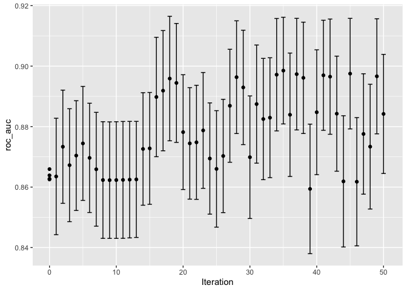

```r
autoplot(svm_sa, type = "performance")
```

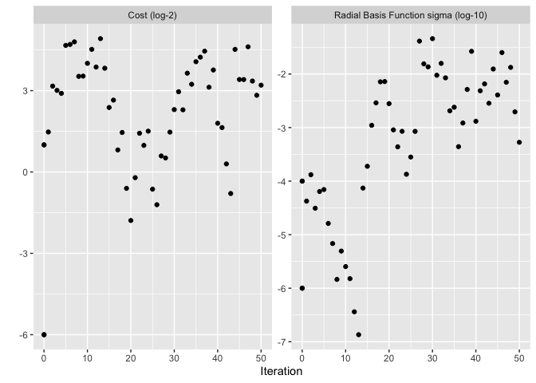

```r
autoplot(svm_sa, type = "parameters")
```